[OHI Science](http://ohi-science.org) | [Citation policy](http://ohi-science.org/citation-policy/)

# Ocean Health Index 2023: Methods

Compiled on Thu Aug 29 15:23:55 2024.

# 1 Return to [main website](https://oceanhealthindex.org)

# 2 Introduction

The global Ocean Health Index assesses ocean health for 220 coastal countries and territories and has been conducted every year starting in 2012. The Index describes how well we are sustainably managing 10 goals for ocean ecosystems which represent the full suite of benefits that people want and need from the ocean. These goals include: artisanal fishing opportunity, biodiversity, carbon storage, clean waters, coastal livelihoods and economies, coastal protection, food provision, natural products, sense of place, and tourism and recreation. Each goal is given a score ranging from 0 to 100, and the full suite of goal scores are then averaged to obtain an overall index score for each region.

For more information about the philosophy of the Ocean Health Index and model development see Halpern et al. (2012, 2015) and http://ohi-science.org/ohi-global/, which includes information about downloading global ocean health data.

# 3 Theory of OHI

## 3.1 A comprehensive framework to assess ocean health

The Ocean Health Index assesses ocean health which we define as how well we are sustainably managing the resources that we want and need from the ocean (e.g., tourism and recreation, food provisioning).

The OHI is considered a *composite indicator* because it combines many indicators into a comprehensive framework describing ocean health. This is in contrast to focusing on individual indicators, such as phosphate levels, sedimentation, biodiversity, etc. Individual indicators are important, but they provide limited information when it comes to evaluating how well an overall ecosystem is functioning. Another shortcoming of individual indicators is that they do not directly describe what we actually care about, and consequently, focusing on them can hinder communication. For example, most people do not directly care about nutrient pollution, however, we do care about its effects on the ocean’s ability to provide recreation and food.

Without an overall framework to evaluate indicators, certain indicators may be overemphasized relative to their true importance due to researcher bias (most researchers believe their area of study is the most important), trends in research (what is currently considered a hot topic and is funded), and availability of data (e.g., some data is easier to collect). A model that combines multiple indicators will inevitably have flaws, but at least we know which variables are included and how they are weighted.

## 3.2 The role of humans

One of the primary contributions of the OHI is that it recognizes people are an important part of the marine system. Both conservation and extractive use of ocean resources are valued, and consequently, scores are highest when we maximize the benefits we receive while maintaining sustainability so we can continue to receive benefits now and into the future. One temptation of indicator development is to focus only on the pressures that humans apply to systems. This makes sense because we want to be sure we are adequately protecting resources. However, eliminating all pressures on the ocean would require eliminating all contact between humans and the ocean. Beyond being unrealistic, this is undesirable because we would stop receiving all the benefits that we rely on from the ocean. The OHI is unique because it tracks both the pressures we put on oceans as well as the benefits we receive.

## 3.3 Yearly assessments

The global Ocean Health Index has been assessed every year since 2012. The primary goal of each yearly assessment is to calculate a new year of scores using the most recent data. Often, in addition to incorporating an additional year of data, we make improvements to models or decide to use different data sources. To ensure that scores for all years are comparable, we recalculate scores for previous scenario years for each assessment using new methods and data sources. For the current assessment, for example, in addition to calculating the current year’s scores, we recalculate scores for every year since 2012. Consequently, comparisons among years should always be performed using data from the same assessment year so trends in scores reflect changes to ocean health rather than changes to methods.

Not all data layers are reported through the most current assessment year, and consequently, the OHI scores are calculated using the most recent year of available data. Details on which years are used for each data layer are provided in Table 7.2.

## 3.4 Brief anatomy of scores

We define ocean health as the sustainable delivery of ten widely-held public goals for ocean ecosystems (Table 2.1). These goals represent the full suite of benefits that people want and need from the ocean, including the traditional ‘goods and services’ people often consider (e.g., fish to eat, coastal protection from nearshore habitats) as well as benefits less commonly accounted for, such as cultural values and biodiversity. Within each region, scores, ranging from 0 to 100, are calculated for the 10 goals (section 5.2). Four of the goals are calculated from 2 subgoals. The subgoals are calculated independently (i.e., they are treated as if they are goals) and then combined into the goal status score (Table 2.2).

**Table 2.1. The 10 goals of the Ocean Health Index**

| Goal | Abbreviation | Description |
| --- | --- | --- |
| Artisanal Fishing Opportunity | AO | The opportunity for small-scale fishers to supply catch for their families, members of their local communities, or sell in local markets |
| Biodiversity | BD | The conservation status of native marine species and key habitats that serve as a proxy for the suite of species that depend upon them |
| Carbon Storage | CS | The condition of coastal habitats that store and sequester atmospheric carbon |
| Clean Waters | CW | The degree to which ocean regions are free of contaminants such as chemicals, eutrophication, harmful algal blooms, disease pathogens, and trash |
| Coastal Livelihoods and Economies | LE | Coastal and ocean-dependent livelihoods (job quantity and quality) and economies (revenues) produced by marine sectors |
| Coastal Protection | CP | The amount of protection provided by marine and coastal habitats serving as natural buffers against incoming waves |
| Food Provision | FP | The sustainable harvest of seafood from wild-caught fisheries and mariculture |
| Natural Products | NP | The natural resources that are sustainably extracted from living marine resources |
| Sense of Place | SP | The conservation status of iconic species (e.g., salmon, whales) and geographic locations that contribute to cultural identity |
| Tourism and Recreation | TR | The value people have for experiencing and enjoying coastal areas through activities such as sailing, recreational fishing, beach-going, and bird watching |

**Table 2.2. Subgoals used to calculate 4 of the Ocean Health Index goals**

| Subgoal | Goal | Abbreviation | Description |
| --- | --- | --- | --- |
| Habitat | Biodiversity | HAB | The status of key habitats that serve as a proxy for the suite of species that depend upon them |
| Species condition | Biodiversity | SPP | The conservation status of native marine species |
| Livelihoods | Coastal livelihoods and economies | LIV | Coastal and ocean-dependent livelihoods (job quantity and quality) produced by marine sectors |
| Economies | Coastal livelihoods and economies | ECO | Coastal and ocean-dependent economies (revenues) produced by marine sectors |
| Fisheries | Food provision | FIS | The sustainable harvest of seafood from wild-caught fisheries |
| Mariculture | Food provision | MAR | The sustainable harvest of seafood from mariculture practices |
| Iconic species | Sense of place | ICO | The conservation status of iconic species (e.g., salmon, whales) that contribute to cultural identity |
| Lasting special places | Sense of place | LSP | The conservation status of geographic locations that contribute to cultural identity |

Goal (and subgoal scores) are calculated using several variables (referred to as “dimensions”, Table 2.3). Goal scores (Section 5.2) are calculated as the average of current status (Section 5) and likely future status. Likely future status (Section 5.3) is the current status modified by variables (resilience, pressures, and trend) expected to influence future status.

**Table 2.3. Dimension used to calculate an OHI goal score** Goal scores are the average of current and likely future status. Likely future status adjusts current status scores based on pressures and resilience variables acting on the goal as well as recent trends in status.

[output not shown]

**Figure 2.1. Relationship between OHI dimensions and scores** This figure describes how the dimensions come together to calculate a goal score. This figure represents equations 4.3 and 4.5.

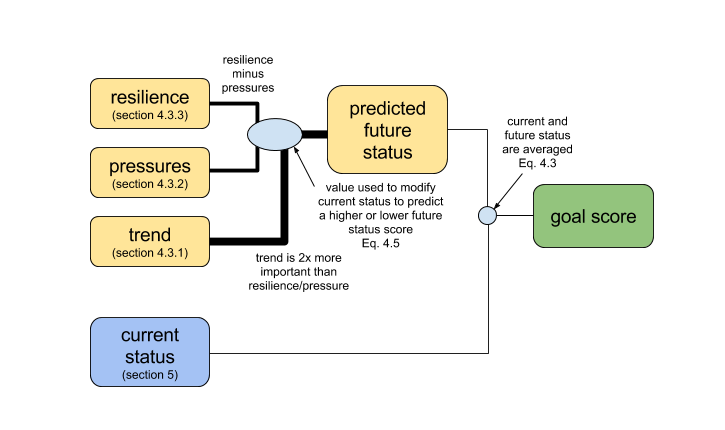

Finally, an overall Index score for each region is calculated by averaging the goal scores (Figure 2.2).

**Figure 2.2. Example flowerplot of goal scores for a region** Goal and subgoal scores for Canada. The middle value is the regional Index score, and is calculated by averaging the goal scores.

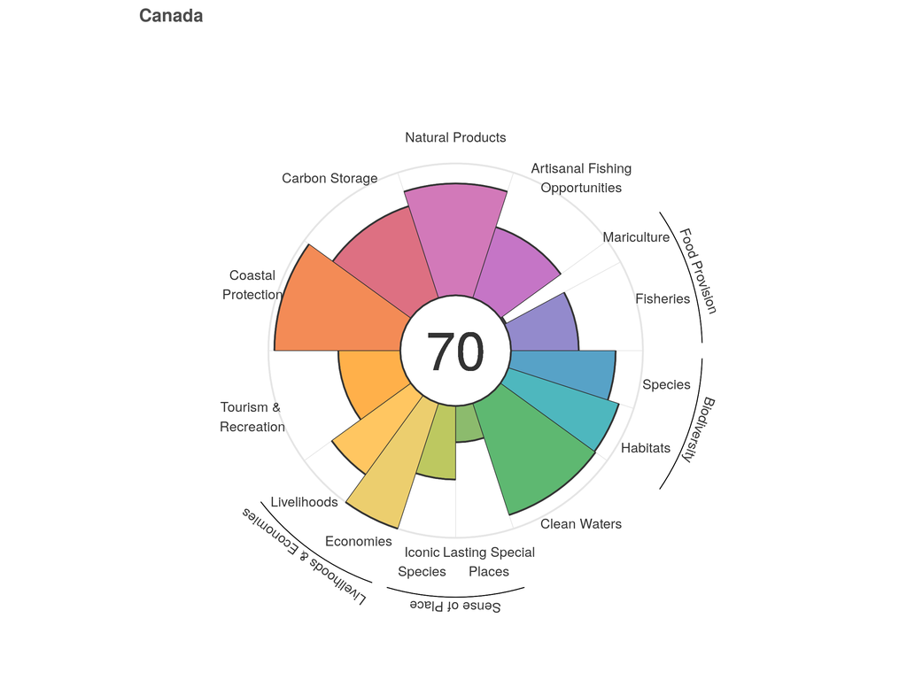

# 4 Selecting data and missing data

Ideally, regional and local assessments should use the best available data, but this decision limits the ability to compare across scales. For direct comparisons among locations to be valid, they must use consistent data. For this reason, we focused on using global datasets so differences in Index scores across regions are driven by differences in ocean health rather than variation in the data. Although, in reality, many global datasets are compilations of local or regional datasets and their quality varies spatially. In some cases, data for a particular component or dimension of a goal were available for most, but not all, countries. Gaps in these data were known to not be true zero values. Rather than exclude these data layers, we employed several different methods to fill these data gaps (Frazier *et al.* 2016).

These guidelines both motivated and constrained our methods. The development of the model frameworks for each goal (including reference points) was heavily dictated by the availability of global datasets. And, ultimately, several key elements related to ocean health could not be included due to lack of existing or appropriate global datasets. As new and better data become available in the future, details of how goals or dimensions are modeled will likely change, although the framework we have developed can accommodate these changes.

For Index scores to be comparable, every region must have a value for each data layer included in the analysis, unless it is known to not be relevant to a region. In other words, missing data are not acceptable (Burgass *et al.* 2017). Adhering to this criterion is critical to avoid influencing the Index score simply because of inclusion (or absence) of a particular data layer for any reporting region.

Gaps in data are common; many developing countries lack the resources to gather detailed datasets, and even developed, data-rich countries have inevitable data gaps. We use a variety of methods to estimate missing data, including: averages of closely related groups (e.g., regions sharing ecological, spatial, political attributes; taxonomic groups; etc.), spatial or temporal interpolation (e.g., raster or time-series data), and predictive models (e.g., regression analysis, machine learning, etc.). Gapfilling is a major source of uncertainty, especially for certain goals and regions. Given how common gaps in data are, clear documentation of gapfilling is a critical step of index development because it provides a measure of the reliability of index scores.

One of the ongoing goals of the Ocean Health Index (OHI) has been to improve our approach to dealing with missing data, by quantifying the potential influence of gapfilled data on index scores, and developing effective methods of tracking, quantifying, and communicating this information (Frazier *et al.* 2016).

# 5 Regions

There are 220 global coastal countries and territorial regions (Table 4.1). Regions are based on EEZ boundaries. However, we aggregate some EEZ regions to the level of country (e.g., Hawaii is estimated as part of the larger U.S.). We have also modified some boundaries (Halpern *et al.* 2012; Halpern *et al.* 2015b). We do not estimate OHI values for disputed or unclaimed areas.

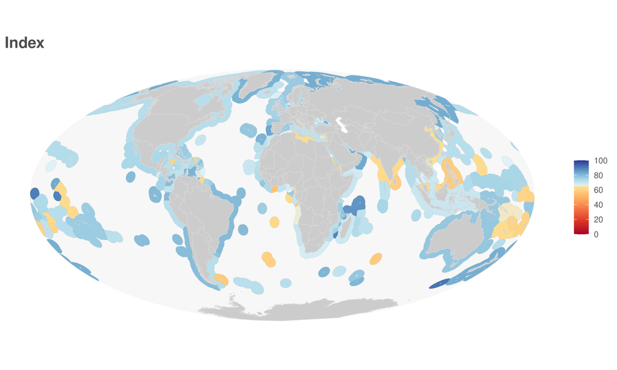

**Table 4.1. Global regions**

| region | region ID | ISO code | type | administrative country |
| --- | --- | --- | --- | --- |
| Albania | 82 | ALB | country |  |
| Algeria | 84 | DZA | country |  |
| American Samoa | 151 | ASM | territory | United States |
| Amsterdam Island and Saint Paul Island | 92 | ATF | territory | France |
| Andaman and Nicobar | 26 | IND | territory | India |
| Angola | 200 | AGO | country |  |
| Anguilla | 118 | AIA | territory | United Kingdom |
| Antigua and Barbuda | 120 | ATG | country |  |
| Argentina | 172 | ARG | country |  |
| Aruba | 250 | AW | territory | Netherlands |
| Ascension | 85 | ASC | territory | United Kingdom |
| Australia | 16 | AUS | country |  |
| Azores | 55 | PRT | territory | Portugal |
| Bahamas | 110 | BHS | country |  |
| Bahrain | 52 | BHR | country |  |
| Bangladesh | 204 | BGD | country |  |
| Barbados | 124 | BRB | country |  |
| Bassas da India | 34 | ATF | territory | France |
| Belgium | 59 | BEL | country |  |
| Belize | 164 | BLZ | country |  |
| Benin | 99 | BEN | country |  |
| Bermuda | 108 | BMU | territory | United Kingdom |
| Bonaire | 245 | BQ | territory | Netherlands |
| Bosnia and Herzegovina | 232 | BIH | country |  |
| Bouvet Island | 105 | BVT | territory | Norway |
| Brazil | 171 | BRA | country |  |
| British Indian Ocean Territory | 38 | IOT | territory | United Kingdom |
| British Virgin Islands | 117 | VGB | territory | United Kingdom |
| Brunei | 247 | BRN | country |  |
| Bulgaria | 71 | BGR | country |  |

[output cut: 190 more lines]

# 6 Models

## 6.1 Regional and global Index scores

The overall index score for each region ($I_{region}$) is calculated as a weighted average of all the scores ($G$), for each goal ($g$) such that:

$${ I_{region} }\quad =\quad \frac { \displaystyle\sum_{ g=1 }^{ N }{ { w
}_{ g }{ G }_{ g } } }{ \displaystyle\sum _{ g=1 }^{ N }{ { w }_{ g }
} }, (Eq. 5.1)$$

where, $w_{g}$ is the weight for each goal.

For the global assessment, the goal weights ($w_{g}$) were assumed to be equal, even though we know this assumption does not hold for most individuals or across individuals within communities. Ideally these weights would be derived empirically, but such an effort would require surveying a full spectrum of people from every single country. This was beyond the scope of this project, but may be possible in a future application of the Index.

In many places certain goals are not relevant, for example, production-focused goals typically do not apply to uninhabited islands, and the coastal protection or carbon storage goals will not apply to regions without the relevant coastal ecosystems.

The overall global index score ($I_{global}$) is calculated as the area weighted average of the index scores ($I_{region}$) for each region ($i$):

$${ I }_{ global }\quad =\quad \frac { \displaystyle\sum _{ i=1 }^{ N }{ {
a }_{ i }{ I }_{ region,i } } }{ \displaystyle\sum _{ i=1 }^{ N }{ { a
}_{ i } } }, (Eq. 5.2)$$

where, $a_{i}$ is each region’s ocean area, based on the EEZ area.

## 6.2 Goal scores

Each goal score is the average of its current status and likely future status (Figure 5.1, see section *5: Goal models and data* for methods used to calculate status of each goal). The Index assesses the current status of each goal relative to a reference point. Likely future status is estimated using: recent trends in current status; pressures that can stress the system and threaten future delivery of benefits; and resilience to such pressures, due to governance, institutional and ecological factors.

**Figure 5.1. Pie chart describing the contribution of each dimension to the goal score**

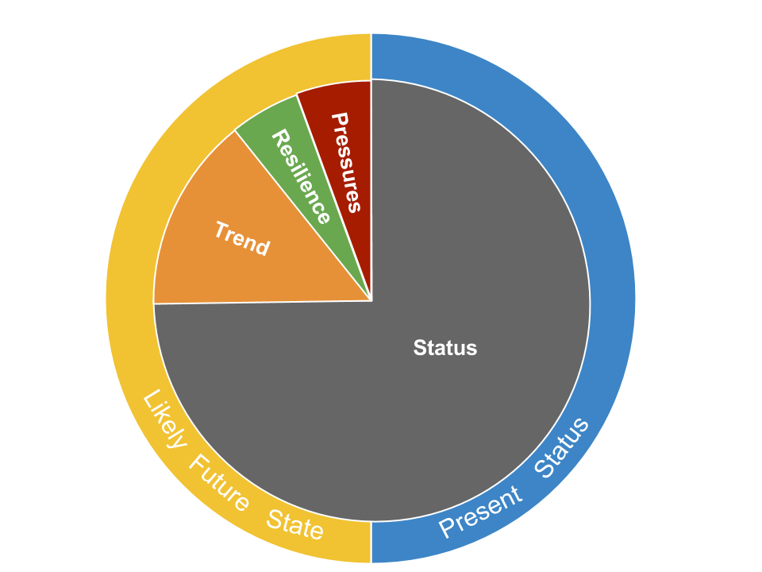

Each goal score, $G$, is the average of its present status, $x$, and its likely near-term future status, $\hat x_{F}$:

$$G \quad =\quad \frac {x \quad +\quad \hat x_{F} }{ 2 }, (Eq. 5.3)$$

The present status of goal, $x$, is its present state, $X$, relative to a reference point, $X_{R}$, uniquely chosen for each goal:

$${ x }_{ i }\quad =\quad \frac { X }{ X_{R} }, (Eq. 5.4)$$

The reference point, $X_{R}$, can be determined mechanistically using a production function (e.g., maximum sustainable yield, MSY, for fisheries), spatially by means of comparison with another region (e.g., country X represents the best possible known case), temporally using a past benchmark (e.g., historical habitat extent), or in some cases via known (e.g., zero pollution) or established (e.g., 30% of waters set aside in MPAs) targets. Past benchmarks can either be a fixed point in time or a moving target (e.g., five years prior to most current data). The type of reference point can have important implications for interpretations of how a goal is doing in any given country.

For each region, the estimate of a goal’s likely near-term future status is a function of its present status, $x$ modified by: recent trends, $T$, in status; current cumulative pressures, $p$, acting on the goal; and social and ecological resilience, $r$, to pressures given the governance and social institutions in place to protect or regulate the system and the ecological condition of the system:

$$\hat {x} _{F} \quad = \quad \left[ 1 \quad + \quad \beta T \quad + \quad
\left( 1\quad -\quad \beta \right) \left( r \quad - \quad p
\right) \right] x, (Eq. 5.5)$$

where, $\beta$ represents the relative importance of the trend versus the resilience and pressure terms in determining the likely trajectory of the goal status into the future. We assume $\beta = 0.67$, which makes trend twice as important as the pressure/resilience component. We chose this value because we believe the direct measure of trend is a better indicator of future (i.e., in five years) condition than indirect measures of pressure and resilience.

The role of the resilience and pressure dimensions is to improve our understanding of the likely near-term future condition by incorporating additional information beyond that provided by the recent trend. Pressure or resilience measures that were in existence in the past may have a cumulative effect that has not yet manifested itself in trend (e.g., fishing pressure may have increasingly negative impacts as successive year classes of fish become increasingly less abundant; resilience due to establishment of a marine protected area (MPA) may require a number of years before its benefits become apparent). In addition, the recent trend does not capture the effect of current levels of resilience and pressures. The expectation of a likely future condition suggested by the trend will become more or less optimistic depending on the resilience and pressure dimensions. If the effects are equal they cancel each other out.

Both resilience and pressure dimensions are scaled from 0 to 1, and trend is constrained to -1.0 ≤ $T$ ≤ 1.0 (i.e., values outside this range are clamped to range end values).

The likely future status cannot exceed the maximum possible value of the status for each goal, which is 1.0. In reality data are rarely perfect, creating potential situations where likely future condition exceeds 1.0. To address these cases, we implemented two rules. First, if current status = 1.0, then trend is set = 0.0, since any trend > 0.0 in those cases must be due to incomplete or imperfect data. Second, status and likely future status scores were constrained to maximum value of 1.

## 6.3 Likely future status dimensions

Three dimensions are used to calculate likely future status: trends, pressure, and resilience. This section describes the calculations underlying these three dimensions.

### 6.3.1 Trend

Trend is the proportional change in status predicted to occur in 5 years, based on recent status data. In most cases, this is calculated by estimating the yearly change in status using a linear regression model (i.e., slope estimate) of the five most recent years of status data and multiplying this value by 5 to estimate the change five years into the future. To determine proportional change, we divide the slope estimate by the status value of the earliest year of data used in the trend calculation.

In OHI assessments prior to 2016, we calculated trend as the *absolute* change in status predicted to occur in 5 years. In 2016, we began calculating the *proportional* change by dividing the slope estimate by the status of the earliest year used in the trend calculation. Although this change rarely had a large effect on trend, or ultimate score values, this method is more consistent with how trend data is incorporated into the likely future status model (Eq. 4.5). If the $\beta$, pressure ($p$), and resilience ($r$) components of the likely future status model are ignored (this assumes the pressure and resilience components fully cancel each other out), the equation becomes:

$x(1 + trend)$,

where, $x$ is the current status. Given this, if $x=50$, and we expect trend to increase by 10% over 5 years, then likely future status would be: $50(1 + 0.10) = 55$.

Trends indicate proportional change in status, so they typically range from -100% to +100% (or, -1.0 to +1.0), therefore we constrained values to this range.

For all goals we included the trend estimate, even if the linear model was not statistically significant (i.e., P<0.05). We chose to include these values for two key reasons: 1) we were not trying to predict the future but instead only indicate likely condition. 2) in nearly all cases we did not have sufficient data to conduct more rigorous trend analyses.

In some cases, we were not able to estimate trend using status data due to data limitations. In these cases, we used alternative methods to estimate trend. Specific details about trend calculations for each goal are provided in section 5.

We recognize several possible shortcomings in using past trends to estimate likely future status. We assume a simple linear trend, but this is not always the case due to a variety of variables such as altered pressures and resilience responses, nonlinear patterns in system response, stochastic environmental and biological variability, and simple bounding conditions (status cannot go below zero or above 1.0, and so the trend must level off as it approaches these values). Also, it is important to note that the same trend value could reflect many different processes. For example, declines due to unsustainable harvest of a resource can look identical to declines due to restrictions placed on resource users to allow the resource to recover. It also may be too short a time frame to determine true trends or the causes of those trends, but the intent here is more about informing the likely near-term trajectory.

### 6.3.2 Pressure

The pressure score, $p$, describes the cumulative pressures acting on a goal which suppress the goal score. Pressure scores range from 0 to 1, and they are calculated for each goal and region and include both ecological ($p_{E}$) and social pressures ($p_{S}$) (Table 5.1, Figure 5.2), such that:

$${ p }\quad =\quad \gamma *{ p }_{ E }\quad +\quad (1-\gamma )*{ p }_{ S
}, (Eq. 5.6)$$

where $\gamma$ is the relative weight for ecological vs. social pressures and equals 0.5 for the global assessment. At global scales, little evidence exists to support unequal weighting of ecological and social pressures for most goals; furthermore, unequal weighting would require unique values for each goal and there is currently no empirical work to guide such decisions. At local or regional scales there may be clear evidence for unequal weights per goal and $\gamma$ should be adjusted accordingly.

**Figure 5.2. Pressure components** Pressure is calculated using both social and ecological pressures. Ecological pressures include 5 subcategories (fishing pressure, habitat destruction, climate change, water pollution, and species/genetic introductions).

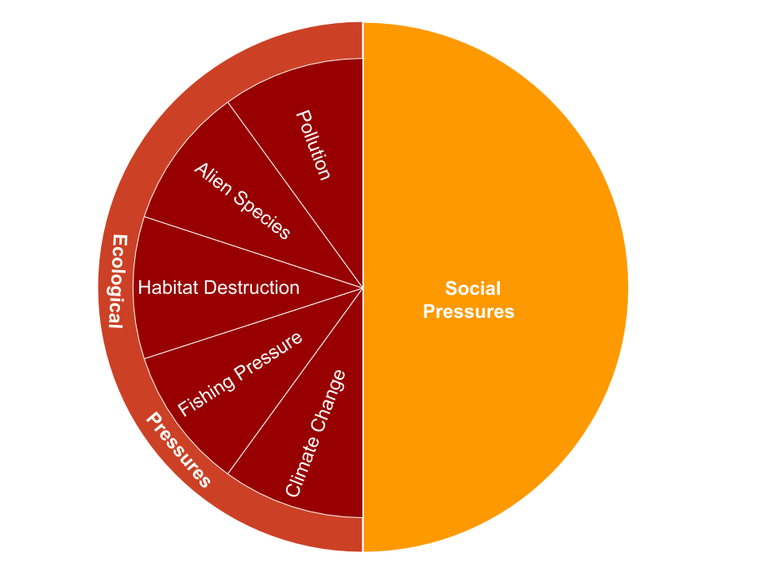

**Table 5.1. Pressure data and categories** Description of the stressor data layers used to calculate overall pressure for each goal and region for the global assessment (descriptions of pressure data in section 6). Each data layer is assigned to an ecological or social category, and ecological data are assigned to one of five subcategories.

| Data | Short name | Category | Subcategory | Description |
| --- | --- | --- | --- | --- |
| Chemical pollution | po_chemicals | ecological | pollution | Modeled chemical pollution within EEZ from commercial shipping traffic, ports and harbors, land-based pesticide use (organic pollution), and urban runoff (inorganic pollution) |
| Coastal chemical pollution | po_chemicals_3nm | ecological | pollution | Modeled chemical pollution within 3nm of coastline from commercial shipping traffic, ports and harbors, land-based pesticide use (organic pollution), and urban runoff (inorganic pollution) |
| Pathogen pollution | po_pathogens | ecological | pollution | Percent of population without access to improved sanitation facilities as a proxy for pathogen pollution |
| Nutrient pollution | po_nutrients | ecological | pollution | Modeled nutrient pollution within EEZ based on crop fertilizer and manure consumption |
| Coastal nutrient pollution | po_nutrients_3nm | ecological | pollution | Modeled nutrient pollution within 3nm based on crop fertilizer and manure consumption |
| Marine plastics | po_trash | ecological | pollution | Global marine plastic pollution |
| Nonindigenous species | sp_alien | ecological | alien species | Measure of harmful invasive species |
| Genetic escapes | sp_genetic | ecological | alien species | Introduced mariculture species (Mariculture Sustainability Index) as a proxy for genetic escapes |
| Subtidal soft bottom habitat destruction | hd_subtidal_sb | ecological | habitat destruction | Pressure on soft-bottom habitats due to demersal destructive commercial fishing practices (e.g., trawling) |
| Subtidal hardbottom habitat destruction | hd_subtidal_hb | ecological | habitat destruction | Presence of blast fishing as an estimate of subtidal hard bottom habitat destruction |
| Intertidal habitat destruction | hd_intertidal | ecological | habitat destruction | Coastal population density (25 mi from shore) as a proxy for intertidal habitat destruction |
| Coral harvest pressure | hd_coral | ecological | habitat destruction | Pressure on coral due to harvesting as a natural product |
| High bycatch due to commercial fishing | fp_com_hb | ecological | fishing pressure | Pressure due to industrial high bycatch fishing identified by discard tonnes and standardized by NPP |
| Low bycatch due to commercial fishing | fp_com_lb | ecological | fishing pressure | Pressure due to industrial low bycatch fishing identified by reported and IUU tonnes and standardized by NPP |
| Low bycatch due to artisanal fishing | fp_art_lb | ecological | fishing pressure | Pressure due to artisanal low bycatch fishing identified by reported and IUU tonnes and standardized by NPP |
| High bycatch due to artisanal fishing | fp_art_hb | ecological | fishing pressure | Pressure due to artisanal high bycatch fishing identified by discard tonnes and standardized by NPP |
| Targeted harvest of cetaceans and marine turtles | fp_targetharvest | ecological | fishing pressure | Targeted harvest of cetaceans and marine turtles |
| Sea surface temperature | cc_sst | ecological | climate change | Presure due to increasing extreme sea surface temperature events |
| Ocean acidification | cc_acid | ecological | climate change | Pressure due to increasing ocean acidification, scaled using biological thresholds |
| UV radiation | cc_uv | ecological | climate change | Pressure due to increasing frequency of UV anomolies |
| Sea level rise | cc_slr | ecological | climate change | Pressure due to rising mean sea level |
| Weakness of governance | ss_wgi | social | social | Inverse of World Governance Indicators (WGI) six combined scores |
| Weakness of social progress | ss_spi | social | social | Inverse of Social Progress Index scores |

#### 6.3.2.1 Ecological pressure

We assessed five broad, globally-relevant categories of ecological stressors: fishing pressure, habitat destruction, climate change (including ocean acidification), water pollution, and species introductions (invasive species and genetic escapes). The five categories are intended to capture known pressures to the social-ecological system associated with each goal. Each pressure category may include several stressors. The intensity of each stressor within each OHI region is scaled from 0 to 1, with 1 indicating the highest stress (e.g., example of one of these data layers is [sea surface temperature](https://github.com/OHI-Science/ohi-global/blob/draft/eez/layers/cc_sst.csv)).

We determined the rank sensitivity of each goal/subgoal to each stressor (or, when possible, an element of the goal, such as a specific habitat). We ranked ecological pressures as having ‘high’ (score = 3), ‘medium’ (score = 2), ‘low’ (score = 1), or ‘no’ (score = NA) impact (Table 5.2). Wherever possible we relied on peer-reviewed literature to establish these rankings, and relied on our collective expert judgment in cases with no available literature (Table S28 in Halpern et al. 2012). The pressure ranks are based on a rough estimate of the global average intensity and frequency of the stressor. We recognize that this will create over- and under-estimates for different places around the planet, but to address such variance in a meaningful way would require a separate weighting matrix for every single region on the planet, which is not feasible at this time.

**Table 5.2. Pressure matrix** Rank sensitivity of each goal (or, goal element) to each stressor.

| goal | element | cc_acid | cc_slr | cc_sst | cc_uv | fp_art_hb | fp_art_lb | fp_com_hb | fp_com_lb | fp_targetharvest | hd_coral | hd_intertidal | hd_subtidal_hb | hd_subtidal_sb | po_chemicals | po_chemicals_3nm | po_nutrients | po_nutrients_3nm | po_pathogens | po_trash | sp_alien | sp_genetic | ss_spi | ss_wgi |
| --- | --- | --- | --- | --- | --- | --- | --- | --- | --- | --- | --- | --- | --- | --- | --- | --- | --- | --- | --- | --- | --- | --- | --- | --- |
| AO |  |  |  |  |  | 3 |  | 2 | 1 |  |  | 1 | 3 | 1 |  | 1 |  | 1 |  |  | 1 |  | 1 | 1 |
| CP | coral | 1 | 2 | 3 | 1 |  |  |  |  |  | 1 |  | 3 |  |  | 1 |  | 2 |  |  | 1 |  | 1 | 1 |
| CP | kelp | 1 |  | 2 |  |  |  |  |  |  |  | 3 |  |  |  | 2 |  | 3 |  |  | 1 |  | 1 | 1 |
| CP | mangrove |  | 1 |  |  |  |  |  |  |  |  | 3 |  |  |  | 1 |  | 1 |  |  |  |  | 1 | 1 |
| CP | saltmarsh |  | 2 |  |  |  |  |  |  |  |  | 3 |  |  |  | 1 |  | 2 |  |  | 1 |  | 1 | 1 |
| CP | seagrass | 1 | 2 | 2 |  |  |  |  |  |  |  | 3 |  |  |  | 2 |  | 3 |  |  | 1 |  | 1 | 1 |
| CP | seaice shoreline |  | 2 | 3 |  |  |  |  |  |  |  |  |  |  |  |  |  |  |  |  |  |  | 1 | 1 |
| CS | mangrove |  | 1 |  |  |  |  |  |  |  |  | 3 |  |  |  | 1 |  | 1 |  |  |  |  | 1 | 1 |
| CS | saltmarsh |  | 2 |  |  |  |  |  |  |  |  | 3 |  |  |  | 1 |  | 2 |  |  | 1 |  | 1 | 1 |
| CS | seagrass | 1 | 2 | 2 |  |  |  |  |  |  |  | 3 |  |  |  | 2 |  | 3 |  |  | 1 |  | 1 | 1 |
| CS | tidal flat |  | 2 | 2 |  |  |  |  |  |  |  | 3 |  |  |  | 2 |  | 2 |  |  | 1 |  | 1 | 1 |
| CW |  |  |  |  |  |  |  |  |  |  |  |  |  |  |  | 3 |  | 3 | 3 | 3 |  |  | 1 | 1 |
| ECO | Aquarium Trade Fishing | 1 |  | 1 |  | 3 | 1 |  |  |  |  |  | 3 |  | 2 |  | 1 |  |  |  | 1 |  | 1 | 1 |
| ECO | Commercial Fishing |  |  |  |  | 2 | 1 | 3 | 1 |  |  | 1 | 2 | 2 | 2 |  | 1 |  |  |  | 1 | 1 | 1 | 1 |
| ECO | Mariculture |  | 1 |  |  |  |  |  |  |  |  |  |  |  | 2 |  |  | 3 |  |  |  |  | 1 | 1 |
| ECO | Marine Mammal Watching |  |  |  |  |  |  | 1 |  |  |  |  |  |  |  |  |  |  |  | 1 |  |  | 1 | 1 |
| ECO | Tourism |  | 2 |  |  |  |  |  |  |  |  |  |  |  | 3 |  |  | 3 | 3 | 3 |  |  | 1 | 1 |
| ECO | Wave & Tidal Energy |  | 1 |  |  |  |  |  |  |  |  |  |  |  |  |  |  |  |  |  |  |  | 1 | 1 |
| FIS |  |  |  |  |  | 2 | 1 | 3 | 1 |  |  | 1 | 2 | 2 | 1 |  | 1 |  |  |  | 1 | 1 | 1 | 1 |
| HAB | coral | 1 | 2 | 3 | 1 | 3 |  |  |  |  | 1 |  | 3 |  |  | 1 |  | 2 |  |  | 1 |  | 1 | 1 |
| HAB | kelp | 1 |  | 2 |  |  |  |  |  |  |  | 2 |  |  |  | 2 |  | 3 |  |  | 1 |  | 1 | 1 |
| HAB | mangrove |  | 1 |  |  |  |  |  |  |  |  | 3 |  |  |  | 1 |  | 1 |  |  |  |  | 1 | 1 |
| HAB | saltmarsh |  | 2 |  |  |  |  |  |  |  |  | 3 |  |  |  | 1 |  | 2 |  |  | 1 |  | 1 | 1 |
| HAB | seagrass | 1 | 2 | 2 |  |  |  |  |  |  |  | 3 |  |  |  | 2 |  | 3 |  |  | 1 |  | 1 | 1 |
| HAB | seaice edge |  | 1 | 3 |  |  |  |  |  |  |  |  |  |  |  |  |  |  |  |  |  |  | 1 | 1 |
| HAB | soft bottom |  |  |  |  |  | 1 | 3 | 1 |  |  |  |  | 3 |  | 2 |  | 2 |  |  | 1 |  | 1 | 1 |
| HAB | tidal flat |  | 2 | 2 |  |  |  |  |  |  |  | 3 |  |  |  | 2 |  | 2 |  |  | 1 |  | 1 | 1 |
| ICO |  | 1 |  | 1 |  | 2 |  | 2 |  | 2 |  | 3 | 2 |  |  | 3 |  | 1 |  | 1 | 1 |  | 1 | 1 |
| LIV | Commercial Fishing |  |  |  |  | 2 | 1 | 3 | 1 |  |  | 1 | 2 | 2 | 2 |  | 1 |  |  |  | 1 | 1 | 1 | 1 |
| LIV | Mariculture |  | 1 |  |  |  |  |  |  |  |  |  |  |  | 2 |  |  | 3 |  |  |  |  | 1 | 1 |
| LIV | Marine Mammal Watching |  |  |  |  |  |  | 1 |  |  |  |  |  |  |  |  |  |  |  | 1 |  |  | 1 | 1 |
| LIV | Ports & Harbors |  | 2 |  |  |  |  |  |  |  |  |  |  |  |  |  |  |  |  |  | 1 |  | 1 | 1 |
| LIV | Ship & Boat Building |  |  |  |  |  |  |  |  |  |  |  |  |  |  |  |  |  |  |  |  |  | 1 | 1 |
| LIV | Tourism |  | 2 |  |  |  |  |  |  |  |  |  |  |  | 3 |  |  | 3 | 3 | 3 |  |  | 1 | 1 |
| LIV | Transportation & Shipping |  |  |  |  |  |  |  |  |  |  |  |  |  |  |  |  |  |  |  | 1 |  | 1 | 1 |
| LIV | Wave & Tidal Energy |  | 1 |  |  |  |  |  |  |  |  |  |  |  |  |  |  |  |  |  |  |  | 1 | 1 |
| LSP |  |  | 1 |  |  |  |  |  |  |  |  | 3 | 2 |  |  | 2 |  | 2 |  | 3 | 1 |  | 1 | 1 |
| MAR |  |  | 1 |  |  |  |  |  |  |  |  |  |  |  | 2 |  |  | 3 |  |  |  |  | 1 | 1 |
| NP | fish oil |  |  | 1 |  |  |  |  | 2 |  |  |  |  | 2 | 2 |  | 1 |  |  |  | 1 |  | 1 | 1 |
| NP | ornamentals |  |  | 1 |  | 3 | 1 |  |  |  |  |  | 3 |  | 2 |  | 1 |  |  |  | 1 |  | 1 | 1 |
| NP | seaweeds |  |  | 1 |  |  |  |  |  |  |  | 1 |  |  | 2 |  | 2 |  |  |  | 1 |  | 1 | 1 |
| SPP |  | 1 |  | 1 | 1 | 2 | 1 | 3 | 1 | 1 |  | 2 | 2 | 3 | 2 |  | 3 |  |  | 1 | 1 | 1 | 1 | 1 |
| TR |  |  | 2 |  |  |  |  |  |  |  |  |  |  |  |  | 3 |  | 3 | 3 | 3 |  |  | 1 | 1 |

To estimate the cumulative effect of the ecological pressures, $P_E$, we first determined the cumulative pressure, $p$, within each ecological category, $i$ (e.g., pollution, fishing, etc.):

$${ p }_{ i }\quad =\quad \frac { \displaystyle\sum _{ i=1 }^{ N }{ { w
}_{ i }{ s }_{ i } } }{ 3 }, (Eq. 5.7)$$

Where $w_i$ is the sensitivity ranks (Table 5.2) describing the relative sensitivity of each goal to each stressor, and $s_i$ is intensity of the stressor in each region on a scale of 0-1. We divided by the maximum weighted intensity that could be achieved by the worst stressor (max = 3.0).

If $p_i$ > 1.0, we set the value equal to 1.0. This formulation assumes that any cumulative pressure load greater than the maximum intensity of the worst stressor is equivalent to maximum stressor intensity.

For the goals for which sensitivity ranks were assigned for specific habitats or livelihood sectors (i.e., goal elements), we calculated the weighted sum of the pressures for only those habitats or sectors that were present in the country.

The overall ecological pressure, $p_E$, acting on each goal and region was calculated as the weighted-average of the pressure scores, $p$, for each category, $i$, with weights set as the maximum rank in each pressure category ($w_{i\_max}$) for each goal, such that:

$${ p }_{ E }\quad =\quad \frac { \displaystyle\sum _{ i=1 }^{ N }{ { (w
}_{ i\_ max }*{ p }_{ i }) } }{ \displaystyle\sum_{ i=1 }^{ N } { { w
}_{ i\_ max } } }, (Eq. 5.8)$$

Stressors that have no impact drop out rather than being assigned a rank of zero, which would affect the average score.

#### 6.3.2.2 Social pressures

Social pressures describe the lack of effectiveness of government and social institutions. Social stressors are described for each region on a scale of 0 to 1 (with one indicating the highest pressure). Social pressure is then calculated as the average of the social stressors:

$${ p }_{ S }\quad =\quad \frac { \displaystyle\sum _{ i=1 }^{ N }{ z_{ i
} } }{ N }, (Eq. 5.9)$$

where $z_{i}$ are the social pressure measures specific to the goal. Unequal weighting may be appropriate in some cases but is difficult to assess currently, particularly at the global scale.

#### 6.3.2.3 Caveats

There were a number of ecological pressures not included in our assessment, including altered sediment regimes, noise and light pollution, toxic chemicals from point sources, nutrient pollution from atmospheric deposition and land-based sources other than fertilizer application to agricultural land. In all cases, global data do not exist in a format that would allow for adequate comparisons within and among countries. Future global or regional iterations of the Index could include these data as they become available.

The calculation of ecological pressures is sensitive to the number of stressors within each category (but not to the number of categories). Inclusion of additional stressors within categories would require careful calibration of ranks so that the cumulative effect of a larger number of stressors does not overestimate pressure.

A key assumption in our assessment of ecological pressures is that each goal has a linear and additive response to increases in intensity of the stressors. Clearly many ecosystems respond non-linearly to increased stressor intensity, exhibiting threshold responses, and there are likely nonlinear interactions among stressors. Unfortunately little is known about the nature of these types of nonlinearities and interactions so we could not include them in any meaningful way.

### 6.3.3 Resilience

To calculate resilience for each goal and region, $r$, we assess three resilience categories (Table 5.3, Figure 5.3): ecological integrity, $Y_{E}$, regulatory efforts that address ecological pressures, $Y_R$, and social integrity, $Y_{S}$. The first two measures address ecological resilience while the third addresses social resilience. When all three aspects are relevant to a goal, resilience is calculated as:

$$r\quad =\quad \gamma *(\frac { { Y }_{ E }+ {Y}_{R} }{ 2 } )+(1-\gamma
)*{ Y }_{ S }, (Eq. 5.10)$$

We chose $\gamma = 0.5$ so the weight of resilience components that address ecological systems (ecosystem and regulatory) vs. social systems would be equivalent to the proportions used in the model to calculate pressure. Resilience indicators are intended to directly address, as much as possible, specific pressures. Consequently, within a pressure category, resilience scores should not exceed pressure scores, otherwise likely future status scores will be inflated. For the 2021 OHI assessment, in a significant modification from past OHI methods (Halpern *et al.* 2012), where total resilience scores were allowed to exceed total pressures scores, we have capped resilience such that it will not exceed the corresponding pressures, e.g., $(r−p) ≤ 0$ (i.e. $r≤p$), when calculating the likely future status for a given goal (O’Hara *et al.* 2020).

**Figure 5.3. Resilience components** Resilience includes both ecological and social resilience categories. Ecological resilience includes an ecosystem and regulatory category. The regulatory category includes 5 subcategories that mirror the pressure categories (fishing pressure, habitat destruction, climate change, water pollution, and species/genetic introductions) as well as a goal-specific category.

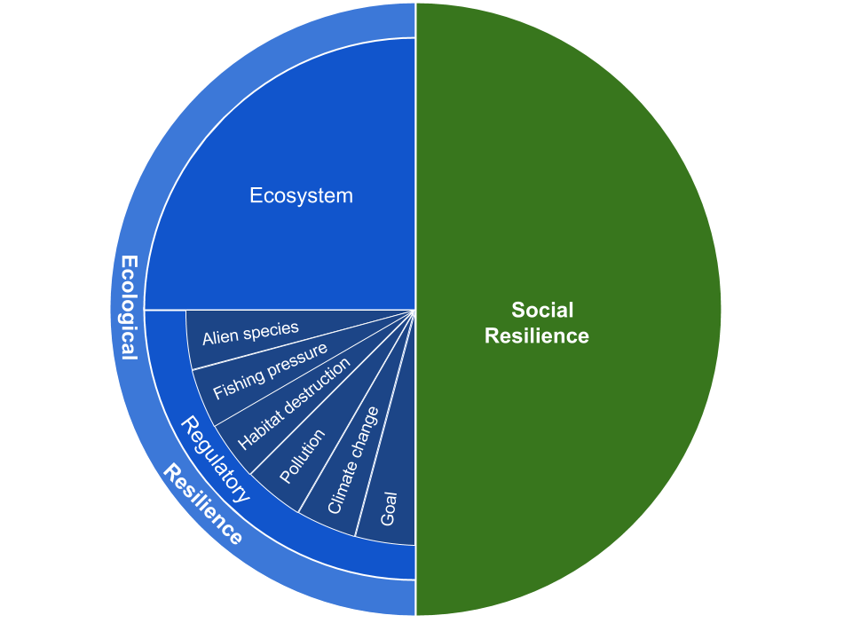

Each resilience category is composed of 1 or more data layers (Table 5.3) with values scaled from 0-1, reflecting the magnitude of resilience, for each region (an example of one of these data layers describes [tourism regulations that preserve biodiversity](https://github.com/OHI-Science/ohi-global/blob/draft/eez/layers/g_tourism.csv)). Each resilience data layer is assigned a weight of 0.5 or 1 (Table 5.3) that is applied equally across all the goals (or, goal elements) influenced by the resilience layer (i.e., resilience matrix, Table 5.4). This information is used to calculate a score for each resilience category. The weight reflects information about governance.

**Table 5.3. Resilience categories and weights** The data layers used to calculate resilience for each goal and region for the global assessment (descriptions of data layers and sources are in section 6). Each data layer is assigned to an ecological or social category. The ecological category is broken into an ecosystem and regulatory category type.

| Data | Short name | Category | Category type | Subcategory | Weight |
| --- | --- | --- | --- | --- | --- |
| Measure of ecological integrity | species_diversity_eez | ecological | ecosystem | ecological | 1.0 |
| Measure of coastal ecological integrity | species_diversity_3nm | ecological | ecosystem | ecological | 1.0 |
| Management of nonindigenous species | sp_alien_species | ecological | regulatory | alien species | 1.0 |
| CITES signatories | g_cites | ecological | regulatory | goal | 0.5 |
| Coastal protected marine areas (fishing preservation) | fp_mpa_coast | ecological | regulatory | fishing pressure | 1.0 |
| EEZ protected marine areas (fishing preservation) | fp_mpa_eez | ecological | regulatory | fishing pressure | 1.0 |
| Management of habitat to protect fisheries biodiversity | fp_habitat | ecological | regulatory | fishing pressure | 1.0 |
| Minderoo Global Fishing Index | fp_fish_management | ecological | regulatory | fishing pressure | 1.0 |
| Artisanal fisheries management effectiveness | fp_artisanal | ecological | regulatory | fishing pressure | 1.0 |
| Management of habitat to protect habitat biodiversity | hd_habitat | ecological | regulatory | habitat destruction | 1.0 |
| Coastal protected marine areas (habitat preservation) | hd_mpa_coast | ecological | regulatory | habitat destruction | 1.0 |
| EEZ protected marine areas (habitat preservation) | hd_mpa_eez | ecological | regulatory | habitat destruction | 1.0 |
| Management of tourism to preserve biodiversity | g_tourism | ecological | regulatory | goal | 1.0 |
| Management of waters to preserve biodiversity | po_water | ecological | regulatory | pollution | 1.0 |
| Global Competitiveness Index (GCI) | li_gci | social | social | social | 1.0 |
| Economic diversity | li_sector_evenness | social | social | social | 1.0 |
| Strength of governance | wgi_all | social | social | social | 1.0 |
| Social Progress Index | res_spi | social | social | social | 1.0 |

**Table 5.4. Resilience matrix** Describes which goals/subgoals (and goal elements) are influenced by the resilience data layers.

| goal | element | po_water | hd_mpa_coast | hd_mpa_eez | hd_habitat | sp_alien_species | fp_mpa_coast | fp_mpa_eez | fp_habitat | fp_fish_management | fp_artisanal | g_tourism | g_cites | species_diversity_3nm | species_diversity_eez | wgi_all | res_spi | li_gci | li_sector_evenness |
| --- | --- | --- | --- | --- | --- | --- | --- | --- | --- | --- | --- | --- | --- | --- | --- | --- | --- | --- | --- |
| AO |  |  | x |  | x |  | x |  | x | x |  |  |  | x |  | x | x |  |  |
| CP | coral | x | x |  | x |  |  |  |  |  |  |  |  |  |  | x | x |  |  |
| CP | mangrove |  | x |  | x |  |  |  |  |  |  |  |  |  |  | x | x |  |  |
| CP | saltmarsh | x | x |  | x |  |  |  |  |  |  |  |  |  |  | x | x |  |  |
| CP | kelp | x | x |  | x |  |  |  |  |  |  |  |  |  |  | x | x |  |  |
| CP | seagrass | x | x |  | x |  |  |  |  |  |  |  |  |  |  | x | x |  |  |
| CP | seaice_shoreline |  |  |  |  |  |  |  |  |  |  |  |  |  |  | x | x |  |  |
| CS | mangrove |  | x |  | x |  |  |  |  |  |  |  |  |  |  | x | x |  |  |
| CS | saltmarsh | x | x |  | x |  |  |  |  |  |  |  |  |  |  | x | x |  |  |
| CS | seagrass | x | x |  | x |  |  |  |  |  |  |  |  |  |  | x | x |  |  |
| CS | tidal flat | x | x |  | x |  |  |  |  |  |  | x |  | x |  | x | x |  |  |
| CW |  | x |  |  |  |  |  |  |  |  |  |  |  |  |  | x | x |  |  |
| ECO |  |  |  |  |  |  |  |  |  |  |  |  |  |  |  | x | x | x |  |
| FIS |  |  |  | x | x |  |  | x | x | x | x |  |  |  | x | x | x |  |  |
| HAB | coral | x | x |  | x |  | x |  | x |  | x | x |  | x |  | x | x |  |  |
| HAB | mangrove |  | x |  | x |  |  |  |  |  |  | x |  | x |  | x | x |  |  |
| HAB | saltmarsh | x | x |  | x |  |  |  |  |  |  | x |  | x |  | x | x |  |  |
| HAB | kelp | x | x |  | x |  |  |  |  |  |  | x |  | x |  | x | x |  |  |
| HAB | seagrass | x | x |  | x |  |  |  |  |  |  | x |  | x |  | x | x |  |  |
| HAB | seaice_edge |  |  |  |  |  |  |  |  |  |  | x |  |  | x | x | x |  |  |
| HAB | soft_bottom | x |  | x | x |  |  | x | x | x |  | x |  |  | x | x | x |  |  |
| HAB | tidal flat | x | x |  | x |  |  |  |  |  |  | x |  | x |  | x | x |  |  |
| ICO |  | x |  | x | x |  |  | x | x | x | x |  | x |  | x | x | x |  |  |
| SPP |  | x |  | x | x |  |  | x | x | x | x | x | x |  |  | x | x |  |  |
| LIV |  |  |  |  |  |  |  |  |  |  |  |  |  |  |  | x | x | x | x |
| LSP |  | x |  |  | x |  |  |  |  |  |  |  |  |  |  | x | x |  |  |
| MAR |  | x |  |  |  |  |  |  |  |  |  |  |  |  |  | x | x |  |  |
| NP | fish_oil | x |  | x | x |  |  | x | x | x |  |  | x |  | x | x | x |  |  |
| NP | ornamentals | x | x |  | x |  | x |  | x |  | x |  | x | x |  | x | x |  |  |
| NP | seaweeds | x |  |  |  |  |  |  |  |  |  |  | x | x |  | x | x |  |  |
| TR |  | x |  |  |  |  |  |  |  |  |  |  |  |  |  | x | x |  |  |

#### 6.3.3.1 Ecological resilience

##### 6.3.3.1.1 Ecosystem integrity

Ecosystem integrity, e.g., food web integrity, is measured as relative condition of assessed species in a given location (scores from the species subgoal were used to estimate ecosystem integrity). For some goals, there is little evidence that our index of ecosystem integrity directly affects the value of the goal (or subgoal). In these instances, ecological integrity falls out of the resilience model.

For the global assessments, we only have one data layer describing ecosystem integrity, however, if there were multiple layers the overall score for ecosystem integrity would be a weighted mean of all the data layers, $i$, that describe ecosystem integrity ($y_{E,i}$) and influence the goal:

$${ Y }_{ E }\quad =\quad \frac { \displaystyle\sum _{ i=1 }^{ N }{ { w
}_{ i }{ y_E}_{i} } }{ \displaystyle\sum _{ i=1 }^{ N }{ { w }_{ i }}},
(Eq. 5.11)$$

##### 6.3.3.1.2 Regulatory resilience

Regulatory resilience ($Y_R$) describes the institutional measures (e.g., rules, regulations, and laws) designed to address ecological pressures. The regulatory resilience datasets are grouped into five categories that address the 5 pressure categories: fishing pressure, habitat destruction, climate change (including ocean acidification), water pollution, and species introductions (invasive species and genetic escapes). There is also an additional category for goal-specific regulations that apply to a goal or goals, but do not address a larger pressure category.

Weights were based effectiveness of governance. Governance is a function of 1) institutional structures that address the intended objective, 2) a clear process for implementing the institution is in place, and 3) whether the institution has been effective at meeting stated objectives. At global scales it is very difficult to assess these three elements; we usually only had information on whether institutions exist. However, in some cases we had detailed information on institutions that enabled us to assess whether they would contribute to effective management, and thus, increased ocean health. In those latter cases, we gave more weight to those measures (Table 5.3).

For each region and goal, we calculated a score for each regulatory category, $y_{R, i}$, as a weighted mean of the resilience data layers, $r_{i}$, that influence the goal (Table 5.4):

$$y_{R, i}\quad =\quad \frac { \displaystyle\sum _{ i=1 }^{ N }{ { w }_{ i
}{ r }_{ i } } }{ \displaystyle\sum _{ i=1 }^{ N }{w_i} }, (Eq. 5.12)$$

where, $w_i$ is the weight in Table 5.3.

To calculate the overall regulatory resilience, $Y_{R}$, we averaged the scores for each regulatory category.

#### 6.3.3.2 Social integrity resilience

Social integrity is intended to describe those processes internal to a community that affect its resilience. It is a function of a wide range of aspects of social structure. Social Integrity per goal for each region, $Y_{S}$, is therefore:

$$Y_{ S}\quad =\quad \frac { \displaystyle\sum _{ i=1 }^{ N }{ { y }_{ S,i
} } }{ N }, (Eq. 5.13)$$

where $y_{S,i}$ are the social integrity measures specific to the goal.

Ideally, assessments of social resilience would include state and federal level rules and other relevant institutional mechanisms as well. However, such information is extremely difficult to access for every single country, and so we relied on global datasets that focus on international treaties and assessments. Another key gap is information on social norms and community (and other local-scale) institutions (such as tenure or use rights) that influence resource use and management in many settings. Information on these institutions is also extremely difficult to find at a global scale, although the World Governance Indicator (Kaufmann *et al.* 2010) partly measures their effectiveness through its inclusion of corruption indices.

# 7 Goal models and data

In this section we describe how the current status and trend of each goal was calculated. We also indicate which data layers were used to calculate current status, trend (if different from current status), pressure, and resilience.

The R code used to calculate the goal model is located [here](https://github.com/OHI-Science/ohi-global/blob/draft/eez/conf/functions.R) (scroll to the appropriate goal function). To learn more about the data layers used in the model calculations see Section 7: Description of data layers. Table 7.1 includes links to the code and data used to create the data layers (current calculations are in the folder with the most recent year). Table 7.2 describes the data sources used to create the data layers.

## 7.1 Artisanal opportunities

Artisanal fishing, often also called small-scale fishing, provides a critical source of food, nutrition, poverty alleviation and livelihood opportunities for many people around the world, in particular in developing nations (Allison & Ellis 2001). Artisanal fishing refers to fisheries involving households, cooperatives or small firms (as opposed to large, commercial companies) that use relatively small amounts of capital and energy and small fishing vessels (if any), make relatively short fishing trips, and use fish mainly for local consumption or trade. These traits differ from commercial scale fisheries that serve the global fish trade, and commercial and artisanal scale fisheries also differ in how they are valued by many communities around the world.

Artisanal fisheries contribute over half of the world’s marine and inland fish catch, nearly all of which is used for direct human consumption (United Nations 2010). They employ over 90 percent of the world’s more than 35 million capture fishers and support another approximate 90 million people employed in jobs associated with fish processing, distribution and marketing (United Nations 2010). Artisanal fisheries also are distinguished by the role they play in shaping and sustaining human cultures around the world; this role contributes to their distinct value (McGoodwin 2001). For this reason, we designate artisanal fishing opportunities as a distinct public goal. In some countries like the U.S.A., artisanal fishing may happen under a commercial license (e.g., a family run lobster boat or individual shellfish harvesting permit), or under a recreational fishing permit (e.g., families fishing with rods for fish to eat); the food provided by these activities should ideally be captured under the food provision goal, whereas the opportunity to pursue artisanal fishing is captured here. The goal is not about recreational fishing for sport, which is captured in food provision (if it provides food) and tourism and recreation.

The livelihood and household economy provided by fishing are considered part of the coastal livelihoods and economies goal, although similar to food provision from artisanal fishing it is currently impossible to measure on a global scale. Our focus is on the opportunity to conduct this kind of fishing. What is intended by the idea of ‘opportunity’ is the ability to conduct sustainable artisanal-scale fishing when the need is present, rather than the actual amount of catch or household revenue that is generated. Although this may seem nuanced on the value and intent of artisanal fishing, the opportunity to conduct this fishing is clearly of great importance to many people (McGoodwin 2001). Status for this goal is a function of need for artisanal fishing opportunities and whether or not the opportunity is permitted and/or encouraged institutionally and done sustainability. This need could potentially be driven by any number of socio-economic factors, but perhaps the simplest and most directly tied to this need is the percent of the population that is below the poverty level. Data on how many people live below the poverty level are not available for many countries. Therefore, we used an analogous proxy that is more complete globally: per capita gross domestic product (pcGDP) adjusted by the purchasing power parity (PPP). This metric translates the average annual income (pcGDP) into its local value (PPP). These data correlate with UN data on the percent of a population living below the $2/day international poverty standard (linear: R<sup>2</sup> = 0.61, p <0.001; logarithmic regression: R<sup>2</sup> = 0.76, p < 0.001). Because the relationship is a better fit with the ln-linear regression, we ln-transform the PPPpcGDP scores.

#### 7.1.0.1 Current status

Status for this goal ($x_{ao}$) is therefore measured by unmet demand ($D_u$), which includes measures of opportunity for artisanal fishing ($O_{ao}$, defined below) and the sustainability of the methods used ($S_{ao}$):

$$x_{ao} = (1 – D_u) * S_{ao}, (Eq. 6.1)$$

where $S_{ao}$ indicates whether artisanal fishing is done in a sustainable manner. This was approximated using Sea Around Us Project (SAUP) (Pauly *et al.* 2020) global marine fisheries catch data (Pauly & Zeller 2016) and B/Bmsy data (Costello *et al.* 2012; Ricard *et al.* 2012; Martell & Froese 2013; Thorson *et al.* 2013; Rosenberg *et al.* 2014; Costello *et al.* 2016; RAM Legacy Stock Assessment Database 2023) calculated from our fisheries sub-goal (methods can be found in section 6.6.1), and subsetted for artisanal and subsistence stocks notated in the SAUP data. And, $D_u$ is calculated as:

$$D_{u} = (1 – PPPpcGDP) * (1 – O_{ao}), (Eq. 6.2)$$

where, $PPPpcGDP$ is the ln-transformed, rescaled purchasing power parity adjusted per capita GDP, and $O_{ao}$ is the access to artisanal-scale fishing determined by the United Nations Sustainable Development Goal (UN SDG) 14.b.1 (Food and Agriculture Organization of the United Nations 2023).

We rescaled the ln-transformed $PPPpcGDP$ values from 0-1 by dividing by the value corresponding to the 99th quantile across all regions and years from 2005 to 2015 (values > 1 were capped at 1). Developed countries with lower demand for artisanal scale fishing (i.e., low poverty indicated by high PPPpcGDP) score high, regardless of the opportunity made available (since it would not matter to many), and developing countries with high demand and opportunity would also score high.

To assess the opportunity or ability to meet this demand, $O_{ao}$, we used data from UN SDG 14.b.1 (Food and Agriculture Organization of the United Nations 2023), which scores countries on the institutional measures that support or protect access to artisanal and small-scale fishing. The data come are FAO member country responses to the Code of Conduct for Responsible Fisheries (CCRF) (Table 6.1) survey questionnaire which is circulated by FAO every two years to members and IGOs and INGOs and are on a scale from 0 to 1.

The sustainability of artisanal fishing practices was estimated by subsetting for artisanal and subsistence stock B/Bmsy values which were calculated in our fisheries sub-goal (section 6.6.1).

Several issues and datasets relevant to artisanal fishing opportunities were not included in our calculations for a number of reasons. High unemployment can lead to a greater demand for artisanal fishing opportunities (Cinner *et al.* 2009), but unemployment is not a good measure of potential ‘demand’ for most developing countries since many people not working do not get recorded in unemployment statistics, even though it may be relevant for developed countries. Regardless, it is very difficult to set an arbitrary cut-off for developing versus developed countries, and so there is no clear way to use unemployment data for this goal.

**Table 6.1. Artisanal access**. Questions from UN SDG 14.b.1 (Food and Agriculture Organization of the United Nations 2023) that were used to evaluate access to artisanal scale fishing.

- Are there any laws, regulations, policies, plans or strategies that specifically target or address the small-scale fisheries sector?

|  | Yes | No |
| --- | --- | --- |
| Law |  |  |
| Regulation |  |  |
| Policy |  |  |
| Plan/strategy |  |  |
| Other (please specify) |  |  |

- The Voluntary Guidelines for Securing Sustainable Small-scale Fisheries in the Context of Food Security and Poverty Eradication (SSF Guidelines) were endorsed by [COFI in June 2014](https://www.fao.org/3/i4356en/I4356EN.pdf). Does your country have a specific initiative to implement the SSF Guidelines?

#### 7.1.0.2 Trend

Trend was calculated as described in section 5.3.1.

#### 7.1.0.3 Data

*Status and trend*

Artisanal fisheries opportunity (ao_access): The opportunity for artisanal and recreational fishing based on the quality of management of the small-scale fishing sector

Economic need for artisanal fishing (ao_need): Inverse of per capita purchasing power parity (PPP) adjusted gross domestic product (GDP): GDPpcPPP as a proxy for subsistence fishing need

*Pressure*

High bycatch due to artisanal fishing (fp_art_hb): Pressure due to artisanal high bycatch fishing identified by discard tonnes and standardized by NPP

High bycatch due to commercial fishing (fp_com_hb): Pressure due to industrial high bycatch fishing identified by discard tonnes and standardized by NPP

Low bycatch due to commercial fishing (fp_com_lb): Pressure due to industrial low bycatch fishing identified by reported and IUU tonnes and standardized by NPP

Intertidal habitat destruction (hd_intertidal): Coastal population density (25 mi from shore) as a proxy for intertidal habitat destruction

Subtidal hardbottom habitat destruction (hd_subtidal_hb): Presence of blast fishing as an estimate of subtidal hard bottom habitat destruction

Subtidal soft bottom habitat destruction (hd_subtidal_sb): Pressure on soft-bottom habitats due to demersal destructive commercial fishing practices (e.g., trawling)

Coastal chemical pollution (po_chemicals_3nm): Modeled chemical pollution within 3nm of coastline from commercial shipping traffic, ports and harbors, land-based pesticide use (organic pollution), and urban runoff (inorganic pollution)

Coastal nutrient pollution (po_nutrients_3nm): Modeled nutrient pollution within 3nm based on crop fertilizer and manure consumption

Nonindigenous species (sp_alien): Measure of harmful invasive species

Weakness of social progress (ss_spi): Inverse of Social Progress Index scores

Weakness of governance (ss_wgi): Inverse of World Governance Indicators (WGI) six combined scores

*Resilience*

Management of habitat to protect fisheries biodiversity (fp_habitat): Survey responses by country to the Convention on Biological Diversity (CBD) Third National Report: habitat related questions

Minderoo Global Fishing Index (fp_fish_management): Country scale fisheries governance capacity based on policy and objectives, management capacity, information availability and monitoring, level and control of access to fisheries resources, compliance management system, and stakeholder engagement and participation

Coastal protected marine areas (fishing preservation) (fp_mpa_coast): Protected marine areas within 3nm of coastline (lasting special places goal status score)

Management of habitat to protect habitat biodiversity (hd_habitat): Survey responses by country to the Convention on Biological Diversity (CBD) Third National Report: habitat related questions

Coastal protected marine areas (habitat preservation) (hd_mpa_coast): Protected marine areas within 3nm of coastline (lasting special places goal status score)

Social Progress Index (res_spi): Social Progress Index scores

Measure of coastal ecological integrity (species_diversity_3nm): Marine species condition (same calculation and data as the species subgoal status score) calculated within 3 nm of shoreline as a proxy for ecological integrity

Strength of governance (wgi_all): World Governance Indicators (WGI) six combined scores

## 7.2 Biodiversity

People value biodiversity in particular for its existence value. The risk of species extinction generates great emotional and moral concern for many people. As such, this goal assesses the conservation status of species based on the best available global data through two sub-goals: species and habitats. Species were assessed because they are what one typically thinks of in relation to biodiversity. Because only a small proportion of marine species worldwide have been mapped and assessed, we also assessed habitats as part of this goal, and considered them a proxy for condition of the broad suite of species that depend on them. For the species sub-goal, we used species risk assessments from the International Union for Conservation of Nature (IUCN 2022a) for a wide range of taxa to provide a geographic snapshot of how total marine biodiversity is faring, even though it is a very small sub-sample of overall species diversity (Mora *et al.* 2011). We calculate each of these subgoals separately and weight them equally when calculating the overall goal score.

### 7.2.1 Habitat (subgoal of biodiversity)

The habitat subgoal measures the average condition of marine habitats present in each region that provide critical habitat for a broad range of species (mangroves, coral reefs, seagrass beds, kelp forests, salt marshes, sea ice edge, tidal flats, and subtidal soft bottom). This subgoal is considered a proxy for the condition of the broad suite of marine species.

Data availability remains a major challenge for species and habitat assessments. We compiled and analyzed the best available data in both cases, but key gaps remain. Although several efforts have been made in recent years to create or compile the data necessary to look at the status and trends of marine habitats, most efforts are still hampered by limited geographical and temporal sampling (Joppa *et al.* 2016), although sea ice [DiGirolamo *et al.* (2022) data is an exception. In addition, most marine habitats have only been monitored since the late 1970s at the earliest, many sites were only sampled over a short period of time, and very few sites were monitored before the late 1990s so establishing reference points was difficult. Salt marshes, kelp forests, and seagrasses were the most data-limited of the habitats included in the analysis.

#### 7.2.1.1 Current status

The status of the habitat sub-goal, $x_{hab}$, was assessed as the average of the condition estimates, $C$, for each habitat, $k$, present in a region; measured as the loss of habitat and/or % degradation of remaining habitat, such that:

$$x_{hab} = \frac { \displaystyle\sum _{ k=1 }^{ N }{ { C }_{ k } } }{
N}, \quad \quad (Eq. 6.3)$$

where, $C_{k} = C_{c}/C_{r}$ and $N$ is the number of habitats in a region. $C_{c}$ is the current condition and $C_{r}$ is the reference condition specific to each $k$ habitat present in the region (Table 6.2). This formulation ensures that each country is assessed only for those habitats that can exist (e.g., Canada is not assessed on the status of its nonexistent coral reefs). We generally considered the reference years to be between 1980-1995, although these varied by habitat due to data availability.

**Table 6.2. Habitat data** Description of condition, extent, and trend calculations for habitat data (Note: extent is not used to calculate the habitat subgoal, but is used for the coastal protection and carbon storage goals). More information about the sources used to generate these values is located in Section 7 and Table 7.2.

| Habitat | Condition | Extent | Trend |
| --- | --- | --- | --- |
| Seagrass | Increasing or stable trend assigned condition = 1.0; decreasing trend assigned condition = 0.71 based on global loss | Seagrass extent per oceanic region (vector based) | Calculated across data from 1990 - 2000 |
| Kelp | Increasing or stable trend assigned condition = 1.0; decreasing trend assigned condition based on a 2% global yearly loss | Kelp extent per oceanic region (vector based) | Calculated across data from 1983 - 2012 |
| Coral reefs | Current % cover divided by reference % cover | Coral reef extent per oceanic region (Vector based) | Calculated across data from 1975-2006 |
| Mangroves | Current hectares divided by reference hectares, for coastal mangroves only | Mangrove extent per oceanic region (vector based) | Calculated using 5 most recent years of data |
| Salt marsh | All regions assigned condition = 0.75 based on conservative historical extent losses | Salt marsh extent per oceanic region | All regions assigned trend based on historical .28% global yearly loss |
| Sea ice edge | Current (3-year rolling-average using the current year and previous 2 years) % cover of sea ice having 10-50% cover, divided by reference % cover average from 1979-2000 | Same as condition | Calculated from the fitted slope of %-deviation-from-reference per year, of the most recent 5 years of data (each year of data is based on 3-year average) |
| Soft bottom | Soft-bottom destructive fishing practices relative to area of soft-bottom habitat and rescaled to 0-1 based on relative global values | Halpern et al. (2008) | Calculated using 5 most recent years of condition data |
| Tidal flat | Average tidal flat extent of 2010 and 2013 relative to historic extent (average of 1989 and 1992) | Tidal flat extent per oceanic region (vector based) | Calculated across data from 2001-2013 |

A significant amount of pre-processing of the habitat data was needed to fill data gaps and resolve data quality issues (Section 7). Because consistent habitat monitoring data was unavailable for many countries, anomalous values can occur. This is particularly true for highly variable habitats like seagrasses or coral reefs which can have significant site-to-site and year-to-year differences in extent and condition (Bruno & Selig 2007). Biases may also have been introduced from spatial (e.g., protected or impacted sites) and temporal (e.g., directly after a disturbance event) selections in sampling. In regions where we had a limited number of surveys in a particular country, overall status can be under- or overestimated because of these fluctuations.

#### 7.2.1.2 Trend

Trend in habitat data were calculated as the linear trend in extent or condition with slight variations depending on habitat type. Coral reef habitat trends were calculated on a per country basis, using all available data. For saltmarsh we apply a single global trend value to each region. For seagrasses and kelp we calculated trends on a per site basis. For mangroves we used the rate of change in areal extent over the most recent 5 years of available data. For sea ice we calculated the slope across the most recent 5 years of data, where each year of data is based on a 3-year moving averages to smooth out potential climate variation. For soft bottom habitat we simply calculated the slope of the recent change in condition over the past 5 years, i.e., the change in proportion of bottom trawl and dredge fishing per unit area of soft bottom habitat within a region.

#### 7.2.1.3 Data

*Status and trend*

Habitat condition of coral (hab_coral_health): Current condition of coral habitat relative to historical condition

Habitat condition trend of coral (hab_coral_trend): Estimated trend in coral condition

Habitat condition of mangrove (hab_mangrove_health): Current condition of mangrove habitat relative to historical condition

Habitat condition trend of mangrove (hab_mangrove_trend): Estimated trend in mangrove condition

Habitat condition of saltmarsh (hab_saltmarsh_health): Current condition of saltmarsh habitat relative to historical condition

Habitat condition trend of saltmarsh (hab_saltmarsh_trend): Estimated trend in saltmarsh condition

Habitat condition of kelp (hab_kelp_health): Current condition of kelp habitat relative to historical condition

Habitat condition trend of kelp (hab_kelp_trend): Estimated trend in kelp condition

Habitat condition of seagrass (hab_seagrass_health): Current condition of seagrass habitat relative to historical condition

Habitat condition trend of seagrass (hab_seagrass_trend): Estimated trend in seagrass condition

Habitat condition of seaice (hab_seaice_health): Current condition of seaice habitat relative to historical condition

Habitat condition trend of seaice (hab_seaice_trend): Estimated trend in seaice condition

Habitat trend of tidal flat (hab_tidal_flat_trend): Estimated trend in tidal flat condition

Habitat condition of tidal flat (hab_tidal_flat_health): Current condition of tidal flat habitat relative to historical condition

Habitat condition of softbottom (hab_softbottom_health): Current condition of softbottom habitat, based on demersal destructive fishing practices (e.g., trawling)

Habitat condition trend of softbottom (hab_softbottom_trend): Estimated change in softbottom condition, based on trends in demersal destructive fishing practices (e.g., trawling)

*Pressure*

Ocean acidification (cc_acid): Pressure due to increasing ocean acidification, scaled using biological thresholds

Sea level rise (cc_slr): Pressure due to rising mean sea level

Sea surface temperature (cc_sst): Presure due to increasing extreme sea surface temperature events

UV radiation (cc_uv): Pressure due to increasing frequency of UV anomolies

High bycatch due to artisanal fishing (fp_art_hb): Pressure due to artisanal high bycatch fishing identified by discard tonnes and standardized by NPP

Low bycatch due to artisanal fishing (fp_art_lb): Pressure due to artisanal low bycatch fishing identified by reported and IUU tonnes and standardized by NPP

High bycatch due to commercial fishing (fp_com_hb): Pressure due to industrial high bycatch fishing identified by discard tonnes and standardized by NPP

Low bycatch due to commercial fishing (fp_com_lb): Pressure due to industrial low bycatch fishing identified by reported and IUU tonnes and standardized by NPP

Intertidal habitat destruction (hd_intertidal): Coastal population density (25 mi from shore) as a proxy for intertidal habitat destruction

Subtidal hardbottom habitat destruction (hd_subtidal_hb): Presence of blast fishing as an estimate of subtidal hard bottom habitat destruction

Subtidal soft bottom habitat destruction (hd_subtidal_sb): Pressure on soft-bottom habitats due to demersal destructive commercial fishing practices (e.g., trawling)

Coral harvest pressure (hd_coral): Pressure on coral due to harvesting as a natural product

Coastal chemical pollution (po_chemicals_3nm): Modeled chemical pollution within 3nm of coastline from commercial shipping traffic, ports and harbors, land-based pesticide use (organic pollution), and urban runoff (inorganic pollution)

Coastal nutrient pollution (po_nutrients_3nm): Modeled nutrient pollution within 3nm based on crop fertilizer and manure consumption

Nonindigenous species (sp_alien): Measure of harmful invasive species

Weakness of social progress (ss_spi): Inverse of Social Progress Index scores

Weakness of governance (ss_wgi): Inverse of World Governance Indicators (WGI) six combined scores

*Resilience*

Management of habitat to protect fisheries biodiversity (fp_habitat): Survey responses by country to the Convention on Biological Diversity (CBD) Third National Report: habitat related questions

Minderoo Global Fishing Index (fp_fish_management): Country scale fisheries governance capacity based on policy and objectives, management capacity, information availability and monitoring, level and control of access to fisheries resources, compliance management system, and stakeholder engagement and participation

Artisanal fisheries management effectiveness (fp_artisanal): Quality of management of small-scale fishing for artisanal and recreational purposes

Coastal protected marine areas (fishing preservation) (fp_mpa_coast): Protected marine areas within 3nm of coastline (lasting special places goal status score)

EEZ protected marine areas (fishing preservation) (fp_mpa_eez): Protected marine areas within EEZ (lasting special places calculation applied to the entire EEZ)

Management of tourism to preserve biodiversity (g_tourism): Survey responses by country to the Convention on Biological Diversity (CBD) Third National Report: tourism related questions

Management of habitat to protect habitat biodiversity (hd_habitat): Survey responses by country to the Convention on Biological Diversity (CBD) Third National Report: habitat related questions

Coastal protected marine areas (habitat preservation) (hd_mpa_coast): Protected marine areas within 3nm of coastline (lasting special places goal status score)

EEZ protected marine areas (habitat preservation) (hd_mpa_eez): Protected marine areas within EEZ (lasting special places calculation applied to the entire EEZ)

Management of waters to preserve biodiversity (po_water): Survey responses by country to the Convention on Biological Diversity (CBD) Third National Report: clean water management related questions

Social Progress Index (res_spi): Social Progress Index scores

Measure of coastal ecological integrity (species_diversity_3nm): Marine species condition (same calculation and data as the species subgoal status score) calculated within 3 nm of shoreline as a proxy for ecological integrity

Measure of ecological integrity (species_diversity_eez): Marine species condition (species subgoal status score) as a proxy for ecological integrity

Strength of governance (wgi_all): World Governance Indicators (WGI) six combined scores

### 7.2.2 Species condition (subgoal of biodiversity)

This goal aims to assess the average condition of the marine species within each region based on IUCN status. The target for the species subgoal is to have all species at a risk status of Least Concern.

#### 7.2.2.1 Current status

Species status was calculated as the area and status-weighted average of assessed species within each region. Marine species distribution and threat category data mostly came from IUCN Red List of Threatened Species, and we limited data to all species having IUCN habitat system of “marine” http://www.iucnredlist.org (IUCN 2022a,b). Seabird distributions data came from Birdlife International http://datazone.birdlife.org (BirdLife International and Handbook of the Birds of the World 2020).

We scaled the lower end of the biodiversity goal to be 0 when 75% species are extinct, a level comparable to the five documented mass extinctions (Barnosky *et al.* 2011) and would constitute a catastrophic loss of biodiversity.

Threat weights, $w_{i}$, were assigned based on the IUCN threat categories status of each $i$ species, following the weighting schemes developed by Butchart et al. (2007) (Table 6.3). For the purposes of this analysis, we included only data for extant species for which sufficient data were available to conduct an assessment. We did not include the Data Deficient classification as assessed species following previously published guidelines for a mid-point approach (Schipper *et al.* 2008; Hoffmann *et al.* 2010).

We first calculated each the region’s area-weighted average species risk status, $\bar R_{spp}$. For each 0.5 degree grid cell within a region, $c$, the risk status, $w$, for each species, $i$, present is summed and multiplied by cell area $A_c$, to get an area- and count-weighted species risk for each cell. This value is then divided by the sum of count-weighted area $A_c \times N_c$ across all cells within the region. The result is the area-weighted mean species risk across the entire region.

$$\bar R_{spp} = \frac { \displaystyle\sum_{ c=1 }^{ M } \left(
\displaystyle\sum _{ i=1 }^{N_c} w_i \right) \times A_c }
{ \displaystyle\sum_{ c=1 }^{ M } A_c \times N_c
}, (Eq. 6.4)$$
To convert $\bar R_{spp}$ into a score, we set a floor at 25% (representing a catastrophic loss of biodiversity, as noted above) and then rescaled to produce a $x_{spp}$ value between zero and one.

$$x_{spp} = max \left( \frac { \bar R_{SPP} - .25 }{ .75 }, 0 \right),
(Eq. 6.5)$$

**Table 6.3. Weights for assessment of species status based on IUCN risk categories**

| Risk Category | IUCN code | Weight |
| --- | --- | --- |
| Extinct | EX | 0.0 |
| Critically Endangered | CR | 0.2 |
| Endangered | EN | 0.4 |
| Vulnerable | VU | 0.6 |
| Near Threatened | NT | 0.8 |
| Least Concern | LC | 1.0 |

#### 7.2.2.2 Trend

We calculate trend using data the IUCN provides for current and past assessments of species, which we use to estimate annual change in IUCN risk status for each species. We then summarize these species trend values for each region using the same general approach used to calculate status.

#### 7.2.2.3 Data

*Status and trend*

Average species condition (spp_status): Overall measure of species condition based on IUCN status of species within each region

Average species condition trend (spp_trend): Overall measure of species condition trends based on change in IUCN status of species within each region

*Pressure*

Ocean acidification (cc_acid): Pressure due to increasing ocean acidification, scaled using biological thresholds

Sea surface temperature (cc_sst): Presure due to increasing extreme sea surface temperature events

UV radiation (cc_uv): Pressure due to increasing frequency of UV anomolies

High bycatch due to artisanal fishing (fp_art_hb): Pressure due to artisanal high bycatch fishing identified by discard tonnes and standardized by NPP

Low bycatch due to artisanal fishing (fp_art_lb): Pressure due to artisanal low bycatch fishing identified by reported and IUU tonnes and standardized by NPP

High bycatch due to commercial fishing (fp_com_hb): Pressure due to industrial high bycatch fishing identified by discard tonnes and standardized by NPP

Low bycatch due to commercial fishing (fp_com_lb): Pressure due to industrial low bycatch fishing identified by reported and IUU tonnes and standardized by NPP

Targeted harvest of cetaceans and marine turtles (fp_targetharvest): Targeted harvest of cetaceans and marine turtles

Intertidal habitat destruction (hd_intertidal): Coastal population density (25 mi from shore) as a proxy for intertidal habitat destruction

Subtidal hardbottom habitat destruction (hd_subtidal_hb): Presence of blast fishing as an estimate of subtidal hard bottom habitat destruction

Subtidal soft bottom habitat destruction (hd_subtidal_sb): Pressure on soft-bottom habitats due to demersal destructive commercial fishing practices (e.g., trawling)

Chemical pollution (po_chemicals): Modeled chemical pollution within EEZ from commercial shipping traffic, ports and harbors, land-based pesticide use (organic pollution), and urban runoff (inorganic pollution)

Nutrient pollution (po_nutrients): Modeled nutrient pollution within EEZ based on crop fertilizer and manure consumption

Marine plastics (po_trash): Global marine plastic pollution

Nonindigenous species (sp_alien): Measure of harmful invasive species

Genetic escapes (sp_genetic): Introduced mariculture species (Mariculture Sustainability Index) as a proxy for genetic escapes

Weakness of social progress (ss_spi): Inverse of Social Progress Index scores

Weakness of governance (ss_wgi): Inverse of World Governance Indicators (WGI) six combined scores

*Resilience*

Management of habitat to protect fisheries biodiversity (fp_habitat): Survey responses by country to the Convention on Biological Diversity (CBD) Third National Report: habitat related questions

Minderoo Global Fishing Index (fp_fish_management): Country scale fisheries governance capacity based on policy and objectives, management capacity, information availability and monitoring, level and control of access to fisheries resources, compliance management system, and stakeholder engagement and participation

Artisanal fisheries management effectiveness (fp_artisanal): Quality of management of small-scale fishing for artisanal and recreational purposes

EEZ protected marine areas (fishing preservation) (fp_mpa_eez): Protected marine areas within EEZ (lasting special places calculation applied to the entire EEZ)

CITES signatories (g_cites): Convention on International Trade in Endangered Species of Wild Fauna and Flora (CITES) signatories

Management of tourism to preserve biodiversity (g_tourism): Survey responses by country to the Convention on Biological Diversity (CBD) Third National Report: tourism related questions

Management of habitat to protect habitat biodiversity (hd_habitat): Survey responses by country to the Convention on Biological Diversity (CBD) Third National Report: habitat related questions

EEZ protected marine areas (habitat preservation) (hd_mpa_eez): Protected marine areas within EEZ (lasting special places calculation applied to the entire EEZ)

Management of waters to preserve biodiversity (po_water): Survey responses by country to the Convention on Biological Diversity (CBD) Third National Report: clean water management related questions

Social Progress Index (res_spi): Social Progress Index scores

Strength of governance (wgi_all): World Governance Indicators (WGI) six combined scores

## 7.3 Coastal protection

This goal aims to assess the amount of protection provided by marine and coastal habitats to coastal areas that people value, both inhabited (homes and other structures) and uninhabited (parks, special places, etc.). At local and regional scales data may exist on all these variables at a high enough resolution to map and calculate exactly which habitats are providing how much protection to which coastal areas. At global scales, such data do not exist and so we focused on EEZ-scale assessments, even though this scale does not allow one to account for the spatial configuration of habitats relative to coastal areas and human populations. Consequently, we assumed that all coastal areas have value (and equal value) and assessed the total area and condition of key habitats within each EEZ (without regard to their precise location relative to coastal areas). The habitats that provide protection to coastal areas for which we have global data include mangroves, coral reefs, seagrasses, kelp forests, salt marshes (Table 6.2), and coastal sea ice (shoreline pixels with >15% ice cover).

#### 7.3.0.1 Current status

The status of this goal, $x_{cp}$, was calculated to be a function of the relative health of the habitats, $k$, within a region that provide shoreline protection, weighted by their area and protectiveness rank (Table 6.4), such that:

$$x_{cp} = \frac { \displaystyle\sum _{ k=1 }^{ N }{ { (h }_{ k } } \times
{ w }_{ k }\times { A }_{ k }) }{ \displaystyle\sum _{ k=1 }^{ N }{ { (w
}_{ k }\times { A }_{ k }) } }, (Eq. 6.6)$$

where, $w$ is the rank weight of the habitat’s protective ability, $A$ is the area within a region for each $k$ habitat type, and $h$ is a measure of each habitat’s condition:

$$h = \frac { C_{ c } }{ { C }_{ r } }$$

where, $C_c$ is current condition and $C_r$ is reference condition.

**Table 6.4. Coastal protectiveness ranks** Scores range from 1-4, with 4 being the most protective (Tallis *et al.* 2011).

| Habitat | Protectiveness rank ($w$) |
| --- | --- |
| mangroves | 4 |
| salt marshes | 4 |
| coastal sea ice | 4 |
| coral reefs | 3 |
| seagrasses | 1 |
| kelp | 1 |

The reference area for each habitat is treated as a fixed value; in cases where current area might exceed this reference value (e.g., through restoration), we cap the score at the maximum value (1.0). Although this does not give credit for restoration, data tend to be of poor quality making it difficult to determine true increases, and in general habitat restoration beyond reference values is extremely unlikely. Rank weights for the protective ability of each habitat ($w_{k}$) come from previous work (Tallis *et al.* 2011).

#### 7.3.0.2 Trend

The trend for this goal is calculated using different methods for each habitat due to data availability (Table 6.2, with sea ice shoreline following the same general methods as sea ice edge).

#### 7.3.0.3 Data

*Status and trend*

Habitat extent of coral (hab_coral_extent): Area of coral habitat

Habitat condition of coral (hab_coral_health): Current condition of coral habitat relative to historical condition

Habitat condition trend of coral (hab_coral_trend): Estimated trend in coral condition

Habitat extent of mangrove (hab_mangrove_extent): Area of mangrove habitat

Habitat condition of mangrove (hab_mangrove_health): Current condition of mangrove habitat relative to historical condition

Habitat condition trend of mangrove (hab_mangrove_trend): Estimated trend in mangrove condition

Habitat extent of saltmarsh (hab_saltmarsh_extent): Area of saltmarsh habitat

Habitat condition of saltmarsh (hab_saltmarsh_health): Current condition of saltmarsh habitat relative to historical condition

Habitat condition trend of saltmarsh (hab_saltmarsh_trend): Estimated trend in saltmarsh condition

Habitat extent of kelp (hab_kelp_extent): Area of kelp habitat

Habitat condition of kelp (hab_kelp_health): Current condition of kelp habitat relative to historical condition

Habitat condition trend of kelp (hab_kelp_trend): Estimated trend in kelp condition

Habitat extent of seagrass (hab_seagrass_extent): Area of seagrass habitat

Habitat condition of seagrass (hab_seagrass_health): Current condition of seagrass habitat relative to historical condition

Habitat condition trend of seagrass (hab_seagrass_trend): Estimated trend in seagrass condition

Habitat extent of seaice (hab_seaice_extent): Area of seaice (edge and shoreline) habitat

Habitat condition of seaice (hab_seaice_health): Current condition of seaice habitat relative to historical condition

Habitat condition trend of seaice (hab_seaice_trend): Estimated trend in seaice condition

*Pressure*

Ocean acidification (cc_acid): Pressure due to increasing ocean acidification, scaled using biological thresholds

Sea level rise (cc_slr): Pressure due to rising mean sea level

Sea surface temperature (cc_sst): Presure due to increasing extreme sea surface temperature events

UV radiation (cc_uv): Pressure due to increasing frequency of UV anomolies

Intertidal habitat destruction (hd_intertidal): Coastal population density (25 mi from shore) as a proxy for intertidal habitat destruction

Subtidal hardbottom habitat destruction (hd_subtidal_hb): Presence of blast fishing as an estimate of subtidal hard bottom habitat destruction

Coral harvest pressure (hd_coral): Pressure on coral due to harvesting as a natural product

Coastal chemical pollution (po_chemicals_3nm): Modeled chemical pollution within 3nm of coastline from commercial shipping traffic, ports and harbors, land-based pesticide use (organic pollution), and urban runoff (inorganic pollution)

Coastal nutrient pollution (po_nutrients_3nm): Modeled nutrient pollution within 3nm based on crop fertilizer and manure consumption

Nonindigenous species (sp_alien): Measure of harmful invasive species

Weakness of social progress (ss_spi): Inverse of Social Progress Index scores

Weakness of governance (ss_wgi): Inverse of World Governance Indicators (WGI) six combined scores

*Resilience*

Management of habitat to protect habitat biodiversity (hd_habitat): Survey responses by country to the Convention on Biological Diversity (CBD) Third National Report: habitat related questions

Coastal protected marine areas (habitat preservation) (hd_mpa_coast): Protected marine areas within 3nm of coastline (lasting special places goal status score)

Management of waters to preserve biodiversity (po_water): Survey responses by country to the Convention on Biological Diversity (CBD) Third National Report: clean water management related questions

Social Progress Index (res_spi): Social Progress Index scores

Strength of governance (wgi_all): World Governance Indicators (WGI) six combined scores

## 7.4 Carbon storage

The present-day pelagic ocean sink for anthropogenic carbon dioxide, estimated at approximately 2000 TgC yr<sup>-1</sup>, accounts for about a quarter of total anthropogenic CO<sub>2</sub> emissions to the atmosphere and helps mitigate a key driver of global climate change (Le Quéré *et al.* 2009; Sabine & Tanhua 2010). The physical-chemical mechanisms driving the ocean sink are well understood but are not directly amenable to human management. Highly productive coastal wetland ecosystems (e.g., mangroves, salt marshes, seagrass beds) have substantially larger areal carbon burial rates than terrestrial forests, and “Blue Carbon” has been suggested as an alternate, more manageable carbon sequestration approach. The rapid destruction of these coastal habitats may release large amounts of buried carbon back into the ocean-atmosphere system. Donato and colleagues (2011), for example, estimate that mangrove deforestation generates emissions of 20-120 TgC yr<sup>-1</sup>. Our focus here, therefore, is on coastal habitats because they are threatened, have large amounts of stored carbon that would rapidly be released with further habitat destruction, have the highest per-area sequestration rates of any habitat on the planet, and are amenable to management, conservation, and restoration efforts. We refer to this goal as carbon storage but intend its meaning to include sequestration.

We focused on four coastal habitats known to provide meaningful amounts of carbon storage (Table 6.2): mangroves, seagrasses, salt marshes, and tidal flats (Chen & Lee 2022). For mangroves, we used coastal mangroves that are on land or in river deltas.

#### 7.4.0.1 Current status

We measured the status of carbon storage, $x_{cs}$, as a function of the carbon storing habitats’ current condition, $C_{c}$, relative to their reference condition, $C_{r}$. The habitat condition values were averaged, weighted by the area of each habitat, $A_{k}$, and a coefficient, $w_k$, to account for the relative contribution of each habitat type, $k$, to total carbon storage (Laffoley & Grimsditch 2009) (Table 6.5):

$$x_{cs} = \frac { \displaystyle\sum _{ k=1 }^{ N }{ { (h }_{ k } } \times
{ w }_{ k }\times { A }_{ k }) }{ \displaystyle\sum _{ k=1 }^{ N }{ { (w
}_{ k }\times { A }_{ k }) } }, (Eq. 6.7)$$

where:

$$h = \frac { C_{ c } }{ { C }_{ r } }$$

We employed several different methods for calculating habitat condition scores depending on the habitat of interest and available data (Table 6.2).

**Table 6.5. Carbon sequestration data** Weighting factors based on carbon sequestration rates for habitats used in the carbon storage goal (Chen & Lee 2022).

| Habitat carbon storage | Sequestration (weight) |
| --- | --- |
| Mangrove | 230.9 |
| Saltmarsh | 244.7 |
| Seagrass | 138 |
| Tidal flat | 129.8 |

We scaled each region’s score to habitat area for two reasons. First, it avoids penalizing a country that naturally lacks one of the habitats (e.g., Canada is too cold to have mangroves). Second, it ensures that habitats influence the goal score proportionately to their area of extent. This rewards the protection of large extents of habitat but does not assign a higher weight to higher habitat diversity. As such, our measure underestimates the actual amount of carbon storage being done by these coastal habitats (because we cannot account for habitats we do not know exist).

Reference area for each habitat is treated as a fixed value; in cases where current area might exceed this reference value (e.g., through restoration), we cap the score at the maximum value (1.0). Although this does not give credit for restoration efforts improving things, data tend to be of poor quality making it difficult to determine true increases, and in general habitat restoration beyond reference values is extremely unlikely.

### 7.4.1 Trend

The trend for this goal is calculated using different methods for each habitat due to data availability (Table 6.2).

#### 7.4.1.1 Data

*Status and trend*

Habitat extent of mangrove (hab_mangrove_extent): Area of mangrove habitat

Habitat condition of mangrove (hab_mangrove_health): Current condition of mangrove habitat relative to historical condition

Habitat condition trend of mangrove (hab_mangrove_trend): Estimated trend in mangrove condition

Habitat extent of saltmarsh (hab_saltmarsh_extent): Area of saltmarsh habitat

Habitat condition of saltmarsh (hab_saltmarsh_health): Current condition of saltmarsh habitat relative to historical condition

Habitat condition trend of saltmarsh (hab_saltmarsh_trend): Estimated trend in saltmarsh condition

Habitat extent of seagrass (hab_seagrass_extent): Area of seagrass habitat

Habitat condition of seagrass (hab_seagrass_health): Current condition of seagrass habitat relative to historical condition

Habitat condition trend of seagrass (hab_seagrass_trend): Estimated trend in seagrass condition

Habitat extent of tidal flat (hab_tidal_flat_extent): Area of tidal flat habitat

Habitat trend of tidal flat (hab_tidal_flat_trend): Estimated trend in tidal flat condition

Habitat condition of tidal flat (hab_tidal_flat_health): Current condition of tidal flat habitat relative to historical condition

*Pressure*

Ocean acidification (cc_acid): Pressure due to increasing ocean acidification, scaled using biological thresholds

Sea level rise (cc_slr): Pressure due to rising mean sea level

Sea surface temperature (cc_sst): Presure due to increasing extreme sea surface temperature events

Intertidal habitat destruction (hd_intertidal): Coastal population density (25 mi from shore) as a proxy for intertidal habitat destruction

Coastal chemical pollution (po_chemicals_3nm): Modeled chemical pollution within 3nm of coastline from commercial shipping traffic, ports and harbors, land-based pesticide use (organic pollution), and urban runoff (inorganic pollution)

Coastal nutrient pollution (po_nutrients_3nm): Modeled nutrient pollution within 3nm based on crop fertilizer and manure consumption

Nonindigenous species (sp_alien): Measure of harmful invasive species

Weakness of social progress (ss_spi): Inverse of Social Progress Index scores

Weakness of governance (ss_wgi): Inverse of World Governance Indicators (WGI) six combined scores

*Resilience*

Management of habitat to protect habitat biodiversity (hd_habitat): Survey responses by country to the Convention on Biological Diversity (CBD) Third National Report: habitat related questions

Coastal protected marine areas (habitat preservation) (hd_mpa_coast): Protected marine areas within 3nm of coastline (lasting special places goal status score)

Management of waters to preserve biodiversity (po_water): Survey responses by country to the Convention on Biological Diversity (CBD) Third National Report: clean water management related questions

Social Progress Index (res_spi): Social Progress Index scores

Strength of governance (wgi_all): World Governance Indicators (WGI) six combined scores

## 7.5 Clean waters

People value marine waters that are free of pollution and debris for aesthetic and health reasons. Contamination of waters comes from oil spills, chemicals, eutrophication, algal blooms, disease pathogens (e.g., fecal coliform, viruses, and parasites from sewage outflow), floating trash, and mass kills of organisms due to pollution. People are sensitive to these phenomena occurring in areas they access for recreation or other purposes as well as for simply knowing that clean waters exist. This goal scores highest when the contamination level is zero.

We include four measures of pollution in the clean waters goal: eutrophication (nutrients), chemicals, pathogens and marine debris. This decision was meant to represent a comprehensive list of the contamination categories that are commonly considered in assessments of coastal clean waters (Borja *et al.* 2008) and for which we could obtain datasets (Table 6.6). The status of these components is the inverse of their intensity (i.e., high input results in low status score).

**Table 6.6. Clean waters goal components**

| Component | Data | Trend |
| --- | --- | --- |
| Eutrophication (nutrient) | FAO fertilizer and manure data (United Nations 2021, 2022b; Tuholske *et al.* 2021; Halpern *et al.* 2022) | Standard method (section 5.3.1) |
| Chemical | Land-based organic pollution (FAO pesticide data), Land-based inorganic pollution (based on run-off from impermeable surfaces), ocean-based pollution based on commercial shipping and port traffic (Hal… | Trend based only on changes in organic pollution, other variables remained the same |
| Pathogens | Proportion of population without access to improved sanitation facilities (WHO-UNICEF 2023) | Standard method |
| Marine debris | Plastic pollution (Eriksen *et al.* 2014) | Data on improperly disposed of plastics (Jambeck *et al.* 2015) |

We used the modeled input of land-based nitrogen input from livestock manure and crop fertilizer application as a proxy for nutrient input following similar methods to Halpern *et al.* (2022) and Tuholske *et al.* (2021). The modeled proxy approach does not allow the distinction between toxic and non-toxic bloom events that can arise from excess nutrient input (often both referred to in the literature as harmful algal blooms, or HABs) or at what nutrient concentration an ecosystem is pushed into a HAB condition (i.e., the threshold value). Local studies may be able to obtain information on such non-linear responses and include it as part of this status measure.

Human-derived pathogens are found in coastal waters primarily from sewage discharge or direct human defecation. Since we did not have access to a global database of in situ measurements of pathogen levels, we used a proxy measure for the status of pathogen pollution, namely the number of people in coastal areas without access to improved sanitation facilities (WHO-UNICEF 2023). The underlying assumption is that locations with a low number of people with access to improved facilities will likely have higher levels of coastal water contamination from human pathogens. To estimate this pathogen intensity, we multiplied the human population within 25 miles of the coast by the percentage of population without access to improved sanitation. This allows countries with low coastal population densities and low access to improved sanitation to score better than high population countries with better access if the absolute number of people without access is lower in the small country.

The status of trash pollution was estimated using globally-available plastic pollution data (Eriksen *et al.* 2014).

#### 7.5.0.1 Current status

The status of this goal, $x_{cw}$, was calculated as the geometric mean of the four components, such that:

$$x_{cw} = \sqrt [ 4 ]{ a\ast u\ast l\ast d }, (Eq. 6.8)$$

where $a$ = 1 - the number of people without access to sanitation, rescaled to the global maximum; $u$ = 1 – (nutrient input), rescaled at the raster level by the 99th quantile value; $l$ = 1 – (chemical input), rescaled at the raster level by the 99.99th quantile value; and $d$ = 1 – (marine debris), rescaled at the raster level by the 99.99th quantile value.

We used a geometric mean, as is commonly done for water quality indices (Liou *et al.* 2004), because a very bad score for any one subcomponent would pollute the waters sufficiently to make people feel the waters were ‘too dirty’ to enjoy for recreational or aesthetic purposes (e.g., a large oil spill trumps any other measure of pollution). However, in cases where a subcomponent was zero, we added a value of 0.01 (on a scale of 0 to 1) to prevent the overall score from going to zero. Given that there is uncertainty around our pollution estimates, a zero score resulting from one subcomponent seemed too extreme.

Although clean waters are relevant and important anywhere in the ocean, coastal waters drive this goal both because the problems of pollution are concentrated there and because people predominantly access and care about clean waters in coastal areas. The nearshore area is what people can see and where beach-going, shoreline fishing, and other activities occur. Furthermore, the data for high seas areas is limited and there is little meaningful regulation or governance over the input of pollution into these areas. We therefore calculate this goal only for the first 3 nm of ocean for each country’s EEZ. We chose 3 nm for several reasons, but found the status results to be relatively insensitive to different distances.

A number of potential components of clean water were not included due to lack of global datasets, including toxic algal blooms, oil spills, turbidity (sediment input), and floating trash. In future applications of the Index where such data are available, they would be included in their appropriate component of clean waters (nutrients, chemicals, and trash, respectively).

#### 7.5.0.2 Trend

Trends in eutrophication, pathogens, and chemical pollution are estimated as described in section 5.3.1. Because only one of the inputs (organic pollution) of the chemical pollution layer includes data over time, the trend only reflects this input. Marine debris trends are estimated using a secondary dataset describing the amount of improperly disposed of plastics within each country (Jambeck *et al.* 2015).

#### 7.5.0.3 Data

*Status and trend*

Chemical pollution trend (cw_chemical_trend): Trends in chemical pollution, based on commercial shipping traffic, ports and harbors, land-based pesticide use (organic pollution), and urban runoff (inorganic pollution) within EEZ

Nutrient pollution trend (cw_nutrient_trend): Trends in nutrient pollution, using crop fertilizer and manure consumption as a proxy for nutrient pollution

Pathogen pollution trend (cw_pathogen_trend): Trends in percent of population without access to improved sanitation facilities as a proxy for pathogen pollution

Plastic trash trends (cw_trash_trend): Trends in trash estimated using improperly disposed of plastics

Coastal chemical pollution (po_chemicals_3nm): Modeled chemical pollution within 3nm of coastline from commercial shipping traffic, ports and harbors, land-based pesticide use (organic pollution), and urban runoff (inorganic pollution)

Coastal nutrient pollution (po_nutrients_3nm): Modeled nutrient pollution within 3nm based on crop fertilizer and manure consumption

Pathogen pollution (po_pathogens): Percent of population without access to improved sanitation facilities as a proxy for pathogen pollution

Marine plastics (po_trash): Global marine plastic pollution

*Pressure*

Coastal chemical pollution (po_chemicals_3nm): Modeled chemical pollution within 3nm of coastline from commercial shipping traffic, ports and harbors, land-based pesticide use (organic pollution), and urban runoff (inorganic pollution)

Coastal nutrient pollution (po_nutrients_3nm): Modeled nutrient pollution within 3nm based on crop fertilizer and manure consumption

Pathogen pollution (po_pathogens): Percent of population without access to improved sanitation facilities as a proxy for pathogen pollution

Marine plastics (po_trash): Global marine plastic pollution

Weakness of social progress (ss_spi): Inverse of Social Progress Index scores

Weakness of governance (ss_wgi): Inverse of World Governance Indicators (WGI) six combined scores

*Resilience*

Management of waters to preserve biodiversity (po_water): Survey responses by country to the Convention on Biological Diversity (CBD) Third National Report: clean water management related questions

Social Progress Index (res_spi): Social Progress Index scores

Strength of governance (wgi_all): World Governance Indicators (WGI) six combined scores

## 7.6 Food Provision

One of the most fundamental services the ocean provides people is the provision of seafood. From meeting the basic nutritional needs of over half of the world’s population to being sold in high-end sushi restaurants, seafood is an important benefit of healthy oceans. This goal measures the amount of seafood sustainably harvested within an EEZ or region through any means for use primarily in human consumption and thus includes wild-caught commercial fisheries, mariculture, artisanal-scale and recreational fisheries. Importantly, seafood harvest using unsustainable fishing practices or catch levels is penalized as the goal aims to maximize the amount of sustainably produced seafood from wild or cultured stocks. Because we do not track where the fish go after being caught or produced, this goal does not aim to measure food security for the population of a given country, but instead measures the food provided from its waters.

The status of the food provision goal is calculated as the mean of the fisheries and mariculture subgoals, weighted by their relative contribution in tonnes to food production for each region.

### 7.6.1 Fisheries (subgoal of food provision)

This model aims to assess the amount of wild-caught seafood that can be sustainably harvested with penalties assigned for over-harvesting. As such, one must establish a reference point at which harvest is both maximal and sustainable. We assess food provision from wild caught fisheries by estimating population biomass relative to the biomass that can deliver maximum sustainable yield ($B/B_{MSY}$) for each stock. When available, we obtained $B/B_{MSY}$ values from the RAM Legacy Stock Assessment Database (Ricard *et al.* 2012; RAM Legacy Stock Assessment Database 2023), which contains stock assessment information for a portion of global fish stocks. When RAM data were not available, we used data-limited approaches that have been developed to estimate $B/B_{MSY}$ values using globally available catch data (Costello *et al.* 2012; Martell & Froese 2013; Thorson *et al.* 2013; Rosenberg *et al.* 2014; Costello *et al.* 2016). To calculate the status for each region and year, $B/B_{MSY}$ values were converted to a stock status score between 0-1 that penalizes over-harvesting. To obtain the overall status for each region, the stock status scores for all the stocks within a region were averaged using a geometric mean weighted by the average catch (tonnes) of each stock using Sea Around Us catch data (Pauly *et al.* 2020).

**Figure 6.1: Overview of fisheries status calculations.**

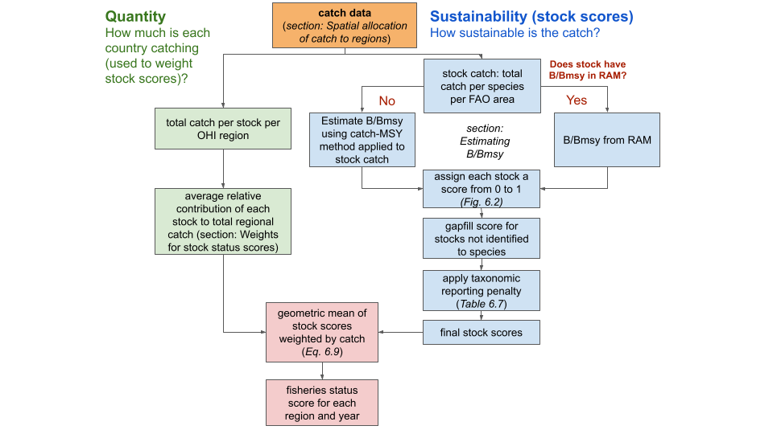

#### 7.6.1.1 Current status

*Spatial allocation of catch to regions*

The data we use to calculate $B/B_{MSY}$ and the weights used in the geometric mean are from Sea Around Us (2020) global marine fisheries catch data (Pauly *et al.* 2020). Sea Around Us (2020) uses a spatial allocation method to distribute FAO catch data (reported at the country scale) to a global grid of one half-degree cell resolution based on the spatial distribution of fished taxa from [FishBase](http://www.fishbase.org/) (Froese & Pauly 2022) and [SeaLifeBase](https://www.sealifebase.se/) (Palomares & Pauly 2022).

We use the Sea Around Us (2020) catch data in two ways. To get the data needed to weight the stock status scores, we download the total catch for each taxa within each region’s EEZ to get the total catch in tonnes for each year. To get the data needed to calculate $B/B_{MSY}$ values, we download the total catch for each taxa within each major fishing region (FAO Fisheries and Aquaculture Department 2015) for each year. We have traditionally included all fisheries catch in the Fisheries subgoal. However, a substantial portion of the catch is not used for human consumption, but rather for fish oil and fish meal used primarily for animal feed. Currently, it is estimated about 10% of forage fish enter the human diet directly (Froehlich 2018). To account for this, we excluded the proportion of catch that produce fish oil and fish meal for animal feed from the total catch.

To combine the $B/B_{MSY}$ values from the RAM database with the Sea Around Us (2020) global fish catch data, we used the spatial boundaries that Christopher Free created for the RAM stocks up to 2017 and assigned FAO and OHI regions to each stock (Free 2017). Newly added stocks to the RAM database had some spatially explicit information, but were mostly manually assigned regions based on best available information on stock distribution.

*Estimating $B/B_{MSY}$*

When we were unable to obtain $B/B_{MSY}$ values from the RAM database for a stock, we calculated them using a data-poor, or catch only model, developed by Martell & Froese (2013), and hereafter referred to as the “catch-MSY” method. The latter was chosen, among other data-limited methods because it was as good, or better, at predicting RAM $B/B_{MSY}$ values than other methods based on our initial testing. We compared $B/B_{MSY}$ scores from three catch models (catch-MSY, SSCOM, and COMSIR) as well as a variety of ensemble methods (Anderson *et al.* 2017). The catch_MSY model performed as well or better than the other models at predicting RAM $B/B_{MSY}$ values. Furthermore, this method performed well (although not as well as the Random Forest ensemble approach, based on a rank correlation analysis) in analyses using simulated stocks with a broad range of life history traits and different known sources of uncertainty (Anderson *et al.* 2017).

We defined a stock as species occurring within a major fishing area, and consequently, we ran the catch-MSY model using yearly catch data aggregated to FAO region from 1950 to the most current year. We chose this definition because many fish populations straddle the boundaries of EEZs. Any aggregation method will be biased in some way, but populations with the largest catches are most often straddling stocks, so a bias in assessments due to erroneous aggregation of catch could occur more often with cosmopolitan species that include small, sedentary (i.e., patchily distributed) populations that are less likely to play a dominant role in a country’s fisheries. The catch-MSY model was applied only to stocks identified to the species level.

The catch-MSY method is based on the same assumptions used in many stock assessment models (Schaefer 1954), namely that the change in a population’s biomass depends on its biomass in the previous year and two population-specific parameters: the carrying capacity (${K}$) and rate of population increase (${r}$). The method estimates the status of a given population using landings time-series as proxies for biomass removals from the population, and using empirically derived relationships of relative peak to current catch values to estimate depletion at the end of the time series (Martell & Froese 2013). Then, a sampling procedure is used to estimate the distribution of values of ${r}$ and ${K}$ that are compatible with the estimated current depletion levels, and are constrained within the range that maintains viable population abundance and at the same time does not exceed the population’s carrying capacity. In the original formulation of Martell & Froese (2013) the geometric mean ${r}$ and ${K}$ were used to derive an estimate of MSY. Rosenberg et al. (2014) modified this method by producing a biomass time series for each of the viable ${r-K}$ pairs using the surplus production model. The arithmetic mean biomass time series was selected and the current year stock abundance (${B}$) relative to the abundance that achieves ${MSY}$ ($B_{MSY}$) produced a measure, $B/B_{MSY}$.

A potential issue of the catch-MSY method (when using the default “constrained” prior) is that declining catch is assumed to indicate declining population biomass (resulting in lower $B/B_{MSY}$ values) rather than reduced effort or improved management. When declining catch is known to be due to reduced effort and/or improved management this results in artificially low $B/B_{MSY}$ values; however, the catch-MSY model can be modified by using a “uniform” prior distribution for the final biomass. However, this adjustment should be considered carefully because the model will assume that all stocks with declining catch are rebuilding (resulting in higher $B/B_{MSY}$ values), which is unrealistic. Previously, for the 2015 assessment, we attempted to use the constrained vs. uniform prior for each stock based on the catch weighted fishery management scores of the regions catching the stock. However, recent analyses suggest this method did not improve the ability of the catch-MSY derived $B/B_{MSY}$ values to predict RAM values, suggesting we were adding additional complication that did not improve our model. Consequently, all analyses are done using the “constrained” prior.

*Weights for stock status scores*

To get the data needed to weight the stock status scores, we sum the total catch for each taxa within each region’s EEZ to get the total catch in tonnes for each year. We then average each taxa’s catch within each region across all years from 1980 to the most current year’s data. Consequently, for a taxa within a region, the average catch value is the same across all years (only the $B/B_{MSY}$ value will vary across years.). This provides an estimate of the mean potential contribution of each species to total food provision, independent of yearly stochastic fluctuations of the population and possible recent declines.

*Goal model calculations*

The status of wild caught fisheries, $x_{fis}$, for each reporting region in each year was calculated as the geometric mean of the stock status scores, $SS$ (derived from $B/B_{MSY}$ score for each stock, described below) and weighted by the stock’s relative contribution to overall catch, $C$, such that:

$$x_{fis} = \prod _{ i=1 }^{ n }{ { SS }_{ i }^{ (\frac { { C }_{ i } }{
\sum { { C }_{ i } } } ) } }, (Eq. 6.9)$$

where ${i}$ is an individual taxon and $n$ is the total number of taxa in the reported catch for each region throughout the time-series, and ${C}$ is the average catch, since the first non null record, for each taxon within each region.

We used a geometric weighted mean to account for the portfolio effect of exploiting a diverse suite of resources, such that small stocks that are doing poorly will have a stronger influence on the overall score than they would using an arithmetic weighted mean, even though their ${C}$ contributes relatively little to the overall tonnage of harvested seafood within a given region. The behavior of the geometric mean is such that improving a well-performing stock is not rewarded as much as improving one that is doing poorly. We believe this behavior is desirable because the recovery of stocks in poor condition requires more effort and can have more important effects on the system than making a species that is already abundant even more abundant. In this way, the score is not solely driven by absolute tonnes of fish produced and accounts for preserving the health of a diversity of species.

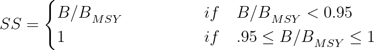

where, for $B/B_{MSY} < 1$ (with a 5% buffer), status declines with direct proportionality to the decline of $\beta$ with respect to $B_{MSY}$, while for $B/B_{MSY} > 1$, status is given a perfect score. Thus, consistent with previous work (Halpern *et al.* 2012), countries are rewarded for having wild stocks at the biomass that can sustainably deliver the maximum sustainable yield, -5% to allow for measurement error, and are penalized for over-harvesting.

For the 2021 assessment, we decided to exclude all underharvest penalties because by applying an underharvest penalty, we ended up unduly penalizing regions that have high proportions of underharvested stocks, which may be intentional in many cases. This suggests that an improvement to our fisheries approach by including a more just underharvest penalty could be needed.

**Figure 6.2: Conversion of $B/B_{MSY}$ to stock status, $SS$ score.**

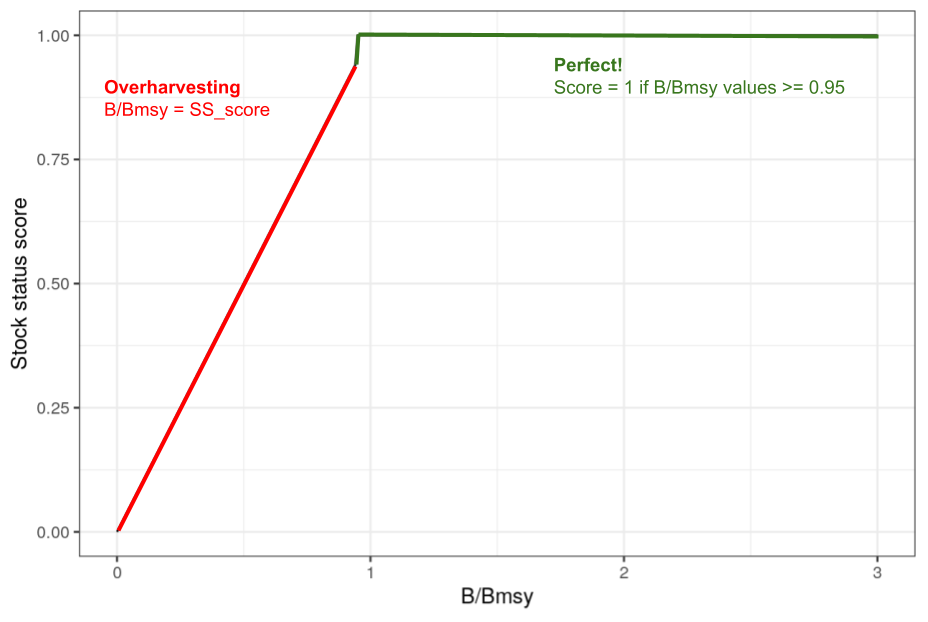

**Table 6.7: Penalty applied to gapfilled stock status scores** The penalty is multiplied by the gapfilled stock status score to obtain the final stock status score.

| ISSCAAP taxon code | Description | Penalty (gapfilled score multiplied by value) |
| --- | --- | --- |
| 1 | e.g., Marine fishes not identified, Miscellaneous marine molluscs | 0.1 |
| 2 | Class, Subclass, Subphylum (e.g., Cephalopoda, Holocephali, Crustacea) | 0.25 |
| 3 | Order (e.g., Chimaeriformes, Octopoda) | 0.5 |
| 4 | Family (e.g., Lamnidae, Squillidae) | 0.8 |
| 5 | Genus (e.g., Strongylocentrotus, Scyllarides) | 0.9 |
| 6 | Species | 1 (no penalty) |

*Model limitations*

This model is based on single-species assessments of stock status and thus cannot predict the effect of multi-species interactions. This model adopts $B=B_{MSY}$ as a single-species reference point, which by various assessment frameworks is considered very conservative (e.g., Froese *et al.* (2011)), and the fact that the single-species values are aggregated using a geometric mean ensures that some multi-species effects may influence the scores. Nonetheless, a better understanding of the emerging effects of fishing various species at their reference levels would be desirable and will hopefully be possible in the future.

Despite the fact that invertebrates represent a large proportion of global caught biomass, and represent the dominant stocks in many regions, stock assessment approaches for these taxa are poorly developed. The catch-MSY approach was applied to invertebrates even though the model developers only tested it on fish (Martell & Froese 2013). Part of the challenge in broadly testing this approach on organisms other than fish is the lack of a large enough collection of invertebrate assessments to use for validation testing.

This approach captures whether stocks have been historically well managed, but it is worth noting that it does not directly measure current food production.

#### 7.6.1.2 Trend

Trend was calculated as described in section 5.3.1.

#### 7.6.1.3 Data

*Status and trend*

B/Bmsy estimates (fis_b_bmsy): The ratio of fish population abundance compared to the abundance required to deliver maximum sustainable yield (RAM and catch-MSY data)

Fishery catch data (fis_meancatch): Mean commercial catch for each OHI region (averaged across years)

*Pressure*

High bycatch due to artisanal fishing (fp_art_hb): Pressure due to artisanal high bycatch fishing identified by discard tonnes and standardized by NPP

Low bycatch due to artisanal fishing (fp_art_lb): Pressure due to artisanal low bycatch fishing identified by reported and IUU tonnes and standardized by NPP

High bycatch due to commercial fishing (fp_com_hb): Pressure due to industrial high bycatch fishing identified by discard tonnes and standardized by NPP

Low bycatch due to commercial fishing (fp_com_lb): Pressure due to industrial low bycatch fishing identified by reported and IUU tonnes and standardized by NPP

Intertidal habitat destruction (hd_intertidal): Coastal population density (25 mi from shore) as a proxy for intertidal habitat destruction

Subtidal hardbottom habitat destruction (hd_subtidal_hb): Presence of blast fishing as an estimate of subtidal hard bottom habitat destruction

Subtidal soft bottom habitat destruction (hd_subtidal_sb): Pressure on soft-bottom habitats due to demersal destructive commercial fishing practices (e.g., trawling)

Chemical pollution (po_chemicals): Modeled chemical pollution within EEZ from commercial shipping traffic, ports and harbors, land-based pesticide use (organic pollution), and urban runoff (inorganic pollution)

Nutrient pollution (po_nutrients): Modeled nutrient pollution within EEZ based on crop fertilizer and manure consumption

Nonindigenous species (sp_alien): Measure of harmful invasive species

Genetic escapes (sp_genetic): Introduced mariculture species (Mariculture Sustainability Index) as a proxy for genetic escapes

Weakness of social progress (ss_spi): Inverse of Social Progress Index scores

Weakness of governance (ss_wgi): Inverse of World Governance Indicators (WGI) six combined scores

*Resilience*

Management of habitat to protect fisheries biodiversity (fp_habitat): Survey responses by country to the Convention on Biological Diversity (CBD) Third National Report: habitat related questions

Minderoo Global Fishing Index (fp_fish_management): Country scale fisheries governance capacity based on policy and objectives, management capacity, information availability and monitoring, level and control of access to fisheries resources, compliance management system, and stakeholder engagement and participation

Artisanal fisheries management effectiveness (fp_artisanal): Quality of management of small-scale fishing for artisanal and recreational purposes

EEZ protected marine areas (fishing preservation) (fp_mpa_eez): Protected marine areas within EEZ (lasting special places calculation applied to the entire EEZ)

Management of habitat to protect habitat biodiversity (hd_habitat): Survey responses by country to the Convention on Biological Diversity (CBD) Third National Report: habitat related questions

EEZ protected marine areas (habitat preservation) (hd_mpa_eez): Protected marine areas within EEZ (lasting special places calculation applied to the entire EEZ)

Social Progress Index (res_spi): Social Progress Index scores

Measure of ecological integrity (species_diversity_eez): Marine species condition (species subgoal status score) as a proxy for ecological integrity

Strength of governance (wgi_all): World Governance Indicators (WGI) six combined scores

### 7.6.2 Mariculture (subgoal of food provision)

The mariculture subgoal attempts to measure each region’s food production from mariculture relative to its capacity (United Nations 2023) and sustainability (*Monterey bay aquarium seafood watch* 2023). A basic problem facing previous assessments of mariculture was the lack of an ecologically- and socially-based reference point for the potential yield of every suitable mariculture species for every type of geographic habitat and location. Determining such reference points for every country at the global scale is difficult, not only because of key missing data and information, but also because species, genotypes and habitats suitable for production in any given location are likely to change from year to year. However, recent research (Gentry *et al.* 2017) estimated the global biological potential for marine aquaculture at a high resolution spatial scale, addressing one of these key gaps: ecological reference points. To account for the social and economic realities and constraints to these ecological potentials, we constrained the per-country potential to 1% of this tonnage estimate and used these country values as reference points. Furthermore, the paper does not exclude high biodiversity or environmentally sensitive areas, meaning 100% of potential aquaculture tonnage estimate is a large overestimation of what is actually possible. Additionally, we include a sustainability score for each species in each region which is based on the [Monterey Bay Aquarium Seafood Watch aquaculture recommendations](https://www.seafoodwatch.org/seafood-recommendations/standards-revision) (*Monterey bay aquarium seafood watch* 2023).

#### 7.6.2.1 Current status

The status of the mariculture subgoal, $x_{mar}$, was defined as production of strictly marine taxa from FAO categories for both marine and brackish waters, excluding species that were not used as a source of food for human consumption. In particular this was only an issue for seaweeds, as many seaweed species are not used for human consumption (or only partially used for human consumption). Table 6.8 shows the proportions, with a justification column, explaining the proportions of each seaweed species used for human consumption.

**Table 6.8 Mariculture seaweed exclusion**. List of seaweed mariculture species, what proportion of their harvest is not used for human consumption, and a justification for the exclusion.

FAO species name

Proportion non food use

Justification

[Chondracanthus chamissoi]

0.800

- non-food use determined (some for food and carageenan): “This species is of economic importance because it is edible and used for carrageenan production.” [source](https://www.researchgate.net/publication/251407321_Cultivation_of_the_red_alga_Chondracanthus_chamissoi_Sexual_reproduction_and_seedling_production_in_culture_under_controlled_conditions)
- food use deteremined: “In addition to its commercialization for the extraction of carrageenan, there is an increasing demand for human consumption in Asia” [source](https://www.researchgate.net/publication/226813687_Chondracanthus_chamissoi_Rhodophyta_Gigartinales_in_northern_Chile_Ecological_aspects_for_management_of_wild_populations)
- “On the coasts of Peru, the red seaweed known as yuyo (Chondracanthus chamissoi) is dried and then sold in the inland regions where it is incorporated into soups.” [source](https://www.slowfood.com/the-world-ocean-day-vegetables-of-the-sea-and-their-role-in-saving-the-environment/)
- 80% proportion determined by best guess.

[Porphyra columbina]

0.010

- food use determined using New Zealand Gov (Porphyra columbina is also known as karengo indicated as a high value food algae) [source](https://teara.govt.nz/en/seaweed/page-4)

Seaweed and Man: [source](https://link.springer.com/chapter/10.1007/978-3-642-28451-9_22)

“Of the 30 million tonnes of farmed seaweedsproduced in 2016 (Table 9), some species (e.g. Undaria pinnatifida, Porphyra spp. and Caulerpa spp., produced in East and Southeast Asia) are produced almost exclusively for direct human consumption, although lowgrade products and scraps from processing factories are used for other purposes, including feed for abalone culture.” [source](http://www.fao.org/3/i9540en/i9540en.pdf)

1% proportion determined by best guess.

[Spirulina maxima]

0.300

- non-food use determined using Seaweed Industry Association: [source](https://seaweedindustry.com%20and%20FAO:%20http://www.fao.org/docrep/006/y4765e/y4765e0b.htm)

food use determined: It has been produced commercially for the last 30 years for food and specialty feeds. Currently, more than 70 per cent of Spirulina market is for human consumption, mainly as health food because of its rich content of protein, essential amino acids, minerals, vitamins, and essential fatty acids. [source](https://www.sciencedirect.com/science/article/pii/B9780128007761000194)

30% proportion determined [source](https://www.sciencedirect.com/science/article/pii/B9780128007761000194.)

Aquatic plants nei

1.000

- non-food use determined using Seaweed Industry Association: [source](https://seaweedindustry.com%20and%20FAO:%20http://www.fao.org/docrep/006/y4765e/y4765e0b.htm)

100% proportion determined based on best guess (the most important seaweed species are all listed)

Babberlocks

0.000

- food use determined using FAO [source](http://www.fao.org/docrep/006/y4765e/y4765e0b.htm;%20also%20called%20Alaria%20esculenta:%20https://en.wikipedia.org/wiki/Alaria_esculenta)

Scientific name: Alaria esculenta

Common name: badderlocks, dabberlocks, winged kelp

0% proportion based on FAO link.

Bright green nori

0.010

- food use determined using Seaweed and Man (Green nori indicated as an important algae for food) [source](https://link.springer.com/chapter/10.1007/978-3-642-28451-9_22)

“Of the 30 million tonnes of farmed seaweedsproduced in 2016 (Table 9), some species (e.g. Undaria pinnatifida, Porphyra spp. and Caulerpa spp., produced in East and Southeast Asia) are produced almost exclusively for direct human consumption, although lowgrade products and scraps from processing factories are used for other purposes, including feed for abalone culture.” [source}(http://www.fao.org/3/i9540en/i9540en.pdf)

Scientific name: Porphyra spp. And Pyropia spp.

Common name: Nori, Laver

1% proportion determined by best guess.

Dark green nori

0.010

- food use determined using Seaweed and Man (Green nori indicated as an important algae for food): [source](https://link.springer.com/chapter/10.1007/978-3-642-28451-9_22)

“Of the 30 million tonnes of farmed seaweedsproduced in 2016 (Table 9), some species (e.g. Undaria pinnatifida, Porphyra spp. and Caulerpa spp., produced in East and Southeast Asia) are produced almost exclusively for direct human consumption, although lowgrade products and scraps from processing factories are used for other purposes, including feed for abalone culture.” [source](http://www.fao.org/3/i9540en/i9540en.pdf)

Scientific name: Porphyra spp. And Pyropia spp.

Common name: Nori, Laver

1% proportion determined by best guess.

Sea lettuces nei

0.500

- food and non-food use determined: https://en.wikipedia.org/wiki/Sea_lettuce [source](https://caseagrant.ucsd.edu/seafood-profiles/sea-lettuce-0)

Scientific name: Ulva

Common name: sea lettuce

50% proportion based on best guess.

Brown seaweeds

0.500

- food and non-food use determined using FAO; “The main uses of brown seaweeds are as foods and as the raw material for the extraction of the hydrocolloid, alginate.” “There is also a market for fresh seaweed as a feed for abalone. In Australia, the brown seaweed Macrocystis pyrifera and the red seaweed Gracilaria edulis have been used.”: [source](http://www.fao.org/3/a-y4765e.pdf)

50% proportion determined by best guess.

Caulerpa seaweeds

0.010

- food use determined using FAO manual: [source](http://www.fao.org/docrep/field/003/ac417e/AC417E00.htm%20AND%20http://www.fao.org/3/a-y4765e.pdf)

1% proportion determined by best guess: “Of the 30 million tonnes of farmed seaweedsproduced in 2016 (Table 9), some species (e.g. Undaria pinnatifida, Porphyra spp. and Caulerpa spp., produced in East and Southeast Asia) are produced almost exclusively for direct human consumption, although lowgrade products and scraps from processing factories are used for other purposes, including feed for abalone culture.” [source](http://www.fao.org/3/i9540en/i9540en.pdf)

[Meristotheca senegalense]

0.000

- Type of red macroalgae with nutritional value for humans: [source](https://academicjournals.org/journal/AJFS/article-full-text/376F45B62073)

0% proportion determined by article referenced above.

Dulse

0.100

- food use determined: [source](https://www.sciencedirect.com/science/article/pii/B9780124186972000131) source

fish feed use determined using FAO:[source](http://www.fao.org/3/a-y4765e.pdf)

“Pacific dulse (Palmaria mollis) has been found to be a valuable food for the red abalone, Haliotis rufescens, and development of land-based cultivation has been undertaken with a view to producing commercial quantities of the seaweed.”

Scientific name: Palmaria palmata

Common name: Dulse

10% proportion determined by best guess.

Elkhorn sea moss

0.990

- non-food use, primary carageenan use determined using Buschmann et al (also Kappaphycus alvarezii): [source](https://www.tandfonline.com/doi/full/10.1080/09670262.2017.1365175), [source](https://en.wikipedia.org/wiki/Kappaphycus_alvarezii)

food use (whole food supplement): [source](https://www.mdpi.com/2072-6643/9/11/1261/htm)

“The rapid growth in the farming of tropical seaweed species (Kappaphycus alvarezii and Eucheuma spp.) in Indonesia as raw material for carrageenan extraction has been the major contributor to growth in farmed aquatic plant production in the recent past.” [source](http://www.fao.org/3/i9540en/i9540en.pdf)

Scientific name: Kappaphycus alvarezii

Common name: Elkhorn sea moss

99% proportion determined by best guess.

Eucheuma seaweeds nei

0.900

- non-food use, primary carageenan use determined using Buschmann et al: [source](https://www.tandfonline.com/doi/full/10.1080/09670262.2017.1365175);

Seaweed and Man: [source](https://link.springer.com/chapter/10.1007/978-3-642-28451-9_22);

Seaweed Industry Association: [source](https://seaweedindustry.com%20and%20FAO:%20http://www.fao.org/docrep/006/y4765e/y4765e0b.htm,%20http://www.fao.org/3/a-y4765e.pdf)

food use determined using FAO: [source](http://www.fao.org/3/AC287E/AC287E01.htm) “In some overseas countries, such as Indonesia and Philippines, Eucheuma seaweed is also eaten raw. People like to eat it fresh in salads.”

“The rapid growth in the farming of tropical seaweed species (Kappaphycus alvarezii and Eucheuma spp.) in Indonesia as raw material for carrageenan extraction has been the major contributor to growth in - farmed aquatic plant production in the recent past.” [source](http://www.fao.org/3/i9540en/i9540en.pdf)

Scientific name: Eucheuma denticulatum, Kappaphycus alvarezii, Kappaphycus striatum

Common name: Eucheumoid algae,

Fragile codium

0.100

- non-food use determined using Seaweed Industry Association: [source](https://seaweedindustry.com), [source](https://www.sciencedirect.com/science/article/pii/B9780128133125000042) (“Codium fragile_ and Codium vermilara_derived water-soluble sulfated arabinogalactans prevented coagulation, but they induced platelet aggregation (Ciancia et al., 2007).”)

food use determined: [source](https://en.wikipedia.org/wiki/Codium_fragile), [source](http://www.eattheweeds.com/codiums-edible-around-the-world-2/)

Scientific name: Codium fragile

Common name: green sea fingers, dead man’s fingers, felty fingers, forked felt-alga, stag seaweed, green fleece, oyster thief

10% proportion determined by best guess.

Fusiform sargassum

0.000

- food use determined by Bushmann et al (fusiform sargassum also Hijiki or Sargassum fusiforme): [source](https://www.tandfonline.com/doi/full/10.1080/09670262.2017.1365175); [source](https://en.wikipedia.org/wiki/Hijiki)

alternative names: [source](http://www.uniprot.org/taxonomy/590727)

Recent studies have shown that hijiki contains potentially toxic quantities of inorganic arsenic, and the food safety agencies of several countries (excluding Japan), including Canada, the United Kingdom, and the United States, have advised against its consumption.

Scientific name: Fusiform sargassum

Common name: Hijiki

0% proportion determined by best guess.

Gelidium seaweeds

0.800

- non-food use determined by FAO (most of agar comes from Gracilaria or Gelidium, but the Gelidium FAO data is from Korea where it is also consumed as food): [source](http://www.fao.org/3/a-y4765e.pdf); Frangoudes 2016 (Edible seaweed in Korea): [source](https://www.sciencedirect.com/science/article/pii/B9780128027721000026)

food and non-food use: https://en.wikipedia.org/wiki/Gelidium_amansii

80% proportion determined by best guess.

Giant kelp

0.900

- non-food use determined by FAO (giant kelp produced in Chile are mostly bought by processors that turn it into alginate): [source](http://www.fao.org/3/a-y4765e.pdf)

food use determined: “The primary commercial product obtained from giant kelp is alginate, but humans also harvest this species on a limited basis for use directly as food, as it is rich in iodine, potassium, and other minerals. It can be used in cooking in many of the ways other sea vegetables are used, and particularly serves to add flavor to bean dishes.” [source](https://en.wikipedia.org/wiki/Macrocystis_pyrifera)

Scientific name: Macrocystis pyrifera

Common name: Giant kelp

90% proportion determined by best guess.

Gracilaria seaweeds

0.750

- non-food use, primary agar use determined using Buschmann et al: [source](https://www.tandfonline.com/doi/full/10.1080/09670262.2017.1365175);

Seaweed and Man: [source](https://link.springer.com/chapter/10.1007/978-3-642-28451-9_22);

Seaweed Industry Association: [source](https://seaweedindustry.com%20and%20FAO:%20http://www.fao.org/docrep/006/y4765e/y4765e0b.htm)

food use determined using FAO: [source](http://www.fao.org/3/a-y4765e.pdf) (“Gracilaria is sold to agar producers and some is used as food. For food consumption, the seaweed is usually gathered and sold fresh, locally. It is most common in South-East Asian countries such as Indonesia, Malaysia, the Philippines and southern Thailand, mainly in coastal communities. It is also popular with most ethnic groups in Hawaii, and is sold fresh in Honolulu markets as limu manauea or limu ogo.”)

Scientific name: Gracilaria spp.

Common name: Gracilaria, Ogo

75% proportion determined by best guess.

Green laver

0.010

- food use determined using Seaweed and Man (green laver is same as green nori but different country names): [source](https://link.springer.com/chapter/10.1007/978-3-642-28451-9_22);

Seaweed Industry Association: [source](https://seaweedindustry.com)

FAO: [source](http://www.fao.org/docrep/006/y4765e/y4765e0b.htm), [source](http://www.fao.org/3/a-y4765e.pdf)

“Of the 30 million tonnes of farmed seaweedsproduced in 2016 (Table 9), some species (e.g. Undaria pinnatifida, Porphyra spp. and Caulerpa spp., produced in East and Southeast Asia) are produced almost exclusively for direct human consumption, although lowgrade products and scraps from processing factories are used for other purposes, including feed for abalone culture.” [source](http://www.fao.org/3/i9540en/i9540en.pdf)

Scientific name: Porphyra spp. And Pyropia spp.

Common name: Nori, Laver

1% proportion determined by best guess.

Harpoon seaweeds

0.750

- non-food use deteremined by Netalgae.eu (75% of seaweed produced in France is processed): [source](http://www.netalgae.eu/uploadedfiles/11-09-12_poster_wp1_en.pdf);

harpoon seaweed’s scientific name is Asparagopsis armata, which is likely used in cosmetics: [source](https://link.springer.com/content/pdf/10.1007%2Fs10811-005-2799-5.pdf), [source](https://www.roscara.com/wild-irish-seaweed-asparagopsis-armata/)

food use determined: [source](https://en.wikipedia.org/wiki/Asparagopsis), [source](https://en.wikipedia.org/wiki/Asparagopsis_taxiformis) (“Asparagopsis is one of the most popular types of limu.[3] in the cuisine of Hawaii, it is principally a condiment. It is known as Limu kohu in the Hawaiian language meaning”pleasing seaweed”. Limu kohu is a traditional ingredient in poke.”)

Scientific name: Asparagopsis spp.

Common name: Harpoon seaweed, harpoon weed, limu

75% proportion determined by best guess.

Japanese isinglass

0.950

- non-food use determined by Whittaker 1910 (japanese isinglass is a type of Gelidium seaweed): [source](https://ajph.aphapublications.org/doi/pdf/10.2105/AJPH.1.9.632);

FAO (most of agar comes from Gracilaria or Gelidium, but the Gelidium FAO data is from Korea where it is also consumed as food): [source](http://www.fao.org/3/a-y4765e.pdf);

Frangoudes 2016 (Edible seaweed in Korea): [source](https://www.sciencedirect.com/science/article/pii/B9780128027721000026)

Scientific name: Gelidium spp.

Common name: Japanese isinglass, agar agar

95% proportion determined by best guess.

Japanese kelp

0.100

- food use determined using Buschmann et al: [source](https://www.tandfonline.com/doi/full/10.1080/09670262.2017.1365175);

Seaweed and Man ( also likely Saccharina japonica or kombu): [source](https://link.springer.com/chapter/10.1007/978-3-642-28451-9_22);

food use determined using Seaweed Industry Association: [source](https://seaweedindustry.com%20and%20FAO:%20http://www.fao.org/docrep/006/y4765e/y4765e0b.htm)

non food use determined: [source](https://en.wikipedia.org/wiki/Saccharina_japonica) (“Saccharina japonica is also used for the production of alginates, with China producing up to ten thousand tons of the product each year.”),

“The only exception is for Laminaria japonica, which is cultivated in China for food but sometimes surplus material is diverted to the alginate industry in China.” [source](http://www.fao.org/3/y4765e/y4765e07.htm)

Scientific name: Saccharina japonica (formerly Laminaria japonica)

Common name: Kombu

10% proportion determined by best guess.

Kelp nei

0.500

- not in FAO mariculture data 5/4/18

50% proportion based on best guess.

Laver (Nori)

0.010

- food use determined using Seaweed and Man (Porphyra or nori indicated as a high value food algae): [source](https://link.springer.com/chapter/10.1007/978-3-642-28451-9_22) [source](http://www.fao.org/3/y4765e/y4765e0b.htm)

“Of the 30 million tonnes of farmed seaweedsproduced in 2016 (Table 9), some species (e.g. Undaria pinnatifida, Porphyra spp. and Caulerpa spp., produced in East and Southeast Asia) are produced almost exclusively for direct human consumption, although lowgrade products and scraps from processing factories are used for other purposes, including feed for abalone culture.” [source](http://www.fao.org/3/i9540en/i9540en.pdf)

Scientific name: Porphyra spp. And Pyropia spp.

Common name: Nori, Laver

1% proportion determined by best guess.

Mozuku

0.010

- food use determined by Tongafish.gov (most of Tonga production of mozuku is shipped to Japanese market where it is used for the food market, some amounts are shipped elsewhere for use in homeopathic purposes, but unsure how much): [source](http://www.tongafish.gov.to/images/documents/Management%20Plans/Approved%20Seaweed%20Management%20Plan%202012-2013.pdf) [source](http://www.fao.org/3/y4765e/y4765e0b.htm)

1% proportion determined by best guess.

Nori nei

0.010

- food use determined using Seaweed and Man (Porphyra or nori indicated as a high value food algae): [source](https://link.springer.com/chapter/10.1007/978-3-642-28451-9_22)

“Of the 30 million tonnes of farmed seaweedsproduced in 2016 (Table 9), some species (e.g. Undaria pinnatifida, Porphyra spp. and Caulerpa spp., produced in East and Southeast Asia) are produced almost exclusively for direct human consumption, although lowgrade products and scraps from processing factories are used for other purposes, including feed for abalone culture.” [source](http://www.fao.org/3/i9540en/i9540en.pdf)

Scientific name: Porphyra spp. And Pyropia spp.

Common name: Nori, Laver

1% proportion determined by best guess.

Red seaweeds

0.750

- non-food and food use determined using FAO (red algae in Indonesia and Portugal mostly agar-containing seaweeds) (The main uses of red seaweeds are as food and as sources of two hydrocolloids: agar and carrageenan): [source](http://www.fao.org/3/a-y4765e.pdf)

75% proportion based on best guess.

Sea belt

0.950

- non-food and food use determined using SINTEF Fisheries and Aquaculture Norway (sea belt is also Saccharina latissima or sugar kelp, mostly used for processed agar in Norway, food market growing but seems to be small): [source](https://www.innovasjonnorge.no/contentassets/95273c625e1c4b4caf8b4d0a36020dc0/2014-sintef---seaweed-in-the-bioeconomy.pdf);

not mentioned as a main use in Forbord et al 2012: [source](https://link.springer.com/article/10.1007/s10811-011-9784-y)

Scientific name: Saccharina latissima

Common name: sea belt, sugar kelp

95% proportion based on best guess.

Seaweeds nei

0.150

- food use determined using production value range and variety of countries - since most seaweeds are used for human consumption

15% proportion determined by best guess.

Spiny eucheuma

0.900

- non-food use, primary carageenan use determined using Buschmann et al: [source](https://www.tandfonline.com/doi/full/10.1080/09670262.2017.1365175);

Seaweed and Man: [source](https://link.springer.com/chapter/10.1007/978-3-642-28451-9_22);

Seaweed Industry Association: [source](https://seaweedindustry.com)

FAO: [source](http://www.fao.org/docrep/006/y4765e/y4765e0b.htm)

food use: “E. denticulatum can also be eaten fresh or blanched in boiling water and mixed with salad garnish, or made into”Eucheuma candy” or “kue” by cooking in water until a gel is formed, whereafter sugar is added. It is used as garnish for other dishes such as fish. In Lombok (Indonesia) about 400 t (wet weight) of E. denticulatum is used annually to prepare a boiled foodstuff, wrapped in banana leaf and known as “pencok”.” source

Scientific name: Eucheuma denticulatum

Common name: Spiny eucheuma

Tangle

0.990

- non-food use determined by Irishseaweeds (tangle is Laminaria digitata): [source](http://www.irishseaweeds.com/kelp-laminaria-digitata/);

biotech use: [source](http://www.bim.ie/our-work/projects/developing,irish,seaweed,farming,for,high,value,products/)

“Laminaria digitata in France is the main raw material for the alginate industry.” [source](http://www.fao.org/3/y4765e/y4765e07.htm) food use determined: [source](https://gallowaywildfoods.com/forest-kelp-and-oarweed-edibility-identification-distribution/#:~:text=Edible%20Uses%3A%20Unless%20you%20harvest,body%20and%20depth%20of%20flavour).

Scientific name: Laminaria digitata

Common name: tangle, tangleweed, oarweed

99% proportion determined by best guess.

Wakame

0.010

- food use determined using Buschmann et al (wakame is undaria): [source](https://www.tandfonline.com/doi/full/10.1080/09670262.2017.1365175);

Seaweed Industry Association: [source](https://seaweedindustry.com)

FAO: [source](http://www.fao.org/docrep/006/y4765e/y4765e0b.htm)

“Of the 30 million tonnes of farmed seaweedsproduced in 2016 (Table 9), some species (e.g. Undaria pinnatifida, Porphyra spp. and Caulerpa spp., produced in East and Southeast Asia) are produced almost exclusively for direct human consumption, although lowgrade products and scraps from processing factories are used for other purposes, including feed for abalone culture.” [source](http://www.fao.org/3/i9540en/i9540en.pdf)

Scientific name: Undaria pinnatifida

Common name: Wakame

1% proportion determined by best guess.

Wakame nei

0.010

- food use determined using Buschmann et al (wakame is undaria): [source](https://www.tandfonline.com/doi/full/10.1080/09670262.2017.1365175);

Seaweed Industry Association: [source](https://seaweedindustry.com)

FAO: [source](http://www.fao.org/docrep/006/y4765e/y4765e0b.htm)

“Of the 30 million tonnes of farmed seaweedsproduced in 2016 (Table 9), some species (e.g. Undaria pinnatifida, Porphyra spp. and Caulerpa spp., produced in East and Southeast Asia) are produced almost exclusively for direct human consumption, although lowgrade products and scraps from processing factories are used for other purposes, including feed for abalone culture.” [source](http://www.fao.org/3/i9540en/i9540en.pdf)

Scientific name: Undaria pinnatifida

Common name: Wakame

1% proportion determined by best guess.

Warty gracilaria

0.950

- non-food and food use determined by FAO: “Gracilaria is used as food and in the preparation of food products.” “The principal product of Gracilaria is agar.” “Unknown quantities of Gracilaria are used in several places (e.g. Japan, China, Hawaii, St. Lucia) in the fresh vegetable market for human consumption. There, Gracilaria prices can be high (e.g. 5-7 USD /kg) although the volumes consumed are relatively low (e.g. a few tonnes per year).” “The use of Gracilaria as marine invertebrate feed has developed in Asia, especially in the fish pond system of Taiwan Province of China, leading to development of polycultures of Gracilaria and abalone which uses Gracilaria as the sole source of food of these gastropods. In the past the emphasis was to produce Gracilaria biomass for agar production. Now it is more profitable for the pond operators to supply their Gracilaria as fresh food to abalone farmers.” [source](http://www.fao.org/fishery/culturedspecies/Gracilaria_spp/en)

Scientific name: Gracilaria gracilis (previously Gracilaria verrucosa)

Giant kelps nei

0.900

- non-food use determined by FAO (giant kelp produced in Chile are mostly bought by processors that turn it into alginate): [source](http://www.fao.org/3/a-y4765e.pdf)

90% proportion based on best guess.

Green seaweeds

0.750

- non-food use determined using Soares et al 2017 (sounds like using seaweed as food still underutilized or growing in Portugal): [source](http://iopscience.iop.org/article/10.1088/1757-899X/231/1/012126/pdf); fertilizers, fish feed, wastewater treatment [source](http://www.fao.org/3/y4765e/y4765e0c.htm)

food use: [source](http://www.fao.org/3/y4765e/y4765e0b.htm)

includes: green laver, sea lettuce

75% proportion determined by best guess.

Coarse seagrape

0.000

- food use determined using the Ministry of Marine Resources Government of the Cook Islands (seagrape is a Caulerpa): source;

FAO manual: [source](http://www.fao.org/docrep/field/003/ac417e/AC417E00.htm)

Scientific name: Caulerpa racemosa

Common name: Coarse seagrape

0% proportion determined by best guess.

[Sargassum spp]

0.990

- non-food use determined using FAO (most brown kelps used for alginate due to high concentration in tissues): [source](http://www.fao.org/3/a-y4765e.pdf);

Sargassum in Mexico specifically: [source](https://www.e-algae.org/journal/view.php?number=2819)

“Sargassum, is only used when nothing else is available: its alginate is usually borderline quality and the yield usually low.” “Sargassum is collected on the south coast of Java (Indonesia) and in the Philippines. In the former country it is used for alginate production while in the latter there are pilot studies for its use in alginate production, but its present use is to produce seaweed meal for animal feed.” [source](http://www.fao.org/3/y4765e/y4765e07.htm)

Spirulina nei

0.300

- non-food use determined using Seaweed Industry Association: [source](https://seaweedindustry.com) and FAO: [source](http://www.fao.org/docrep/006/y4765e/y4765e0b.htm)

30% proportion determined by Spirulina maxima.

[Dunaliella salina]

1.000

- used in B-carotene, lutein, fatty acids, etc [source](https://www.sciencedirect.com/topics/agricultural-and-biological-sciences/dunaliella)

“Known for its antioxidant activity because of its ability to create large amount of carotenoids, it is used in cosmetics and dietary supplements.” [source](https://en.wikipedia.org/wiki/Dunaliella_salina)

100% proportion determined by best guess.

[Capsosiphon fulvescens]

0.100

- used as traditional medicine: “It has been consumed as food with unique flavor and soft texture to treat stomach disorders and hangovers” [source](https://www.hindawi.com/journals/bmri/2016/1462916/)

“These results suggest that C. fulvescens has greater potential to be used as human food and as an ingredient in formulated food.” “Capsosiphon fulvescens is filamentous green seaweed traditionally eaten in the southwestern regions of Korea” [source](https://www.researchgate.net/publication/225622961_Assessment_of_the_nutritional_value_of_Capsosiphon_fulvescens_Chlorophyta_Developing_a_new_species_of_marine_macroalgae_for_cultivation_in_Korea)

10% proportion determined by best guess.

Slender wart weed

0.750

- food and non-food use determined: “Gracilaria is a genus of red algae (Rhodophyta) notable for its economic importance as an agarophyte, as well as its use as a food for humans and various species of shellfish. Various species within the genus are cultivated among Asia, South America, Africa and Oceania.” [source](https://en.wikipedia.org/wiki/Gracilaria)

Scientific name: Gracilaria gracilis

Common name: slender wart weed

75% proportion determined by Gracilaria seaweeds.

[Macrocystis integrifolia]

- food use determined https://www.centralcoastbiodiversity.org/giant-perennial-kelp-bull-macrocystis-integrifolia.html

1% proportion determined by best guess.

[Cladosiphon okamuranus]

0.100

- food use determined https://en.wikipedia.org/wiki/Cladosiphon_okamuranus - sometimes used to treat cancer

[Eucheuma isiforme]

0.800

- non-food use determined using Wikipedia

Skottsberg’s gigartina

0.750

- non-food and food use determined using FAO (red algae in Indonesia and Portugal mostly agar-containing seaweeds) (The main uses of red seaweeds are as food and as sources of two hydrocolloids: agar and carrageenan):http://www.fao.org/3/a-y4765e.pdf

Green sea feather

0.200

- food use determined https://sealifebase.nrm.se/summary/Caulerpa-sertularioides.html

SOLIERIACEAE

0.750

- used red seaweed include value

BANGIACEAE

0.010

- food use determined, wikipedia mentions wide food use https://en.wikipedia.org/wiki/Bangiaceae

SARGASSACEAE

- used sargassum spp value

ULOTRICHACEAE

0.150

- used overall seaweed exclude value due to lack of available information on the species

GIGARTINACEAE

0.750

- used red seaweed include value

LESSONIACEAE

0.500

- used same exclude value as kelp nei

OSCILLATORIACEAE

1.000

- excluded as is typically freshwater https://en.wikipedia.org/wiki/Oscillatoria

DUNALIELLACEAE

0.150

- used overall seaweed exclude value due to lack of more information

CHORDARIACEAE

0.500

- used brown seaweed include value

Harvest data reported by FAO does not always clearly describe whether it is derived from mariculture or from land-based facilities. Mariculture status, $x_{mar}$, was therefore assessed as the current re-scaled met potential of harvested yield, $Y_{c}$, within each country, multiplied by the production weighted average of sustainability of mariculture within each county, $S_{c}$, such that:

$$x_{mar} = Y_{c} \ \times \ S_{c}, \ (Eq. 6.10)$$

where, $Y_{c}$, is the current re-scaled met potential of harvested yield within each country, c, such that:

$$Y_{c}= \frac {\displaystyle\sum _{ k=1 }^{ N }{ { Y }_{ k } }}{Y_{r,
ref}}, \ (Eq. 6.11)$$

where, $Y_{r,ref}$ is the value that corresponds to 1% of the potential aquaculture harvest in each region, and $Y_{k}$ is the 4-year moving window average of tonnes of production (United Nations 2023) for each ${k}$ mariculture species that is currently or at one time cultured within a country. $Y_{c}$ is then capped at 1, so that no country can receive a better-than-perfect score. $S_{c}$ is the production weighted average of sustainability of mariculture in each country, such that:

$$S_{c} = \frac { \displaystyle\sum _{ k=1 }^{ N }{ { Y }_{ k }{ S }_{
k,r } } } {{\displaystyle\sum _{ k=1 }^{ N }{ { Y }_{ k } }}}, (Eq.
6.12)$$

where, $Y_{k}$ is the 4-year moving window average of tonnes of production (United Nations 2023) for each ${k}$ mariculture species that is currently or at one time cultured within a country, and $S_{k,r}$ is the sustainability score for each $k$ mariculture species and region.

All regions scoring above 1.0 are given a score of 1.0. A score of one could occur when the current aquaculture harvest is greater than 1% of the biological production potential (taken from (Gentry *et al.* 2017)) and mariculture harvest is perfectly sustainable within a region. However, when a region has a current harvested yield that is less than 100 tonnes, and when 1% of potential mariculture harfvest is less than 100 tonnes, a score of NA is assigned. This assumption is made to avoid giving a perfect score to regions that have essentially zero harvested yield, and essentially zero biological production potential.

The sustainability score, $S_{k,r}$, for each species in each region is based on the [Monterey Bay Aquarium Seafood Watch aquaculture recommendations](https://www.seafoodwatch.org/seafood-recommendations/standards-revision) (*Monterey bay aquarium seafood watch* 2023). Ten mariculture practice criteria from the Monterey Bay Aquarium Seafood Watch Aquaculture Recommendations contributed to the sustainability of mariculture (data quality, effluent, habitat risk, chemical use, feed, escapes, disease, source of stock, predator and wildlife mortalities, and escape of secondary species). These criteria represent the internal mariculture practices with the potential to affect the long term sustainability of the mariculture system. Scores for each assessment criterion were aggregated and averaged. All country average scores were then rescaled from 0 to 1 using the maximum possible raw SFW score of 10 and minimum of 1. These scores are country and species-specific, however, many country/species combinations are not assessed by Seafood Watch. Given that each mariculture record must have a corresponding sustainability score, we used a series of steps to estimate sustainability scores for every country and species. If a country/species match was available we used that, otherwise, we gapfilled using the following sequence:

1. Used the global species value provided by Seafood Watch.
2. Within a country, used the average of species within the same family.
3. Within a UN geo-political region, used the average of species within the same family.
4. Global, used average of species within the same family.
5. Global, used average of species within a broad taxonomic grouping (e.g., crustaceans, algae, bivalves, etc.).
6. Finally, if these scores were not available for the categories above, we used the global average of all species.

Seaweed or algae species were given the global seaweed sustainability score provided by the Seafood Watch recommendations. We are aware that there is some bias associated with using scores derived as averages across countries because they were originally assigned to specific species-country pairs, nevertheless this is preferable to applying a sustainability score solely based on a subset of the species harvested.

#### 7.6.2.2 Trend

Trend was calculated as described in section 5.3.1.

#### 7.6.2.3 Data

*Status and trend*

*Pressure*

*Resilience*

## 7.7 Livelihoods and economies

Due to discontinued and non-updated source datasets, we have not updated the status of this goal since 2013 (changes across scenario years after 2013 are due to changes in pressures/resilience).

The jobs and revenue produced from marine-related industries are clearly of huge value to many people, even those who do not directly participate in the industries but value community identity, tax revenue, and indirect economic and social impacts of a stable coastal economy.

For a job or wage sector to be included in our assessment it needed to report at least two time points and have data for all or most coastal regions (reported separately, not as a single global number). However, a sector did not need to have data for all three measures – jobs, wages, and revenue – as this would have eliminated almost every sector. Consequently, the sectors that comprise each of the three measures differ (Table 6.8) and there is variation across regions in which sectors and measures comprise the status score (because of gaps in datasets and the fact that not all sectors exist in all countries). If a region only had one data layer (a single sector for only one measure), a status score was not calculated for that region and instead, a regional average was applied. We used a weighted average of the region’s UN geopolitical region; revenue values were weighted by each region’s GDP, jobs were weighted by each region’s workforce size, and wages were unweighted.

A number of sectors were not included primarily because sufficient data do not exist. In the future, particularly in finer scale applications, it would be desirable to include these sectors, including (but not limited to) ecotourism (beyond just cetacean watching), sailing/kayaking/boating, surfing/kiteboarding, etc., offshore wind and wave energy, navigation assistance, safety and security, coastal development, scientific research, and restoration and conservation.

**Table 6.9. Livelihoods and economies sectors.** Sectors for which data were available for each component of the livelihoods and economies goal.

[output not shown]

**Table 6.10. Sector multipliers.** Sector-specific multipliers used to calculate total jobs and total revenue created by sector-based employment in developing and developed nations. N/A (not applicable) indicates that total employment or total revenue (direct plus indirect and induced) data were provided by primary data source, eliminating the need for a multiplier value. ND indicates no data available for that sector.

|  | Developed Countries |  | Developing Countries |  |
| --- | --- | --- | --- | --- |
| **Sector** | **Jobs** | **Revenue** | **Jobs** | **Revenue** |
| Tourism | N/A | N/A | N/A | N/A |
| Commercial fishing | 1.582 | 1.568 | 1.582 | 1.568 |
| Marine mammal watching | 1.915 | 1.0 | 1.915 | 1.0 |
| Aquarium fishing | ND | 1.568 | ND | 1.568 |
| Wave & tidal energy | 1.88 | 1.652 | 1.88 | 1.652 |
| Mariculture | 2.7 | 2.377 | 1.973 | 1.59 |

This goal aims to maintain coastal livelihoods and economies (i.e., avoid the loss of, coastal and ocean-dependent jobs and revenues), while also maximizing livelihood quality (relative wages). It does not attempt to capture any aspects of job identity (i.e., the reputation, desirability or other social or cultural perspectives associated with different jobs), although one can examine the component parts that make up this goal to evaluate individual sectors and infer implications for job identity. We make the assumption that all marine-related jobs are equivalent, such that, for example, a fisherman could transition to a job in mariculture or ship-building without affecting the score of this goal. While job identity has social and cultural value, there are not adequate data to track individual workers and assess their job satisfaction on a global scale. We also do not include any measure of petroleum extraction, as we do not consider these practices to be related to the biophysical state of the system and, because they rely on a non-renewable resource, they are inherently unsustainable. Furthermore, because of data constraints, this goal does not provide more credit for sectors or economic activities that are more ecologically sustainable. Future, finer scale applications of the Index may incorporate these key considerations.

Gaps were filled in the adjustment datasets (national GDP and national employment) by first determining the average metric value (e.g., average employment rate) in UN geopolitical regions (United Nations (2013c)) for each year based on all countries in that region for which there were data. Using these regional average time series, we fit nonlinear models to the adjustment data. Using the model fit, we determined the slope between each year. To fill in missing data points in country time series, we applied the slope (percent change in the metric) between the missing year and the following year (or previous year, if necessary). We prioritized filling in backwards (e.g., if a country has data from 2006 and 2008, to fill in 2007, one would use the regional delta between 2008 and 2007), but filled forwards when there were no data for a subsequent year.

### 7.7.1 Economies (subgoal of livelihoods and economies)

Due to discontinued and static source datasets, we have not updated the status of this subgoal since 2013 (changes across scenario years after 2013 are due to changes in pressures/resilience) (United Nations 2013a).

This subgoal measures the revenue produced from marine-related industries.

#### 7.7.1.1 Current status

The model to estimate the status of the economies sub-goal, $x_{eco}$, is:

$$x_{eco} = \frac { \displaystyle\sum _{ k=1 }^{ N }{ { e }_{ c,k } } }{
\displaystyle\sum _{ k=1 }^{ N }{ { e }_{ r,k } } }, (Eq. 6.13)$$

where, $e$ is the total adjusted revenue generated directly and indirectly from sector $k$, at current $c$, and reference $r$, time points.

Because there is no absolute global reference point for revenue (i.e., a target number would be completely arbitrary), the economies subgoal uses a moving baseline as the reference point. Reference revenue is calculated as the value in the current year (or most recent year), relative to the value in a recent moving reference period, defined as 5 years prior to the current year. This reflects an implicit goal of maintaining coastal revenue on short time scales, allowing for decadal or generational shifts in what people want and expect. We allowed for a longer or shorter gap between the current and recent years if a 5 year span was not available from the data, but the gap could not be greater than 10 years. Our preferred gap between years was as follows (in order of preference): 5, 6, 4, 7, 3, 8, 2, 9, 1, and 10 years.

Absolute values for $e$ in the current and reference periods were lumped across all sectors before calculating reference values (even though the current and reference years will not be exactly the same for all sectors), allowing a decrease in one sector to be balanced by an increase in another sector. As such, we do not track the status of individual sectors and instead always focus on the status of all sectors together.

To control for inflation/deflation, we used a standard dollar year. To account for broader economic forces that may affect revenue independent of changes in ocean health (e.g., a global recession), we adjusted revenue based on a country’s GDP (i.e., must keep pace with growth in GDP). The current and reference years used for GDP data were based on the average current year and average reference year across the sector data sources used for revenue.

#### 7.7.1.2 Trend

Trend was calculated as the slope in the individual sector values (not summed sectors) for revenue over the most recent five years (as opposed to the status, which examines changes between two points in time, current versus five years prior to current), corrected by GDP. We calculated the average for revenue by averaging slopes across sectors weighted by the revenue in each sector.

#### 7.7.1.3 Data

*Status and trend*

Economic status scores (eco_status): Calculated using corrected revenue data for several marine sectors (data not updated since 2013)

Economic trend scores (eco_trend): Calculated using change in revenue for several marine sectors (data not updated since 2013)

Sectors in each region (le_sector_weight): Proportion of jobs within each marine sector

*Pressure*

Ocean acidification (cc_acid): Pressure due to increasing ocean acidification, scaled using biological thresholds

Sea level rise (cc_slr): Pressure due to rising mean sea level

Sea surface temperature (cc_sst): Presure due to increasing extreme sea surface temperature events

High bycatch due to artisanal fishing (fp_art_hb): Pressure due to artisanal high bycatch fishing identified by discard tonnes and standardized by NPP

Low bycatch due to artisanal fishing (fp_art_lb): Pressure due to artisanal low bycatch fishing identified by reported and IUU tonnes and standardized by NPP

High bycatch due to commercial fishing (fp_com_hb): Pressure due to industrial high bycatch fishing identified by discard tonnes and standardized by NPP

Low bycatch due to commercial fishing (fp_com_lb): Pressure due to industrial low bycatch fishing identified by reported and IUU tonnes and standardized by NPP

Intertidal habitat destruction (hd_intertidal): Coastal population density (25 mi from shore) as a proxy for intertidal habitat destruction

Subtidal hardbottom habitat destruction (hd_subtidal_hb): Presence of blast fishing as an estimate of subtidal hard bottom habitat destruction

Subtidal soft bottom habitat destruction (hd_subtidal_sb): Pressure on soft-bottom habitats due to demersal destructive commercial fishing practices (e.g., trawling)

Chemical pollution (po_chemicals): Modeled chemical pollution within EEZ from commercial shipping traffic, ports and harbors, land-based pesticide use (organic pollution), and urban runoff (inorganic pollution)

Nutrient pollution (po_nutrients): Modeled nutrient pollution within EEZ based on crop fertilizer and manure consumption

Coastal nutrient pollution (po_nutrients_3nm): Modeled nutrient pollution within 3nm based on crop fertilizer and manure consumption

Pathogen pollution (po_pathogens): Percent of population without access to improved sanitation facilities as a proxy for pathogen pollution

Marine plastics (po_trash): Global marine plastic pollution

Nonindigenous species (sp_alien): Measure of harmful invasive species

Genetic escapes (sp_genetic): Introduced mariculture species (Mariculture Sustainability Index) as a proxy for genetic escapes

Weakness of social progress (ss_spi): Inverse of Social Progress Index scores

Weakness of governance (ss_wgi): Inverse of World Governance Indicators (WGI) six combined scores

*Resilience*

Global Competitiveness Index (GCI) (li_gci): Competitiveness in achieving sustained economic prosperity

Social Progress Index (res_spi): Social Progress Index scores

Strength of governance (wgi_all): World Governance Indicators (WGI) six combined scores

### 7.7.2 Livelihoods (subgoal of livelihoods and economies)

Due to discontinued and non-updated source datasets, we have not updated the status of this subgoal since 2013 (changes across scenario years after 2013 are due to changes in pressures/resilience).

This subgoal measures the jobs produced from marine-related industries. Livelihoods includes two equally important sub-components, the number of jobs, which is a proxy for livelihood quantity, and the per capita average annual wages, which is a proxy for job quality.

#### 7.7.2.1 Current status

The status of the livelihoods sub-goal, $x_{liv}$, is calculated as:

$$x_{liv} = \frac { \frac { \sum _{ 1 }^{ k }{ { j }_{ c,k } } }{ \sum _{
1 }^{ k }{ { j }_{ r,k } } } \quad +\quad \frac { \sum _{ 1 }^{ k }{ {
w }_{ m,k } } }{ \sum _{ 1 }^{ k }{ { w }_{ r,k } } } }{ 2 }, (Eq.
6.14)$$

where $j$ is the adjusted number of direct and indirect jobs within sector $k$ within a region and $w$ is the average PPP-adjusted wages per job within the sector. Jobs are summed across sectors and measured at current, $c$, and reference, $r$, time points. Adjusted wage data are averaged across sectors within each region, $m$, and the reference country, $r$, with the highest average wages across all sectors.

Because there is no absolute global reference point for jobs (i.e., a target number would be completely arbitrary), this component of the livelihoods subgoal uses a moving baseline as the reference point. Jobs, $j$, are calculated as a relative value: the value in the current year (or most recent year), $c$, relative to the value in a recent moving reference period, $r$, defined as 5 years prior to $c$. This reflects an implicit goal of maintaining coastal jobs on short time scales, allowing for decadal or generational shifts in what people want and expect. We allowed for a longer or shorter gap between the current and recent years if a 5 year span was not available from the data, but the gap could not be greater than 10 years. Our preferred gap between years was as follows (in order of preference): 5, 6, 4, 7, 3, 8, 2, 9, 1, and 10 years. For wages, $w$, we assumed the reference value was the highest value observed across all regions.

Absolute values for $j$ and $w$ in the current and reference period (jobs) or region (wages) were lumped across all sectors before calculating relative values (even though the current and reference years will not be exactly the same for all sectors), allowing a decrease in one sector to be balanced by an increase in another sector. As such, we do not track the status of individual sectors and instead always focus on the status of all sectors together. For wages, we use the most current data available for each country and each sector, but only use data from 1990 on, assuming that wages are relatively slow to change over time (apart from inflation adjustments, which we control for by using real dollars) and thus can be compared across sectors and countries without controlling for year.

Wages data were divided by the inflation conversion factor so that wage data across years would be comparable in 2010 US dollars (inflation conversion factors were downloaded from http://oregonstate.edu/cla/polisci/sahr/sahr). These data were also multiplied by the purchasing power parity-adjusted per capita GDP https://data.worldbank.org/indicator/NY.GDP.PCAP.CD. To account for broader economic forces that may affect jobs independent of changes in ocean health (e.g., a global recession), we adjusted jobs data by dividing by percent employment for the corresponding year: (1 – percent unemployment) * total labor force (World Bank 2014b,c). For example, if unemployment increased from the reference to the current period, we would expect the number of marine-related jobs to decrease by a comparable proportion, without causing a lower score for the goal. Therefore, the objective of the goal is actually no loss of jobs and jobs must keep pace with growth in employment rates or sustain losses no greater than national increases in unemployment rates. The current and reference years used for unemployment data were based on the average current year and average reference year across the sector data sources used for number of jobs.

#### 7.7.2.2 Trend

Trend was calculated as the slope in the individual sector values (not summed sectors) for jobs and wages over the most recent five years (as opposed to the status, which examines changes between two points in time, current versus five years prior to current), corrected by national trends in employment rates and average wages. We then calculated the average trend for jobs across all sectors, with the average weighted by the number of jobs in each sector. We calculated the average trend for wages across all sectors. We then averaged the wages and jobs average slopes to get the livelihoods trend.

#### 7.7.2.3 Data

*Status and trend*

Sectors in each region (le_sector_weight): Proportion of jobs within each marine sector

Livelihood status scores (liv_status): Calculated using adjusted job and wage data in several marine sectors (data not updated since 2013)

Livelihood trend scores (liv_trend): Calculated using change in adjusted job and wage data in several marine sectors (data not updated since 2013)

*Pressure*

Sea level rise (cc_slr): Pressure due to rising mean sea level

High bycatch due to artisanal fishing (fp_art_hb): Pressure due to artisanal high bycatch fishing identified by discard tonnes and standardized by NPP

Low bycatch due to artisanal fishing (fp_art_lb): Pressure due to artisanal low bycatch fishing identified by reported and IUU tonnes and standardized by NPP

High bycatch due to commercial fishing (fp_com_hb): Pressure due to industrial high bycatch fishing identified by discard tonnes and standardized by NPP

Low bycatch due to commercial fishing (fp_com_lb): Pressure due to industrial low bycatch fishing identified by reported and IUU tonnes and standardized by NPP

Intertidal habitat destruction (hd_intertidal): Coastal population density (25 mi from shore) as a proxy for intertidal habitat destruction

Subtidal hardbottom habitat destruction (hd_subtidal_hb): Presence of blast fishing as an estimate of subtidal hard bottom habitat destruction

Subtidal soft bottom habitat destruction (hd_subtidal_sb): Pressure on soft-bottom habitats due to demersal destructive commercial fishing practices (e.g., trawling)

Chemical pollution (po_chemicals): Modeled chemical pollution within EEZ from commercial shipping traffic, ports and harbors, land-based pesticide use (organic pollution), and urban runoff (inorganic pollution)

Nutrient pollution (po_nutrients): Modeled nutrient pollution within EEZ based on crop fertilizer and manure consumption

Coastal nutrient pollution (po_nutrients_3nm): Modeled nutrient pollution within 3nm based on crop fertilizer and manure consumption

Pathogen pollution (po_pathogens): Percent of population without access to improved sanitation facilities as a proxy for pathogen pollution

Marine plastics (po_trash): Global marine plastic pollution

Nonindigenous species (sp_alien): Measure of harmful invasive species

Genetic escapes (sp_genetic): Introduced mariculture species (Mariculture Sustainability Index) as a proxy for genetic escapes

Weakness of social progress (ss_spi): Inverse of Social Progress Index scores

Weakness of governance (ss_wgi): Inverse of World Governance Indicators (WGI) six combined scores

*Resilience*

Global Competitiveness Index (GCI) (li_gci): Competitiveness in achieving sustained economic prosperity

Economic diversity (li_sector_evenness): Sector evenness based on Shannon’s Diversity Index calculated on the proportion of jobs in each sector as a measure of economic diversity

Social Progress Index (res_spi): Social Progress Index scores

Strength of governance (wgi_all): World Governance Indicators (WGI) six combined scores

## 7.8 Natural products

In many countries the harvest of non-food natural products is important for local economies and can also be traded internationally. The sustainable harvest of these products is therefore an important component of a healthy ocean. This goal assesses the ability of countries to maximize the sustainable harvest of living marine resources, and includes three natural product categories: ornamental fish, fish oil and fish meal, and inedible seaweeds and marine plants (Table 6.12). It does not include bioprospecting, which focuses on potential (and largely unknowable and potentially infinite) value rather than current realized value, or non-living products such as oil and gas or mining products which by definition are not sustainable. It also excludes wood from mangroves as few data exist for if/where this harvest is happening and whether it is sustainable, as well as oils from mammals as this harvest is widely seen as unsustainable. In past assessments we included coral harvest, shells, and sponges, but we now exclude these resources. In the case of coral, harvest is not sustainable given current and future global threats. For sponges and shells, harvest yields were often highly variable and had relatively small values (Table 6.11), resulting in scores fluctuating dramatically across years for some countries even though the total USD values contributed very little to national economies (e.g. going from 100USD to 200USD would double the score).

| Commodity | Total value (USD) |
| --- | --- |
| fish_oil | 29801732 |
| seaweeds | 15655200 |
| ornamentals | 4476725 |
| corals | 2798557 |
| shells | 1664880 |
| sponges | 473272 |

As such, we focus on three natural product categories: ornamental fish, fish oil and fish meal, and inedible seaweeds and marine plants (Table 6.12).

#### 7.8.0.1 Current status

To determine the total production in tonnes for seaweed we summed seaweed production provided in the FAO global aquaculture production data (United Nations 2023). To determine total production in tonnes of ornamental fish we summed the products provided in the FAO commodities data (UN-FAO 2023). Finally, to determine the total production in tonnes for fish oil and fish meal, we used Sea Around Us Project (2020) global marine fisheries catch data (Pauly *et al.* 2020) and B/Bmsy data (Costello *et al.* 2012; Ricard *et al.* 2012; Martell & Froese 2013; Thorson *et al.* 2013; Rosenberg *et al.* 2014; Costello *et al.* 2016) calculated from our fisheries sub-goal (methods can be found in section 6.6.1), and subsetted the stocks for stocks used for fish oil production (Table 6.12) (Froehlich 2018). The tonnes of harvest of fish oil and fish meal species were multiplied by 0.9 to reflect the amount of the fish actually going to production of feed or oil, while the other 10% of fish is used in other ways, such as direct human consumption (Froehlich 2018).

**Table 6.12. Natural product categories**. List of species and FAO products included in each of the three natural product categories.

| Commodity | Subcategory |
| --- | --- |
| fish oil | Lepidotrigla brachyoptera, Etmopterus spinax, Pomacanthidae, Labridae, Tautogolabrus adspersus, Champsocephalus esox, Trachichthyidae, Platycephalidae, Holocentridae, Tripterophycis gilchristi, Aploda… |
| ornamentals | Ornamental saltwater fish, Ornamental fish nei |
| seaweeds | [Chondracanthus chamissoi], [Porphyra columbina], [Spirulina maxima], Aquatic plants nei, Babberlocks, Bright green nori, Dark green nori, Sea lettuces nei, Brown seaweeds, Caulerpa seaweeds, [Meristo… |

The status of the seaweeds and ornamentals categories, $P_c$, were calculated as:

$$P_c = { H }_{ c }\ast { S }_{ c } , (Eq. 6.15)$$
where, $H_{c}$ is the harvest level for a category relative to its own peak reference point and $S_{c}$ is the sustainability of that commodity.

For seaweeds and ornamental fish we calculated $H_{c}$ as the most recent harvest (in metric tons) per region relative to the maximum harvest ever achieved in that region, under the assumption that the maximum achieved at any point in time was likely the maximum possible. This creates a reference point internal to each country. We rescaled these values from 0-1, with the peak harvest set to 1.0.

For fish oil and fish meal, we used the same methods to calculate the status as our fisheries sub-goal, only we subsetted the species (Table 6.12) to those species that contribute to fish oil and fish meal (methods for our fisheries sub-goal can be found in section 6.6.1). The tonnes of harvest of fish oil and fish meal species were multiplied by 0.9 to reflect the proportion of catch among these taxa going to production of feed or oil.

Although we do not know actual sustainable levels of harvest for ornamentals, $S_{p}$, in each region, we estimated it based on exposure and risk components:

$$S_{c} = 1- average({ E_c+R_c }), (Eq. 6.16)$$

where ${E_c}$ is the exposure term and ${R_c}$ is the risk term for ornamentals.

The exposure term, $E_c$, is the ln-transformed intensity of harvest for ornamental fish calculated as tonnes of harvest per km<sup>2</sup> of coral and rocky reef, relative to the global maximum. We ln transformed the harvest intensity scores because the distribution of values was highly skewed; because we do not know the true threshold of sustainable harvest, nearly all values would be considered highly sustainable without the log transformation. To estimate rocky reef extent area (km<sup>2</sup>) we used data from Halpern et al. (2008) (Halpern *et al.* 2008), which assumes rocky reef habitat exists in all cells within 1 km of shore. Coral extent area (km<sup>2</sup>) are from UNEP-WCMC et al. (2018) (UNEP-WCMC *et al.* 2018).

The risk term, $R_c$, is based on whether ornamental fishing has unsustainable harvest practices. In specific, we used the intensity of cyanide and dynamite fishing as a proxy. Risk for ornamental fish was set based on assessments of cyanide or dynamite fishing by Reefs at Risk Revisited (www.wri.org/publication/reefs-at-risk-revisited) under the assumption that most ornamental fishes are harvested from coral reefs.

For seaweed commodity sustainability, we used the mariculture sustainability scores represented in the Monterey Bay Aquarium Seafood Watch aquaculture recommendations (*Monterey bay aquarium seafood watch* 2023). Ten mariculture practice criteria from the Monterey Bay Aquarium Seafood Watch Aquaculture Recommendations contributed to the sustainability of mariculture (data quality, effluent, habitat risk, chemical use, feed, escapes, disease, source of stock, predator and wildlife mortalities, and escape of secondary species). These criteria represent the internal mariculture practices with the potential to affect the long term sustainability of the mariculture system. Scores for each assessment criterion were aggregated and averaged. All country average scores were then rescaled from 0 to 1 using the maximum possible raw SFW score of 10 and minimum of 1. The sustainability score for seaweeds in the Seafood Watch recommendations was a global score, 0.79, which was applied to the seaweed harvest. Seaweed is widely regarded as a very sustainable aquaculture harvest, however, it does poorly on 3 of the 10 criteria that Seafood Watch uses, bringing its average down to 0.79. In specific, it scores poorly on the data quality (having robust and up-to-date information on production practices and their impacts available for analysis), escapes (preventing population-level impacts to wild species or other ecosystem-level impacts from farm escapes), and habitat (maintaining the functionality of ecological valuable habitat) criteria.

The fish oil commodity sustainability was estimated using the B/Bmsy values which were calculated in our fisheries sub-goal (section 6.6.1).

To estimate the status score, $x_{np}$, for each region and year we took the weighted average of the individual product scores, $P_c$, such that:

$$x_{np} = \frac { \displaystyle\sum _{ c=1 }^{ N }{ { P }_{ c }\ast { w
}_{ c } } }{ { { N } } }, (Eq. 6.17)$$

where ${N}$ is the number of product categories, $c$, that were harvested, and $w_{c}$ is the relative contribution of each product to the overall status of the goal. $w_c$ was calculated as the ratio of the 5-year average maximum US dollar value for a product (from the smoothed, gap-filled FAO commodities data) across all years of data for the product, relative to the 5-year average sum of maximum values for all products harvested in the country.

If a product had a peak value, but was missing a harvest value for that product in a given year, we used $w_{c} = 0$ during the aggregation for that year.

Because dollar values were not present in the data that was used for seaweeds and fish oil, we relied on the FAO global commodities dataset to obtain these, which we used to calculate $w_c$ for each category (Table 6.13).

**Table 6.13. Natural product categories**. List of FAO products included in each of the three natural product categories used for determining natural product weights.

| Commodity | Subcategory |
| --- | --- |
| fish oil | Alaska pollock oil, nei, Anchoveta oil, Capelin oil, Clupeoid oils, nei, Cod liver oil, Fish body oils, nei, Fish liver oils, nei, Gadoid liver oils, nei, Hake liver oil, Halibuts, liver oils, Herring… |
| ornamentals | Ornamental saltwater fish, Ornamental fish nei |
| seaweeds | Agar agar in powder, Agar agar in strips, Agar agar nei, Carrageen (Chondrus crispus), Kelp, Kelp meal, Other brown algae (laminaria, eisenia/ecklonia), Other inedible seaweeds, Seaweeds and other alg… |

There are several important caveats about the natural product status model. First, our approach for ornamentals is supply (export) based. If declining demand for ornamentals causes a decline in production, the producing country’s score declines even if it could (sustainably) produce more. Similarly, if a country chose to reduce or halt production of ornamentals in order to improve conservation or sustainability, its score would decline. Second, we do not have Maximum Sustainable Yield (MSY) estimates for seaweeds or ornamental fish production. When such estimates become available in the future they can easily be incorporated. These scenarios may lead to decreases in the score for a region despite maintenance or even improvement of the sustainable harvest of natural products. Finally, our estimate of the sustainability of the harvest practices of ornamental fish are likely overly optimistic. For example, fishing for ornamental trade often employs unsustainable techniques such as cyanide fishing, but we have few data to inform such an estimate of sustainability in the status calculation for ornamental fish.

This model requires both harvest tonnes and value data. However, because of inconsistencies with how data are reported to FAO, there are many cases where harvest data but no value data are reported, and vice versa. We gapfilled these data because otherwise these mismatches in reporting would result in losing real data, especially for producing the weight contributions of each natural product commodity. We used a linear regression model to estimate missing tonnes or US dollar values (Frazier *et al.* 2016). For countries that never harvested a product, we assumed they cannot produce it and treat that as a ‘no data’ rather than a zero value. For countries that harvested a product at any point in time, empty values are treated as zeros since the country has the capacity to harvest that product.

#### 7.8.0.2 Trend

Trend was calculated as described in section 5.3.1.

#### 7.8.0.3 Data

*Status and trend*

Habitat extent of rocky reef (hab_rockyreef_extent): Area of rocky reef habitat

Seaweed mariculture sustainability score (np_seaweed_sust): Seaweed mariculture sustainability based on the Mariculture Sustainability Index (MSI)

Fish oil and fish meal score (np_fofm_scores): Score based on the amount of sustainably and unsustainably caught forage fish used for fish oil and fish meal. Penalties are assigned for both under harvest and over harvested based on B/Bmsy estimates.

Risk of harvest practices for ornamental fish (np_risk_orn): Based on whether ornamental fishing has unsustainable harvest practices (i.e., the intensity of cyanide fishing for ornamental fish, and any harvest of corals since they are CITES protected species). Risk for ornamental fish was set based on assessments of cyanide or dynamite fishing by Reefs at Risk Revisited (www.wri.org/publication/reefs-at-risk-revisited) under the assumption that most ornamental fishes are harvested from coral reefs.

Exposure of ornamental fishing to coral and rocky reef habitats (np_exposure_orn): The ln-transformed intensity of harvest calculated as tonnes of harvest per km2?of coral and/or rocky reef for ornamentals, relative to the global maxiumum.

Relative natural product harvest value (np_harvest_product_weight): Relative importance of three marine commodities (fish oil, seaweeds ornamental fish) within each region determined by finding the relative contribution per a 5 year average of harvest (in USD) divided by the total 5 year average harvest value (in USD) per each commodity within each region.

Seaweed natural product harvest (np_seaweed_tonnes): Yield in metric tonnes of seaweed

Relative ornamental natural product harvest tonnes (np_orn_tonnes_relative): Tonnes of harvest of ornamentals relative to maximum harvest of the ornamentals within the region observed across years

*Pressure*

Ocean acidification (cc_acid): Pressure due to increasing ocean acidification, scaled using biological thresholds

Sea level rise (cc_slr): Pressure due to rising mean sea level

Sea surface temperature (cc_sst): Presure due to increasing extreme sea surface temperature events

UV radiation (cc_uv): Pressure due to increasing frequency of UV anomolies

High bycatch due to artisanal fishing (fp_art_hb): Pressure due to artisanal high bycatch fishing identified by discard tonnes and standardized by NPP

Low bycatch due to artisanal fishing (fp_art_lb): Pressure due to artisanal low bycatch fishing identified by reported and IUU tonnes and standardized by NPP

Low bycatch due to commercial fishing (fp_com_lb): Pressure due to industrial low bycatch fishing identified by reported and IUU tonnes and standardized by NPP

Intertidal habitat destruction (hd_intertidal): Coastal population density (25 mi from shore) as a proxy for intertidal habitat destruction

Subtidal hardbottom habitat destruction (hd_subtidal_hb): Presence of blast fishing as an estimate of subtidal hard bottom habitat destruction

Subtidal soft bottom habitat destruction (hd_subtidal_sb): Pressure on soft-bottom habitats due to demersal destructive commercial fishing practices (e.g., trawling)

Chemical pollution (po_chemicals): Modeled chemical pollution within EEZ from commercial shipping traffic, ports and harbors, land-based pesticide use (organic pollution), and urban runoff (inorganic pollution)

Nutrient pollution (po_nutrients): Modeled nutrient pollution within EEZ based on crop fertilizer and manure consumption

Nonindigenous species (sp_alien): Measure of harmful invasive species

Weakness of social progress (ss_spi): Inverse of Social Progress Index scores

Weakness of governance (ss_wgi): Inverse of World Governance Indicators (WGI) six combined scores

*Resilience*

Management of habitat to protect fisheries biodiversity (fp_habitat): Survey responses by country to the Convention on Biological Diversity (CBD) Third National Report: habitat related questions

Minderoo Global Fishing Index (fp_fish_management): Country scale fisheries governance capacity based on policy and objectives, management capacity, information availability and monitoring, level and control of access to fisheries resources, compliance management system, and stakeholder engagement and participation

Artisanal fisheries management effectiveness (fp_artisanal): Quality of management of small-scale fishing for artisanal and recreational purposes

Coastal protected marine areas (fishing preservation) (fp_mpa_coast): Protected marine areas within 3nm of coastline (lasting special places goal status score)

EEZ protected marine areas (fishing preservation) (fp_mpa_eez): Protected marine areas within EEZ (lasting special places calculation applied to the entire EEZ)

CITES signatories (g_cites): Convention on International Trade in Endangered Species of Wild Fauna and Flora (CITES) signatories

Management of habitat to protect habitat biodiversity (hd_habitat): Survey responses by country to the Convention on Biological Diversity (CBD) Third National Report: habitat related questions

Coastal protected marine areas (habitat preservation) (hd_mpa_coast): Protected marine areas within 3nm of coastline (lasting special places goal status score)

EEZ protected marine areas (habitat preservation) (hd_mpa_eez): Protected marine areas within EEZ (lasting special places calculation applied to the entire EEZ)

Management of waters to preserve biodiversity (po_water): Survey responses by country to the Convention on Biological Diversity (CBD) Third National Report: clean water management related questions

Social Progress Index (res_spi): Social Progress Index scores

Measure of coastal ecological integrity (species_diversity_3nm): Marine species condition (same calculation and data as the species subgoal status score) calculated within 3 nm of shoreline as a proxy for ecological integrity

Measure of ecological integrity (species_diversity_eez): Marine species condition (species subgoal status score) as a proxy for ecological integrity

Strength of governance (wgi_all): World Governance Indicators (WGI) six combined scores

## 7.9 Sense of Place

This goal attempts to capture the aspects of the coastal and marine system that people value as part of their cultural identity. This definition includes people living near the ocean and those who live far from it but still derive a sense of identity or value from knowing particular places or species exist. This goal is calculated using two equally weighted subgoals: iconic species and lasting special places.

### 7.9.1 Iconic species (subgoal of sense of place)

Iconic species are those that are relevant to local cultural identity through their relationship to one or more of the following: 1) traditional activities such as fishing, hunting or commerce; 2) local ethnic or religious practices; 3) existence value; and 4) locally-recognized aesthetic value (e.g., touristic attractions/common subjects for art such as whales). Ultimately, almost any species can be iconic to someone, and so the intent with this goal was to focus on those species widely seen as iconic from a cultural or existence value (rather than a livelihoods or extractive reason). Habitat-forming species were not included, nor were species harvested solely for economic or utilitarian purposes (even though they may be iconic to a sector or individual).

#### 7.9.1.1 Current status

The status of this sub-goal, $x_{ico}$, is the average of status scores of the iconic species in each region based on their IUCN Red List threat categories (IUCN 2022a):

$$x_{ico} = \frac { \displaystyle\sum_{ i=EX }^{ LC }{ S_{i}\times w_{i}
} }{ \displaystyle\sum_{ i=EX }^{ LC }{ S_{i} } }, (Eq. 6.18)$$

where for each IUCN threat category $i$, $S_{i}$ is the number of assessed species and $w_{i}$ is the status (Table 6.3) following the methods described by Butchart et al. (2007). This formulation gives partial credit to species that still exist but are in one of the other threat categories. The reference point is to have the risk status of all assessed species as Least Concern (i.e., a goal score = 1.0). Species that have not been assessed or labeled as data deficient are not included in the calculation.

The list of iconic species was drawn from several data sources (Table 7.5. Iconic species resources), but primarily from the World Wildlife Fund’s global and regional lists for Priority Species (especially important to people for their health, livelihoods, and/or culture) and Flagship Species (‘charismatic’ and/or well-known). Many lists exist for globally important, threatened, endemic, etc. species, but in all cases it is not clear if or to what extent these species represent culturally iconic species. The World Wildlife Fund is the only data source that included cultural reasons for listing iconic species. Although, iconic species vary largely among regions, we include little regional information in our list (i.e., the same list is applied to nearly all regions). Additional culturally important species species, available at the continent level (Reyes-García *et al.* 2023), were added to supplement the original iconic species list.

#### 7.9.1.2 Trend

We calculate trend using data the IUCN provides for current and past assessments of species, which we use to create a time series of average risk status for species within each region. Because IUCN assessments are generally infrequent for any given species, we derive the trend as the annual change in risk status for each species across the previous twenty years, rather than a five-year window typical of other goals, and include only taxa with two or more IUCN assessments within the past 20 years.

#### 7.9.1.3 Data

*Status and trend*

IUCN extinction risk (ico_spp_iucn_status): IUCN extinction risk category for iconic species located within each region

*Pressure*

Ocean acidification (cc_acid): Pressure due to increasing ocean acidification, scaled using biological thresholds

Sea surface temperature (cc_sst): Presure due to increasing extreme sea surface temperature events

High bycatch due to artisanal fishing (fp_art_hb): Pressure due to artisanal high bycatch fishing identified by discard tonnes and standardized by NPP

High bycatch due to commercial fishing (fp_com_hb): Pressure due to industrial high bycatch fishing identified by discard tonnes and standardized by NPP

Targeted harvest of cetaceans and marine turtles (fp_targetharvest): Targeted harvest of cetaceans and marine turtles

Intertidal habitat destruction (hd_intertidal): Coastal population density (25 mi from shore) as a proxy for intertidal habitat destruction

Subtidal hardbottom habitat destruction (hd_subtidal_hb): Presence of blast fishing as an estimate of subtidal hard bottom habitat destruction

Coastal chemical pollution (po_chemicals_3nm): Modeled chemical pollution within 3nm of coastline from commercial shipping traffic, ports and harbors, land-based pesticide use (organic pollution), and urban runoff (inorganic pollution)

Coastal nutrient pollution (po_nutrients_3nm): Modeled nutrient pollution within 3nm based on crop fertilizer and manure consumption

Marine plastics (po_trash): Global marine plastic pollution

Nonindigenous species (sp_alien): Measure of harmful invasive species

Weakness of social progress (ss_spi): Inverse of Social Progress Index scores

Weakness of governance (ss_wgi): Inverse of World Governance Indicators (WGI) six combined scores

*Resilience*

Management of habitat to protect fisheries biodiversity (fp_habitat): Survey responses by country to the Convention on Biological Diversity (CBD) Third National Report: habitat related questions

Minderoo Global Fishing Index (fp_fish_management): Country scale fisheries governance capacity based on policy and objectives, management capacity, information availability and monitoring, level and control of access to fisheries resources, compliance management system, and stakeholder engagement and participation

Artisanal fisheries management effectiveness (fp_artisanal): Quality of management of small-scale fishing for artisanal and recreational purposes

EEZ protected marine areas (fishing preservation) (fp_mpa_eez): Protected marine areas within EEZ (lasting special places calculation applied to the entire EEZ)

CITES signatories (g_cites): Convention on International Trade in Endangered Species of Wild Fauna and Flora (CITES) signatories

Management of habitat to protect habitat biodiversity (hd_habitat): Survey responses by country to the Convention on Biological Diversity (CBD) Third National Report: habitat related questions

EEZ protected marine areas (habitat preservation) (hd_mpa_eez): Protected marine areas within EEZ (lasting special places calculation applied to the entire EEZ)

Management of waters to preserve biodiversity (po_water): Survey responses by country to the Convention on Biological Diversity (CBD) Third National Report: clean water management related questions

Social Progress Index (res_spi): Social Progress Index scores

Measure of ecological integrity (species_diversity_eez): Marine species condition (species subgoal status score) as a proxy for ecological integrity

Strength of governance (wgi_all): World Governance Indicators (WGI) six combined scores

### 7.9.2 Lasting special places (subgoal of sense of place)

The lasting special places sub-goal focuses on geographic locations that hold particular value for aesthetic, spiritual, cultural, recreational or existence reasons (TRC 2004). This sub-goal is particularly hard to quantify. Ideally one would survey every community around the world to determine the top list of special places, and then assess how those locations are faring relative to a desired state (e.g., protected or well managed). The reality is that such lists do not exist. Instead, we assume areas that are protected indicate special places (i.e., the effort to protect them suggests they are important places). Clearly this is an imperfect assumption but in many cases it will be true.

The identification of protected areas does not indicate the proportion of special places in a region that are protected. To solve this problem we make two important assumptions. First, we assume that all countries have roughly the same percentage of their coastal waters and coastline that qualify as lasting special places. In other words, they all have the same reference target (as a percentage of the total area). Second, we assume that the target reference level is 30% of area protected (Hughes 2003).

#### 7.9.2.1 Current status

We calculate the status of this goal as:

$$x_{lsp} = \frac { \left( \frac{\%_{CMPA}}{\%_{Ref_{CMPA}}} + \frac
{\%_{CP}}{\%_{Ref_{CP}}} \right) }{ 2 }, (Eq. 6.19)$$

where, $\%_{CMPA}$ is the proportion of coastal marine protected area, $\%_{CP}$ is the proportion of coastline protected, and $\%_{Ref} = 30%$ for both measures.

We focus only on coastal waters (within 3 nautical miles of shore) for marine special places because we assume lasting special places are primarily in coastal areas. For coastlines, we focus only on the first 1-km-wide strip of land as a way to increase the likelihood that the area being protected by terrestrial parks is connected to the marine system in some way.

We use the United Nation’s World Database on Protected Areas (WDPA) to identify protected areas (UNEP-WCMC and IUCN 2022). The WDPA aggregates several key databases: IUCN’s World Commission on Protected Areas, Global Marine Protected Areas, UNESCO World Heritage Marine sites, National Parks and Nature Reserves, and the United Nations List of Protected Places. In most cases the year of designation is listed for each protected area.

#### 7.9.2.2 Trend

Trend was calculated as described in section 5.3.1.

#### 7.9.2.3 Data

*Status and trend*

Inland coastal protected areas (lsp_prot_area_inland1km): Protected areas located 1 km inland

Offshore coastal protected areas (lsp_prot_area_offshore3nm): Protected areas located 3nm offshore

Inland 1km area (rgn_area_inland1km): Inland area of OHI regions within 1km of shoreline

Offshore 3nm area (rgn_area_offshore3nm): Offshore area of OHI regions within 3nm of shoreline

*Pressure*

Sea level rise (cc_slr): Pressure due to rising mean sea level

Intertidal habitat destruction (hd_intertidal): Coastal population density (25 mi from shore) as a proxy for intertidal habitat destruction

Subtidal hardbottom habitat destruction (hd_subtidal_hb): Presence of blast fishing as an estimate of subtidal hard bottom habitat destruction

Coastal chemical pollution (po_chemicals_3nm): Modeled chemical pollution within 3nm of coastline from commercial shipping traffic, ports and harbors, land-based pesticide use (organic pollution), and urban runoff (inorganic pollution)

Coastal nutrient pollution (po_nutrients_3nm): Modeled nutrient pollution within 3nm based on crop fertilizer and manure consumption

Marine plastics (po_trash): Global marine plastic pollution

Nonindigenous species (sp_alien): Measure of harmful invasive species

Weakness of social progress (ss_spi): Inverse of Social Progress Index scores

Weakness of governance (ss_wgi): Inverse of World Governance Indicators (WGI) six combined scores

*Resilience*

Management of habitat to protect habitat biodiversity (hd_habitat): Survey responses by country to the Convention on Biological Diversity (CBD) Third National Report: habitat related questions

Management of waters to preserve biodiversity (po_water): Survey responses by country to the Convention on Biological Diversity (CBD) Third National Report: clean water management related questions

Social Progress Index (res_spi): Social Progress Index scores

Strength of governance (wgi_all): World Governance Indicators (WGI) six combined scores

## 7.10 Tourism and recreation

The tourism and recreation goal aims to capture the number of people, and the quality of their experience, visiting coastal and marine areas and attractions. Although coastal tourism industries can be important contributors to coastal economies, the tourism and recreation goal is assessed separately from its economic benefits, which are reported in the coastal livelihoods and economies goal. Few non-economic indicators of tourism and recreation exist at the global scale; consequently, we use international arrivals (in the form of number of non-resident inbound visitor trips including at least one overnight) as a reasonable proxy measure for the total number of people engaged in coastal tourism and recreation activities. International arrivals should respond dynamically to the number of people participating in tourist activities, based on the assumption that these will correspond. Domestic tourism, while also important, has not yet been incorporated and, for now, we operate under the assumption that international arrivals capture the relative participation in tourist activities well enough. A measure of sustainability should also be included in the model and we have incorporated that as an additional data layer.

#### 7.10.0.1 Current status

The model for the status of the tourism & recreation goal, $x_{tr}$, is:

$$x_{tr} = \frac{ T_r }{ T_{90th}}, (Eq. 6.20)$$

where, $T_{90th}$ is the $T_r$ value of the region value that corresponds to the 90th quantile, and:

$$T_{r} = { A }\times { S }, (Eq. 6.21)$$

where, $A$ is the proportion of international overnight visitor arrivals to total international arrivals, and $S$ is sustainability.

Ideally there would be data available specifically for arrivals, $A$, related to coastal tourism; however, the best data available at a global scale reports the total international arrivals, which does not solely reflect coastal tourism (UNWTO 2022).

Unfortunately it was not possible to determine the proportion of international arrivals affiliated with strictly leisure tourism. However, some (unknown) proportion of business travelers also enjoy the coast for leisure during their visit to coastal areas, such that we assumed all tourist arrivals were related to tourism and recreation values. Regional applications of the Index can make use of better-resolved data and more direct measures of tourism, as has been done within the US West Coast (Halpern *et al.* 2014), where data for participation in coastal recreational activities across 19 different sectors were available.

Measures of sustainability are data from the World Economic Forum’s Travel & Tourism Development Index (TTDI). This index measures “the set of factors and policies that enable the sustainable and resilient development of the Travel and Tourism (T&T) sector, which in turn contributes to the development of a country.” The index is comprised of five subindexes 17 pillars and 112 individual indicators, distributed among the different pillars. We use scores for the Travel and Tourism Sustainability Subindex which encompasses three pillars:

Pillar 15: **Environmental Sustainability**

Pillar 16: **Socioeconomic Resilience and Conditions**

- Poverty rate
- Social protection basic coverage
- Social protection spending
- Not in education, employment or training (NEET) ratio
- Equal workforce opportunities
- Workers’ rights
- Gender Inequality Index

Pillar 17: **Travel and Tourism Demand Pressure and Impact**

- T&T GDP multiplier
- Inbound length of stay
- Seasonality of international tourist arrivals
- Concentration of interest in cultural attractions
- Concentration of interest in nature attractions
- Geographically dispersed tourism
- Quality of town and city centre

The sustainability factor, $S$, is the Travel and Tourism Sustainability Subindex score, which is the unweighted average of its three component pillars. Missing sustainability data were gapfilled using per capita GDP (World Bank data with gaps filled using CIA data) based on a linear regression model. For regions without per capita GDP data, remaining missing data were gapfilled using averages of [UN geopolitical regions](https://github.com/OHI-Science/ohiprep/blob/master/src/LookupTables/rgn_georegions_wide_2013b.csv), (United Nations 2013c) with sustainability data.

#### 7.10.0.2 Trend

Trend was calculated as described in section 5.3.1.

#### 7.10.0.3 Data

*Status and trend*

Proportion of total international arrivals to area of coastline to total population (tr_arrivals_props_tourism): Proportion of total international arrivals to area of coastline to total population

Tourism sustainability index (tr_sustainability): Tourism Competitiveness Index (TTCI)

*Pressure*

Sea level rise (cc_slr): Pressure due to rising mean sea level

Coastal chemical pollution (po_chemicals_3nm): Modeled chemical pollution within 3nm of coastline from commercial shipping traffic, ports and harbors, land-based pesticide use (organic pollution), and urban runoff (inorganic pollution)

Coastal nutrient pollution (po_nutrients_3nm): Modeled nutrient pollution within 3nm based on crop fertilizer and manure consumption

Pathogen pollution (po_pathogens): Percent of population without access to improved sanitation facilities as a proxy for pathogen pollution

Marine plastics (po_trash): Global marine plastic pollution

Weakness of social progress (ss_spi): Inverse of Social Progress Index scores

Weakness of governance (ss_wgi): Inverse of World Governance Indicators (WGI) six combined scores

*Resilience*

Management of waters to preserve biodiversity (po_water): Survey responses by country to the Convention on Biological Diversity (CBD) Third National Report: clean water management related questions

Social Progress Index (res_spi): Social Progress Index scores

Strength of governance (wgi_all): World Governance Indicators (WGI) six combined scores

# 8 Description of data layers

### 8.0.1 Tables describing data layers (Table 7.1) and sources (Table 7.2)

**Table 7.1. Data layers of 2023 global OHI assessment** A brief overview of all the data layers used to calculate the global OHI. The “Data layer” variable provides links to a full description of the data layer. The “Description” variable provides link/s to the data preparation scripts (when available). See Table 7.2 for a description of the data sources used to create these data layers.

| Layer | Description | Dimension | References | Updates |
| --- | --- | --- | --- | --- |
| Artisanal fisheries sustainability | Score based on the amount of sustainably and unsustainably caught artisanal fisheries, based on B/Bmsy values. ([data prep 1](https://ohi-science.org/ohiprep_v2023/globalprep/ao/v2023/ao_catch_prep_sa… | AO | Pauly *et al.* (2020); RAM Legacy Stock Assessment Database (2023) | Same year of data (2019), but RAM data was updated |
| Artisanal fisheries opportunity | The opportunity for artisanal and recreational fishing based on the quality of management of the small-scale fishing sector ([data prep](https://ohi-science.org/ohiprep_v2023/globalprep/ao/v2023/ao_ac… | AO | Food and Agriculture Organization of the United Nations (2023) | reran because database had been updated for same year, no score changes |
| Economic need for artisanal fishing | Inverse of per capita purchasing power parity (PPP) adjusted gross domestic product (GDP): GDPpcPPP as a proxy for subsistence fishing need ([data prep](https://ohi-science.org/ohiprep_v2023/globalpre… | AO | World Bank (2023) | additional year of GDP data (2022) |
| Habitat extent of coral | Area of coral habitat ([data prep](https://ohi-science.org/ohiprep_v2023/globalprep/hab_coral/v2021/coral_extent.html)) | CP | UNEP-WCMC *et al.* (2018) | none |
| Habitat extent of kelp | Area of kelp habitat ([data prep](https://ohi-science.org/ohiprep_v2023/globalprep/hab_kelp/v2021/kelp_extent.html)) | CP | Jayathilake & Costello (2020) | none |
| Habitat extent of seaice | Area of seaice (edge and shoreline) habitat ([data prep](https://ohi-science.org/ohiprep_v2023/globalprep/hab_seaice/v2023/hab_seaice_dataprep.html)) | CP | DiGirolamo *et al.* (2022) | none |
| Habitat condition of coral | Current condition of coral habitat relative to historical condition ([data prep](https://ohi-science.org/ohiprep_v2023/globalprep/hab_coral/v2021/coral_health.html)) | CP, HAB | Bruno & Selig (2007); Schutte *et al.* (2010) | none |
| Habitat condition trend of coral | Estimated trend in coral condition ([data prep](https://ohi-science.org/ohiprep_v2023/globalprep/hab_coral/v2021/coral_trend.html)) | CP, HAB | Bruno & Selig (2007); Schutte *et al.* (2010) | none |
| Habitat condition of kelp | Current condition of kelp habitat relative to historical condition ([data prep](https://ohi-science.org/ohiprep_v2023/globalprep/hab_kelp/v2021/kelp_condition.html)) | CP, HAB | Jayathilake & Costello (2020); Wernberg *et al.* (2019) | none |
| Habitat condition trend of kelp | Estimated trend in kelp condition ([data prep](https://ohi-science.org/ohiprep_v2023/globalprep/hab_kelp/v2021/kelp_trend.html)) | CP, HAB | Spalding *et al.* (2007); Krumhansl *et al.* (2016) | none |
| Habitat condition of seaice | Current condition of seaice habitat relative to historical condition ([data prep](https://ohi-science.org/ohiprep_v2023/globalprep/hab_seaice/v2023/hab_seaice_dataprep.html)) | CP, HAB | DiGirolamo *et al.* (2022) | additional year of data (2022), updated to version 2 of dataset |
| Habitat condition trend of seaice | Estimated trend in seaice condition ([data prep](https://ohi-science.org/ohiprep_v2023/globalprep/hab_seaice/v2023/hab_seaice_dataprep.html)) | CP, HAB | DiGirolamo *et al.* (2022) | additional year of data (2022), updated to version 2 of dataset |
| Habitat extent of tidal flat | Area of tidal flat habitat ([data prep](https://ohi-science.org/ohiprep_v2023/globalprep/hab_tidal_flat/v2022/hab_tidal_flat_extent.html)) | CS | Murray *et al.* (2019) | none |
| Habitat extent of mangrove | Area of mangrove habitat ([data prep](https://ohi-science.org/ohiprep_v2023/globalprep/hab_mangrove/v2022/mangrove_extent.html)) | CS, CP | Bunting *et al.* (2022) | none |
| Habitat extent of saltmarsh | Area of saltmarsh habitat ([data prep](https://ohi-science.org/ohiprep_v2023/globalprep/hab_saltmarsh/v2023/saltmarsh_extent.html)) | CS, CP | Mcowen *et al.* (2017) | none |
| Habitat extent of seagrass | Area of seagrass habitat ([data prep](https://ohi-science.org/ohiprep_v2023/globalprep/hab_seagrass/v2021/sg_extent.html)) | CS, CP | UNEP-WCMC & Short (2005) | none |
| Habitat condition of tidal flat | Current condition of tidal flat habitat relative to historical condition ([data prep](https://ohi-science.org/ohiprep_v2023/globalprep/hab_tidal_flat/v2022/hab_tidal_flat_condition.html)) | CS, HAB | Murray *et al.* (2019) | none |
| Habitat trend of tidal flat | Estimated trend in tidal flat condition ([data prep](https://ohi-science.org/ohiprep_v2023/globalprep/hab_tidal_flat/v2022/hab_tidal_flat_trend.html)) | CS, HAB | Murray *et al.* (2019) | none |
| Habitat condition of mangrove | Current condition of mangrove habitat relative to historical condition ([data prep](https://ohi-science.org/ohiprep_v2023/globalprep/hab_mangrove/v2022/mangrove_health.html)) | CS, HAB, CP | United Nations (2007) | none |
| Habitat condition trend of mangrove | Estimated trend in mangrove condition ([data prep](https://ohi-science.org/ohiprep_v2023/globalprep/hab_mangrove/v2022/mangrove_trend.html)) | CS, HAB, CP | Bunting *et al.* (2022) | none |
| Habitat condition of saltmarsh | Current condition of saltmarsh habitat relative to historical condition ([data prep](https://ohi-science.org/ohiprep_v2023/globalprep/hab_saltmarsh/v2023/saltmarsh_condition.html)) | CS, HAB, CP | Mcowen *et al.* (2017) | none |
| Habitat condition trend of saltmarsh | Estimated trend in saltmarsh condition ([data prep](https://ohi-science.org/ohiprep_v2023/globalprep/hab_saltmarsh/v2023/saltmarsh_trend.html)) | CS, HAB, CP | Campbell *et al.* (2022) | updated trend value: https://doi.org/10.1038/s41586-022-05355-z |
| Habitat condition of seagrass | Current condition of seagrass habitat relative to historical condition ([data prep](https://ohi-science.org/ohiprep_v2023/globalprep/hab_seagrass/v2021/sg_health.html)) | CS, HAB, CP | IUCN (2021); Short *et al.* (2011); Waycott *et al.* (2009) | none |
| Habitat condition trend of seagrass | Estimated trend in seagrass condition ([data prep](https://ohi-science.org/ohiprep_v2023/globalprep/hab_seagrass/v2021/sg_trend.html)) | CS, HAB, CP | IUCN (2021); Short *et al.* (2011); Waycott *et al.* (2009) | none |
| Chemical pollution trend | Trends in chemical pollution, based on commercial shipping traffic, ports and harbors, land-based pesticide use (organic pollution), and urban runoff (inorganic pollution) within EEZ ([data prep](http… | CW | Halpern *et al.* (2008); Halpern *et al.* (2015a); Homer *et al.* (2004); United Nations (2016) | none |
| Nutrient pollution trend | Trends in nutrient pollution, using crop fertilizer and manure consumption as a proxy for nutrient pollution ([data prep](https://ohi-science.org/ohiprep_v2023/globalprep/prs_land-based_nutrient/v2021… | CW | Halpern *et al.* (2008); Halpern *et al.* (2015a); Homer *et al.* (2004); United Nations (2022b); United Nations (2021); Tuholske *et al.* (2021); Halpern *et al.* (2022) | none |
| Pathogen pollution trend | Trends in percent of population without access to improved sanitation facilities as a proxy for pathogen pollution ([data prep](https://ohi-science.org/ohiprep_v2023/globalprep/prs_cw_pathogen/v2023/c… | CW | WHO-UNICEF (2023) | additional year of data (2022) |
| Plastic trash trends | Trends in trash estimated using improperly disposed of plastics ([data prep](https://ohi-science.org/ohiprep_v2023/globalprep/cw_trend_trash/v2016/cw_trend_trash_dataprep.html)) | CW | Jambeck *et al.* (2015) | none |
| Coastal chemical pollution | Modeled chemical pollution within 3nm of coastline from commercial shipping traffic, ports and harbors, land-based pesticide use (organic pollution), and urban runoff (inorganic pollution) ([data prep… | CW, pressure | Halpern *et al.* (2008); Halpern *et al.* (2015b); Homer *et al.* (2004); United Nations (2016) | none |
| Coastal nutrient pollution | Modeled nutrient pollution within 3nm based on crop fertilizer and manure consumption ([data prep](https://ohi-science.org/ohiprep_v2023/globalprep/prs_land-based_nutrient/v2022/STEP1_zonal_extract.ht… | CW, pressure | Halpern *et al.* (2008); Halpern *et al.* (2015b); United Nations (2022b); United Nations (2021); Tuholske *et al.* (2021); Halpern *et al.* (2022) | none |

[output cut: 75 more lines]

**Table 7.2. Data sources used to create data layers for 2023 global OHI assessment** A brief overview of the data sources used to calculate the global OHI.

| Reference | Description | Years | Resolution | Updated |
| --- | --- | --- | --- | --- |
| Anderson (2018) | Methods: Data-limited stocks assessments |  |  |  |
| AVISO (2023) | Net change in sea level during the time series | 1993-2021 | 0.25 deg | y |
| Behrenfeld & Falkowski (1997) | Net Primary Productivity |  |  |  |
| BirdLife International and Handbook of the Birds of the World (2020) | Status and distribution of marine bird species | 2020 | National | n |
| Mcowen *et al.* (2017) | Global salt marsh extent and condition | 1973-2015 | Global | n |
| Campbell *et al.* (2022) | Global salt marsh trend |  | Global | y, new datasource |
| Bruno & Selig (2007) | Global coral condition | 2002,1980-2009,2006 | 0.5 km; 1 km; Sites (points) | n |
| Bunting *et al.* (2022) | Global mangrove habitat extent based on satellite imagery — used to calculate mangrove extent and trend | 1996-2020 | Polygons rasterized to 1km | n |
| Burke *et al.* (2011) | Presence of artisanal blast and poison (cyanide) fishing practices | 2009 | 10 km | n |
| Burke *et al.* (2011) | Global coral condition and trend | 2002,1980-2009,2006 | 0.5 km; 1 km; Sites (points) | n |
| DiGirolamo *et al.* (2022) | Sea ice extent, condition and trend; edge and shoreline metrics | 1979-2022 | 25 km | y |
| Center for International Earth Science Information Network (CIESIN) *et al.* (2000) | Raster data of human population | 2000-2020 | 30 arcsec | n |
| CITES (2015) | Countries that signed the Convention on International Trade in Endangered Species of Wild Fauna and Flora (CITES) | 2017 | National | n |
| Claus *et al.* (2012) | Land and ocean areas for OHI land and eez regions | 2013 | 1 km | n |
| Convention on Biological Diversity (2005) | Convention on Biological Diversity: Data from Third National Report for regulation of alien species, habitat, mariculture, tourism, and water to preserve biodiversity | 2005 | National | n |
| Crotti & Marshall (2019) | Sustainability of the travel and tourism industry | 2019 | National | n |
| France (2011) | La Rance (France) and Annapolis (Canada) tidal plants employment data | 2003-2010 | Points (sites) | n |
| Eriksen *et al.* (2014) | Plastic trash pollution in ocean | 2014 | 0.2 deg | n |
| Esri (2010) | Land and ocean areas for OHI land and eez regions | 2013 | 1 km | n |
| Feely *et al.* (2009) | Change in aragonite saturation state (ASS) levels | 2005-2020 | 1 deg | n |
| Free (2017) | Maps of fish stock boundaries for the original RAM Myers stock-recruit database | 2017 | Stock | n |
| Gentry *et al.* (2017) | Aquaculture potential for finfish and bivalves. | 2017 | 0.0083 deg | n |
| Halpern *et al.* (2008) | Modeled pollution from urban runoff from impervious surfaces | 2000 | 1 km | n |
| Halpern *et al.* (2008) | Modeled pollution from pesticides | 1990-2013 | 1 km (FAO data is National) | n |
| Halpern *et al.* (2008) | Modeled pollution from shipping and ports | 2003/2011 | 1 km | n |
| Halpern *et al.* (2008) | Modeled N input from fertilizer use as a proxy for nutrient pollution | 1990-2013 | 1 km (FAO data is National) | n |
| Halpern *et al.* (2008) | Global rocky reef habitat extent | 2005 | 2 arcmin; Points | n |
| Halpern *et al.* (2015a) | Global soft-bottom subtidal habitat extent | 2001-2005 | 0.5 deg | n |
| Halpern *et al.* (2012) | WWF Priority and Flagship Species Lists | 2011 | Global; National | n |
| Halpern *et al.* (2012) | Land and ocean areas for OHI land and eez regions | 2013 | 1 km | n |

[output cut: 83 more lines]